# r-data-manipulation

Fernando Millan Villalobos

2022-08-12

# 1 Notes

This report was generated on 2022-08-12 15:00:55. R version: 4.2.0 on x86_64-apple-darwin17.0. For this report, CRAN packages as of 2022-05-01 were used.

…

## 1.3 License

…

## 1.4 Data description of output files

#### 1.4.0.1 `abc.csv` (Example)

| Attribute | Type | Description |
| --- | --- | --- |
| a | Numeric | … |
| b | Numeric | … |
| c | Numeric | … |

…

# 2 Set up

```
## [1] "package package:rmarkdown detached"
```

## 2.1 Define packages

```r
# from https://mran.revolutionanalytics.com/web/packages/\
# checkpoint/vignettes/using-checkpoint-with-knitr.html
# if you don't need a package, remove it from here (commenting not sufficient)
# tidyverse: see https://blog.rstudio.org/2016/09/15/tidyverse-1-0-0/
cat("
library(rstudioapi)
library(tidyverse)
library(data.table)
library(tidylog)
library(jsonlite)
library(lintr)
library(rmarkdown)
library(rio)
library(cowplot)
library(extrafont)
library(ggrepel)
library(scales)
library(pacman)
library(htmltab)
library(rmiscutils)
library(RSQLite)
library(fs)
library(openxlsx)
library(waldo)
library(vcdExtra)
library(psych)
library(Hmisc)
library(skimr)
library(gapminder)
library(lsr)
library(chron)
library(janitor)",
file = "manifest.R")
```

## 2.2 Install packages

```r
# if checkpoint is not yet installed, install it (for people using this
# system for the first time)
if (!require(checkpoint)) {
  if (!require(devtools)) {
    install.packages("devtools", repos = "http://cran.us.r-project.org")
    require(devtools)
  }
  devtools::install_github("RevolutionAnalytics/checkpoint",
                           ref = "v0.3.2", # could be adapted later,
                           # as of now (beginning of July 2017
                           # this is the current release on CRAN)
                           repos = "http://cran.us.r-project.org")
  require(checkpoint)
}
# nolint start
if (!dir.exists("~/.checkpoint")) {
  dir.create("~/.checkpoint")
}
# nolint end
# install packages for the specified CRAN snapshot date
checkpoint(snapshot_date = package_date,
           project = path_to_wd,
           verbose = T,
           scanForPackages = T,
           use.knitr = F,
           R.version = r_version)
rm(package_date)
```

## 2.3 Load packages

```r
source("manifest.R")
unlink("manifest.R")
```

## 2.4 Load additional scripts

```r
# if you want to outsource logic to other script files, see README for
# further information
# Load all visualizations functions as separate scripts
knitr::read_chunk("scripts/dviz.supp.R")
source("scripts/dviz.supp.R")
knitr::read_chunk("scripts/themes.R")
source("scripts/themes.R")
knitr::read_chunk("scripts/plot_grid.R")
source("scripts/plot_grid.R")
knitr::read_chunk("scripts/align_legend.R")
source("scripts/align_legend.R")
knitr::read_chunk("scripts/label_log10.R")
source("scripts/label_log10.R")
knitr::read_chunk("scripts/outliers.R")
source("scripts/outliers.R")
```

# 3 Import and export data with R

There are some different ways to do this, depending on how your data is formatted and where it’s located.

## 3.1 Base-R

### 3.1.1 Entering data using R commands

R provides a nice GUI for editing tabular data: **the data editor**.

The `c` function has already been introduced as a way to input small amounts of data into R. When the amount of data is large, and especially when typing the data into the console is inappropriate, the `scan` function can be used. `scan` is most appropriate when all the data to be read is of the same mode, so that it can be accommodated by a vector or matrix. The first argument to `scan` can be a quoted string or character variable containing the name of a file or a URL, or it can be any of a number of connections to allow other input sources. If no first argument is given, scan will read from the console, stopping when a completely blank line is entered. By default, `scan` expects all of its input to be numeric data; this can be overridden with the `what=` argument, which specifies the type of data that scan will see.

When reading from the console, R will prompt you with the index of the next item to be entered, and report on the number of elements read when it’s done. If the what= argument to scan is a list containing examples of the expected data types, scan will output a list with as many elements as there are data types provided. To specify numeric values, you can pass a value of 0.

Note that, by naming the elements in the list passed through the `what=` argument, the output list elements are appropriately named. When the argument to what= is a list, the `multi.line=` option can be set to FALSE to prevent scan from trying to use multiple lines to read the records for an observation. One of the most common uses for scan is to read in data matrices. Since scan returns a vector, a call to scan can be embedded inside a call to the matrix function.

```r
salary <- c(18700000, 14626720, 14137500, 13980000, 12916666)
position <- c("QB", "QB", "DE", "QB", "QB")
team <- c("Colts", "Patriots", "Panthers", "Bengals", "Giants")
name.last <- c("Manning", "Brady", "Pepper", "Palmer", "Manning")
name.first <- c("Peyton", "Tom", "Julius", "Carson", "Eli")
top.5.salaries <- data.frame(name.last, name.first, team, position, salary)
top.5.salaries
```

```
##   name.last name.first     team position   salary
## 1   Manning     Peyton    Colts       QB 18700000
## 2     Brady        Tom Patriots       QB 14626720
## 3    Pepper     Julius Panthers       DE 14137500
## 4    Palmer     Carson  Bengals       QB 13980000
## 5   Manning        Eli   Giants       QB 12916666
```

```r
# calling the built-in data editor
# top.5.salaries <- edit(top.5.salaries)
# fix(top.5.salaries)

# using scan
# names <- scan(what = "")
# names
# names2 = scan(what=list(a=0,b="",c=0))
# names2

# creating a matrix
# mymat <- matrix(scan(), ncol = 3, byrow = TRUE)
# mymat
```

### 3.1.2 Importing data from external files

R includes a family of functions for importing delimited text files into R, based on the `read.table` function. The `read.table` function reads a text file into R and returns a data.frame object. Each row in the input file is interpreted as an observation. Each column in the input file represents a variable. The read.table function expects each field to be separated by a delimiter. The most important options are `sep` and `header`. R includes a set of convenience functions that call `read.table` with different default options for these values. Besides that, you can fetch a CSV file from a single URL.

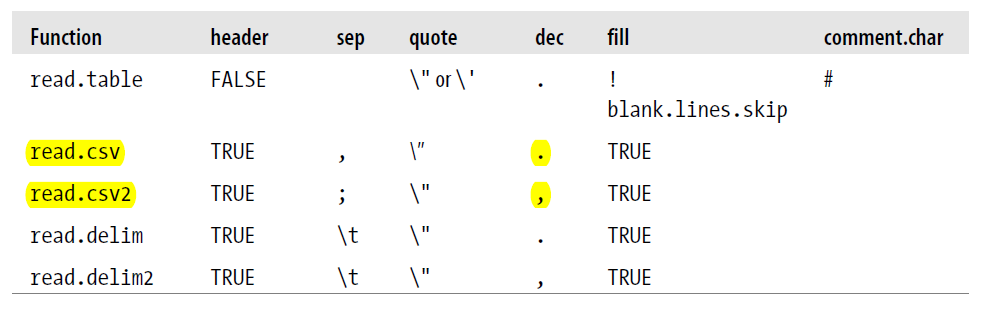

read.table options

Although not as common as white-space-, tab-, or comma-separated data, sometimes input data is stored with no delimiters between the values, but with each variable occupying the same columns on each line of input. In cases like this, the `read.fwf` function can be used. The `widths=` argument can be a vector containing the widths of the fields to be read, using negative numbers to indicate columns to be skipped. If the data for each observation occupies more than one line, `widths=` can be a list of as many vectors as there are lines per observation. The `header=`, `row.names=`, and `col.names=` arguments behave similarly to those in `read.table`.

```r
snowdata <- read.table("input/BostonWinterSnowfalls.csv", header = TRUE, sep = ",", quote = "\"")

# getting data online
sp500 <- read.csv("http://bit.ly/BostonSnowfallCSV", sep="")

# getting data with no delimiters
ff <- tempfile()
cat(file = ff, "New York, NY 66,834.6
    Kings, NY 34,722.9
    Bronx, NY 31,729.8
    Queens, NY 20,453.0
    San Francisco, CA 16,526.2
    Hudson, NJ 12,956.9
    Suffolk, MA 11,691.6
    Philadelphia, PA 11,241.1
    Washington, DC 9,378.0
    Alexandria IC, VA 8,552.2")
city <- read.fwf(ff, widths = c(18, -19, 8), as.is = TRUE)
city
```

```
##                    V1 V2
## 1  New York, NY 66,83 NA
## 2      Kings, NY 34,7 NA
## 3      Bronx, NY 31,7 NA
## 4      Queens, NY 20, NA
## 5      San Francisco, NA
## 6      Hudson, NJ 12, NA
## 7      Suffolk, MA 11 NA
## 8      Philadelphia,  NA
## 9      Washington, DC NA
## 10     Alexandria IC, NA
```

### 3.1.3 Exporting data

R can also export R data objects (usually data frames and matrices) as text files. To export data to a text file, use the `write.table` function.There are wrapper functions for `write.table` that call `write.table` with different defaults. These are useful if you want to create a file of comma-separated values.

```r
# write.table(snowdata, file = "output/snowdata.txt", quote = FALSE, sep = ",", row.names = FALSE)
# write.csv(snowdata, file = "output/snowdata.csv", row.names = FALSE)
```

### 3.1.4 Importing data from databases

In order to connect directly to a database from R, you will need to install some optional packages. The packages you need depend on the database(s) to which you want to connect and the connection method you want to use.

There are two sets of database interfaces available in R:

- **RODBC**. The RODBC package allows R to fetch data from ODBC (Open DataBase Connectivity) connections. ODBC provides a standard interface for different programs to connect to databases.
- **DBI**. The DBI package allows R to connect to databases using native database drivers or JDBC drivers. This package provides a common database abstraction for R software.

DBI is not a single package, but instead is a framework and set of packages for accessing databases.One important difference between the DBI packages and the RODBC package is in the objects they use: DBI uses S4 objects to represent drivers, connections, and other objects. To open a connection with DBI, use the dbConnect function. The argument drv can be a DBIDriver object or a character value describing the driver to use. You can generate a DBIDriver object with a call to the DBI driver. The dbConnect function can take additional options, depending on the type of database you are using. For SQLite databases, the most important argument is dbname (which specifies the database file). Check the help files for the database you are using for more options. Even arguments for parameters like usernames are not the same between databases.

As example we can easily copy an R data frame into a SQLite database with dbWriteTable().

```r
# to connect with an external database
# drv <- dbDriver("SQLite")
# con <- dbConnect(drv, dbname = system.file("extdata", "bb.db", package = "nutshell"))

# creating our database
mydb <- dbConnect(RSQLite::SQLite(), "")
dbWriteTable(mydb, "mtcars", mtcars)
dbWriteTable(mydb, "iris", iris)
dbListTables(mydb)
```

```
## [1] "iris"   "mtcars"
```

```r
# Issue a query with dbGetQuery()
dbGetQuery(mydb, 'SELECT * FROM mtcars LIMIT 5')
```

```
##    mpg cyl disp  hp drat    wt  qsec vs am gear carb
## 1 21.0   6  160 110 3.90 2.620 16.46  0  1    4    4
## 2 21.0   6  160 110 3.90 2.875 17.02  0  1    4    4
## 3 22.8   4  108  93 3.85 2.320 18.61  1  1    4    1
## 4 21.4   6  258 110 3.08 3.215 19.44  1  0    3    1
## 5 18.7   8  360 175 3.15 3.440 17.02  0  0    3    2
```

```r
# disconnecting from dabase
dbDisconnect(mydb)
```

## 3.2 Tidyverse

### 3.2.1 Reading data

El paquete readr, incluido en la familia tidyverse, admite la lectura de múltiples formatos de archivo usando funciones que comienzan por `read_*` o `write_*`. Por defecto, la función `read_excel()` importa la primera hoja. Para importar una hoja diferente es necesario indicarlo con el argumento sheet o bien el número o el nombre (segundo argumento). La función más importante para leer múltiples hojas es `map()` del paquete *purrr* que forma para de la colección de paquetes tidyverse. `map()` permite aplicar una función a cada elemento de un vector o lista. Existe una variante de `map()` que directamente nos une todas las tablas por fila: `map_df()`. Si fuese necesario unir por columna, se debería usar `map_dfc()`.

La función `dir_ls()` del paquete *fs* (https://github.com/r-lib/fs), a pesar de ser similar a `dir()` de R Base, tiene algunas ventajas, como su total compatibilidad con la colección de funciones de *tidyverse*. Por ejemplo, el argumento `regexp` permite buscar con una expresión regular un patrón en las rutas y ficheros.

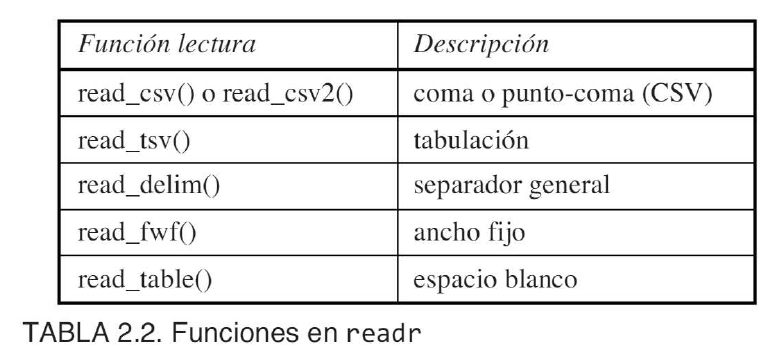

Funciones en readr

Most of us would probably read the CSV file first and then do the data cleaning. For example, using the `clean_names` function from the *janitor* package. The same can be achieved inside `read_csv` with the function `make_clean_names` for the `name_repair` argument. The function uses the snake naming convention by default. Snake converts all names to lowercase and separates words with an underscore. Besides that, `clean_names` does not work with vectors, but `make_clean_names` does.

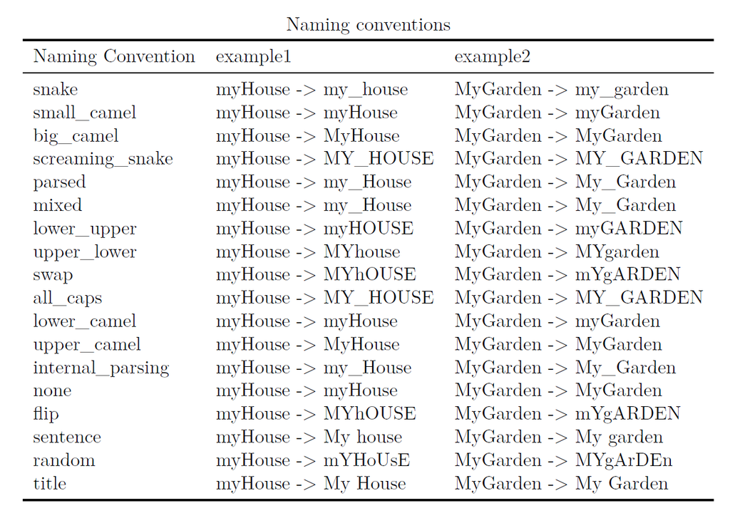

List of all naming conventions

With make_clean_names you can also replace certain characters from the column names. If you are familiar with regular expressions, you can make more complex replacements. Apart from cleaning your column names, you can also select columns directly from `read_csv` using the `col_select` argument.

```r
# janitor approach
mpg_new <- read_csv("input/mpg_uppercase.csv", show_col_types = FALSE) %>%
  janitor::clean_names() %>%
  select(c(manufacturer, model)) %>%
  glimpse()
```

```
## Rows: 6
## Columns: 2
## $ manufacturer <chr> "audi", "audi", "audi", "audi", "audi", "audi"
## $ model        <chr> "a4", "a4", "a4", "a4", "a4", "a4"
```

```r
# tidyverse approach
read_csv("input/mpg_uppercase.csv", name_repair = make_clean_names, show_col_types = FALSE) %>%
  glimpse()
```

```
## Rows: 6
## Columns: 11
## $ manufacturer <chr> "audi", "audi", "audi", "audi", "audi", "audi"
## $ model        <chr> "a4", "a4", "a4", "a4", "a4", "a4"
## $ displ        <dbl> 1.8, 1.8, 2.0, 2.0, 2.8, 2.8
## $ year         <dbl> 1999, 1999, 2008, 2008, 1999, 1999
## $ cyl          <dbl> 4, 4, 4, 4, 6, 6
## $ trans        <chr> "auto(l5)", "manual(m5)", "manual(m6)", "auto(av)", "auto…
## $ drv          <lgl> FALSE, FALSE, FALSE, FALSE, FALSE, FALSE
## $ cty          <dbl> 18, 21, 20, 21, 16, 18
## $ hwy          <dbl> 29, 29, 31, 30, 26, 26
## $ fl           <chr> "p", "p", "p", "p", "p", "p"
## $ class        <chr> "compact", "compact", "compact", "compact", "compact", "c…
```

```r
# replacing and removing character strings with make_clean_names
make_clean_names(c("A", "B%", "C"), replace = c("%" = "_percent"))
```

```
## [1] "a"         "b_percent" "c"
```

```r
# with reg expressions
make_clean_names(c("A_1", "B_1", "C_1"), replace = c("^A_" = "a"))
```

```
## [1] "a1"  "b_1" "c_1"
```

```r
# snake naming convention per default
make_clean_names(c("myHouse", "MyGarden"), case = "snake")
```

```
## [1] "my_house"  "my_garden"
```

```r
make_clean_names(c("myHouse", "MyGarden"), case = "none")
```

```
## [1] "myHouse"  "MyGarden"
```

```r
read_csv("input/mpg_uppercase.csv", show_col_types = FALSE, name_repair = ~ make_clean_names(., case = "upper_camel")) %>% # The dot . in make_clean_names denotes the vector of column names.
  glimpse()
```

```
## Rows: 6
## Columns: 11
## $ Manufacturer <chr> "audi", "audi", "audi", "audi", "audi", "audi"
## $ Model        <chr> "a4", "a4", "a4", "a4", "a4", "a4"
## $ Displ        <dbl> 1.8, 1.8, 2.0, 2.0, 2.8, 2.8
## $ Year         <dbl> 1999, 1999, 2008, 2008, 1999, 1999
## $ Cyl          <dbl> 4, 4, 4, 4, 6, 6
## $ Trans        <chr> "auto(l5)", "manual(m5)", "manual(m6)", "auto(av)", "auto…
## $ Drv          <lgl> FALSE, FALSE, FALSE, FALSE, FALSE, FALSE
## $ Cty          <dbl> 18, 21, 20, 21, 16, 18
## $ Hwy          <dbl> 29, 29, 31, 30, 26, 26
## $ Fl           <chr> "p", "p", "p", "p", "p", "p"
## $ Class        <chr> "compact", "compact", "compact", "compact", "compact", "c…
```

```r
# selecting specific columns
read_csv("input/mpg_uppercase.csv", show_col_types = FALSE, name_repair = make_clean_names, col_select = c(manufacturer, model)) %>%
  glimpse()
```

```
## Rows: 6
## Columns: 2
## $ manufacturer <chr> "audi", "audi", "audi", "audi", "audi", "audi"
## $ model        <chr> "a4", "a4", "a4", "a4", "a4", "a4"
```

Column names often contain spaces, special characters, or are written in a mixture of lower and upper case characters. Such poorly formatted column names can lead to numerous problems. We could easily solve these issues with the `rename` function but this approach does not scale. The main difference between remain and `remain_with` is that remain_with changes the column names using a function. The three main arguments of the function are `.data`, `.fn` and `.cols`. `.data` stands for the data frame, `.fn` for the function to apply to the column names, and .`cols` for the columns to apply the function to.

Use a specific naming convention for column names using the `make_clean_names` function from the *janitor* package. It is used the tilde operator to indicate an anonymous function. This shortcut is needed whenever you need to call certain arguments of a function.

Another use case of `rename_with` is the replacement of characters. We use the `gsub` function to replace a specific character. Alternatively, we could have used the `str_replace` function. With `pattern` we said that we are looking for a group of characters containing one or more digits (\d+). \d+ is a regular expression. A group in the `argument` pattern is everything between two brackets. With `replacement` we said that we want to put an underscore in front of this group. The group itself is specified by \1. If we had two groups, the second group would be specified by \2.

You can use `.cols` to specify which column names to apply the function to. And you can even use our *tidyselect* functions for that. Another useful function is `matches.` With `matches`, you can search for specific patterns in your column names and apply a function to the column names that match the pattern.

```r
mpg %>%
  rename_with(
    .fn = toupper,
    .cols = everything()
  )
```

```
## # A tibble: 234 × 11
##    MANUFACTURER MODEL      DISPL  YEAR   CYL TRANS DRV     CTY   HWY FL    CLASS
##    <chr>        <chr>      <dbl> <int> <int> <chr> <chr> <int> <int> <chr> <chr>
##  1 audi         a4           1.8  1999     4 auto… f        18    29 p     comp…
##  2 audi         a4           1.8  1999     4 manu… f        21    29 p     comp…
##  3 audi         a4           2    2008     4 manu… f        20    31 p     comp…
##  4 audi         a4           2    2008     4 auto… f        21    30 p     comp…
##  5 audi         a4           2.8  1999     6 auto… f        16    26 p     comp…
##  6 audi         a4           2.8  1999     6 manu… f        18    26 p     comp…
##  7 audi         a4           3.1  2008     6 auto… f        18    27 p     comp…
##  8 audi         a4 quattro   1.8  1999     4 manu… 4        18    26 p     comp…
##  9 audi         a4 quattro   1.8  1999     4 auto… 4        16    25 p     comp…
## 10 audi         a4 quattro   2    2008     4 manu… 4        20    28 p     comp…
## # … with 224 more rows
## # ℹ Use `print(n = ...)` to see more rows
```

```r
# the same as
mpg %>%
  rename_with(
    .fn = toupper,
    .cols = everything()
  ) %>%
  colnames()
```

```
##  [1] "MANUFACTURER" "MODEL"        "DISPL"        "YEAR"         "CYL"
##  [6] "TRANS"        "DRV"          "CTY"          "HWY"          "FL"
## [11] "CLASS"
```

```r
# using janitor to build a specific name convention
iris %>%
  rename_with(~ janitor::make_clean_names(., case = "big_camel")) %>%
  colnames()
```

```
## [1] "SepalLength" "SepalWidth"  "PetalLength" "PetalWidth"  "Species"
```

```r
# replacing characters
mpg %>%
  rename_with(~ gsub("e", "_", .)) %>%
  colnames()
```

```
##  [1] "manufactur_r" "mod_l"        "displ"        "y_ar"         "cyl"
##  [6] "trans"        "drv"          "cty"          "hwy"          "fl"
## [11] "class"
```

```r
# or
mpg %>%
  rename_with(~ str_replace(., "e", "_")) %>%
  colnames()
```

```
##  [1] "manufactur_r" "mod_l"        "displ"        "y_ar"         "cyl"
##  [6] "trans"        "drv"          "cty"          "hwy"          "fl"
## [11] "class"
```

```r
# replacing characters using grouping function
anscombe %>%
  rename_with(~ str_replace(.,
    pattern = "(\\d+)",
    replacement = "_\\1"
  )) %>%
  colnames()
```

```
## [1] "x_1" "x_2" "x_3" "x_4" "y_1" "y_2" "y_3" "y_4"
```

```r
# renaming variables for specific variables
anscombe %>%
  rename_with(~ str_replace(
    ., "([:alpha:])([1-2])",
    "\\1psilon\\2_"
  ), c(y1, y2)) %>%
  colnames()
```

```
## [1] "x1"        "x2"        "x3"        "x4"        "ypsilon1_" "ypsilon2_"
## [7] "y3"        "y4"
```

```r
# using tidyverse functions
mpg %>%
  rename_with(~ toupper(.), where(is.numeric)) %>%
  colnames()
```

```
##  [1] "manufacturer" "model"        "DISPL"        "YEAR"         "CYL"
##  [6] "trans"        "drv"          "CTY"          "HWY"          "fl"
## [11] "class"
```

```r
iris %>%
  rename_with(
    ~ str_replace(., "\\.", "_"),
    starts_with("Sepal")
  ) %>%
  colnames()
```

```
## [1] "Sepal_Length" "Sepal_Width"  "Petal.Length" "Petal.Width"  "Species"
```

```r
# using matches
iris %>%
  rename_with(
    ~ str_replace(., "\\.", "_"),
    matches("[Ww]idth$")
  ) %>%
  colnames()
```

```
## [1] "Sepal.Length" "Sepal_Width"  "Petal.Length" "Petal_Width"  "Species"
```

You don”t always read just one file into R. It is not uncommon for your data to be scattered in hundreds or thousands of files. Of course, you don”t want to read these files into R manually. So you need an automatic method for reading in files. Before we can read the files into R, we need to create a character vector of the file paths. You have several options to create such a vector. You can use the R base function `list.files`, which returns character vectors of the names of files in a directory or you use the function `dir_ls` from the *fs* package. The other option is to use the `dir_ls` function from the *fs* package. *fs* provides a cross-platform interface for accessing files on your hard disk. It supports all file operations (deleting, creating files, moving files, etc.).

Now that we know the file paths, we can load the files into R. The tidyverse way to do this is to use the `map_dfr` function from the *purrr* package. `map_dfr` loops through all the file paths and binds the data frames into a single data frame. The `.x` in the following code stands for the file name. To output the actual csv files and not the filenames, we need to put `.x` (the path) in a `read_*` function. In this example we are working with CSV files. The trick works the same for all rectangular file formats. Another approach is to use the `read_csv` function directly by putting the character vector of the file names directly into `read_csv`.

Sometimes your files are deeply nested. In that case, we need to search through each folder recursively. If you try to load all csv files from the nested_folders folder, you would get an empty vector. This is because `dir_ls` does not look in the nested folders, but only in the parent folder. To make `dir_ls` search through the folders recursively, you need to set the `recurse` argument to `TRUE`.

You don”t always need all the files in your directory and need to remove some files from the list of file paths. A good way to do this is to use the `str_detect` function from the *stringr* package. The function returns logical values. To change the actual character vector, we need to add these logical values to the character vector itself. With the `negate` argument you can find only the files that do not match the pattern.

```r
horas_sol <- read_csv("input/SS_STAID001395.txt", skip = 19) |> # los datos empiezan en la linea 20
  janitor::clean_names()
head(horas_sol)
```

```
## # A tibble: 6 × 4
##    souid     date    ss  q_ss
##    <dbl>    <dbl> <dbl> <dbl>
## 1 120414 19560501 -9999     9
## 2 120414 19560502 -9999     9
## 3 120414 19560503 -9999     9
## 4 120414 19560504 -9999     9
## 5 120414 19560505 -9999     9
## 6 120414 19560506 -9999     9
```

```r
# .xlsx files
# importing .xls file
emisiones <- readxl::read_xls("input/env_air_gge.xls", sheet = 1, skip = 362, n_max = 36)
head(emisiones)
```

```
## # A tibble: 6 × 11
##   GEO/TI…¹ `2007` `2008` `2009` `2010` `2011` `2012` `2013` `2014` `2015` `2016`
##   <chr>     <dbl>  <dbl>  <dbl>  <dbl>  <dbl>  <dbl>  <dbl>  <dbl>  <dbl>  <dbl>
## 1 Europea… 4.33e5 4.30e5 4.25e5 4.20e5 4.20e5 4.18e5 4.21e5 4.28e5 4.30e5 4.30e5
## 2 Europea… 4.34e5 4.31e5 4.26e5 4.21e5 4.21e5 4.19e5 4.22e5 4.29e5 4.30e5 4.31e5
## 3 Belgium  1.03e4 1.02e4 1.03e4 1.02e4 1.01e4 9.92e3 9.96e3 1.02e4 1.01e4 9.90e3
## 4 Bulgaria 4.90e3 5.15e3 4.98e3 5.45e3 5.11e3 5.24e3 5.72e3 6.19e3 6.24e3 6.53e3
## 5 Czech R… 7.84e3 7.99e3 7.58e3 7.41e3 7.59e3 7.58e3 7.76e3 7.96e3 8.16e3 8.52e3
## 6 Denmark  1.08e4 1.07e4 1.05e4 1.04e4 1.04e4 1.04e4 1.03e4 1.05e4 1.04e4 1.05e4
## # … with abbreviated variable name ¹`GEO/TIME`
```

```r
# iterate over multiple worksheets in a workbook
path <- "input/madrid_temp.xlsx"
mad <- path %>%
  readxl::excel_sheets() %>%
  set_names() %>%
  map_df(readxl::read_excel,
    path = path, .id = "yr"
  )
head(mad)
```

```
## # A tibble: 6 × 3
##   yr    date                   ta
##   <chr> <dttm>              <dbl>
## 1 2000  2000-01-01 00:00:00   5.4
## 2 2000  2000-01-02 00:00:00   5
## 3 2000  2000-01-03 00:00:00   3.5
## 4 2000  2000-01-04 00:00:00   4.3
## 5 2000  2000-01-05 00:00:00   0.6
## 6 2000  2000-01-06 00:00:00   3.8
```

```r
# importing and reading several .xlsx files at once without merging
dir_ls("input", regexp = "xlsx") %>%
  map(readxl::read_excel)
```

```
## $`input/berlin_temp.xlsx`
## # A tibble: 366 × 2
##    date                   ta
##    <dttm>              <dbl>
##  1 2000-01-01 00:00:00   1.2
##  2 2000-01-02 00:00:00   3.6
##  3 2000-01-03 00:00:00   5.7
##  4 2000-01-04 00:00:00   5.1
##  5 2000-01-05 00:00:00   2.2
##  6 2000-01-06 00:00:00   1.8
##  7 2000-01-07 00:00:00   4.2
##  8 2000-01-08 00:00:00   4.2
##  9 2000-01-09 00:00:00   4.2
## 10 2000-01-10 00:00:00   1.7
## # … with 356 more rows
## # ℹ Use `print(n = ...)` to see more rows
##
## $`input/madrid_temp.xlsx`
## # A tibble: 366 × 2
##    date                   ta
##    <dttm>              <dbl>
##  1 2000-01-01 00:00:00   5.4
##  2 2000-01-02 00:00:00   5
##  3 2000-01-03 00:00:00   3.5
##  4 2000-01-04 00:00:00   4.3
##  5 2000-01-05 00:00:00   0.6
##  6 2000-01-06 00:00:00   3.8
##  7 2000-01-07 00:00:00   6.2
##  8 2000-01-08 00:00:00   5.4
##  9 2000-01-09 00:00:00   5.5
## 10 2000-01-10 00:00:00   4.8
## # … with 356 more rows
## # ℹ Use `print(n = ...)` to see more rows
```

```r
# merging into a new column
data_df <- dir_ls("input", regexp = "xlsx") %>%
  map_df(readxl::read_excel, .id = "city")
# cleaning city column
data_df <- mutate(data_df, city = path_file(city) %>%
                    path_ext_remove() %>%
                    str_replace("_temp", ""))
head(data_df)
```

```
## # A tibble: 6 × 3
##   city   date                   ta
##   <chr>  <dttm>              <dbl>
## 1 berlin 2000-01-01 00:00:00   1.2
## 2 berlin 2000-01-02 00:00:00   3.6
## 3 berlin 2000-01-03 00:00:00   5.7
## 4 berlin 2000-01-04 00:00:00   5.1
## 5 berlin 2000-01-05 00:00:00   2.2
## 6 berlin 2000-01-06 00:00:00   1.8
```

```r
# .csv files
# adding new directory
# dir_create("input", c("many_files"))

# creating random samples from mpg data set
# mpg_samples <- map(1:25, ~ slice_sample(mpg, n = 20))

# adding .csv files from samples to the new directory
# iwalk(mpg_samples, ~ write_csv(., paste0("input/many_files/", .y, ".csv")))

# creating a character vector of file paths
# with list.files from Base-R
(csv_files_list_files <- list.files(path = "input/many_files", pattern = "csv", full.names = TRUE))
```

```
##  [1] "input/many_files/1.csv"  "input/many_files/10.csv"
##  [3] "input/many_files/11.csv" "input/many_files/12.csv"
##  [5] "input/many_files/13.csv" "input/many_files/14.csv"
##  [7] "input/many_files/15.csv" "input/many_files/16.csv"
##  [9] "input/many_files/17.csv" "input/many_files/18.csv"
## [11] "input/many_files/19.csv" "input/many_files/2.csv"
## [13] "input/many_files/20.csv" "input/many_files/21.csv"
## [15] "input/many_files/22.csv" "input/many_files/23.csv"
## [17] "input/many_files/24.csv" "input/many_files/25.csv"
## [19] "input/many_files/3.csv"  "input/many_files/4.csv"
## [21] "input/many_files/5.csv"  "input/many_files/6.csv"
## [23] "input/many_files/7.csv"  "input/many_files/8.csv"
## [25] "input/many_files/9.csv"
```

```r
# with dir_ls from fs package
(csv_files_dir_ls <- dir_ls(path = "input/many_files/", glob = "*.csv", type = "file"))
```

```
## input/many_files/1.csv  input/many_files/10.csv input/many_files/11.csv
## input/many_files/12.csv input/many_files/13.csv input/many_files/14.csv
## input/many_files/15.csv input/many_files/16.csv input/many_files/17.csv
## input/many_files/18.csv input/many_files/19.csv input/many_files/2.csv
## input/many_files/20.csv input/many_files/21.csv input/many_files/22.csv
## input/many_files/23.csv input/many_files/24.csv input/many_files/25.csv
## input/many_files/3.csv  input/many_files/4.csv  input/many_files/5.csv
## input/many_files/6.csv  input/many_files/7.csv  input/many_files/8.csv
## input/many_files/9.csv
```

```r
# reading the files from a character vector of paths
data_frames <- map_dfr(csv_files_dir_ls, ~ read_csv(.x, show_col_types = FALSE))
glimpse(data_frames)
```

```
## Rows: 500
## Columns: 11
## $ manufacturer <chr> "volkswagen", "chevrolet", "volkswagen", "audi", "ford", …
## $ model        <chr> "jetta", "malibu", "jetta", "a4", "explorer 4wd", "camry …
## $ displ        <dbl> 2.0, 2.4, 2.0, 2.0, 4.0, 2.4, 5.7, 2.2, 2.8, 2.8, 1.8, 4.…
## $ year         <dbl> 1999, 2008, 2008, 2008, 1999, 2008, 2008, 1999, 1999, 199…
## $ cyl          <dbl> 4, 4, 4, 4, 6, 4, 8, 4, 6, 6, 4, 8, 6, 8, 6, 6, 8, 6, 8, …
## $ trans        <chr> "auto(l4)", "auto(l4)", "auto(s6)", "auto(av)", "manual(m…
## $ drv          <chr> "f", "f", "f", "f", "4", "f", "4", "4", "4", "f", "f", "4…
## $ cty          <dbl> 19, 22, 22, 21, 15, 22, 13, 21, 17, 18, 26, 13, 16, 13, 1…
## $ hwy          <dbl> 26, 30, 29, 30, 19, 31, 18, 26, 25, 26, 35, 19, 24, 17, 2…
## $ fl           <chr> "r", "r", "p", "p", "r", "r", "r", "r", "p", "p", "r", "r…
## $ class        <chr> "compact", "midsize", "compact", "compact", "suv", "compa…
```

```r
# and with a new column representing the file name
map_dfr(csv_files_dir_ls, ~ read_csv(.x, , show_col_types = FALSE) %>%
  mutate(filename = .x)) %>%
  glimpse()
```

```
## Rows: 500
## Columns: 12
## $ manufacturer <chr> "volkswagen", "chevrolet", "volkswagen", "audi", "ford", …
## $ model        <chr> "jetta", "malibu", "jetta", "a4", "explorer 4wd", "camry …
## $ displ        <dbl> 2.0, 2.4, 2.0, 2.0, 4.0, 2.4, 5.7, 2.2, 2.8, 2.8, 1.8, 4.…
## $ year         <dbl> 1999, 2008, 2008, 2008, 1999, 2008, 2008, 1999, 1999, 199…
## $ cyl          <dbl> 4, 4, 4, 4, 6, 4, 8, 4, 6, 6, 4, 8, 6, 8, 6, 6, 8, 6, 8, …
## $ trans        <chr> "auto(l4)", "auto(l4)", "auto(s6)", "auto(av)", "manual(m…
## $ drv          <chr> "f", "f", "f", "f", "4", "f", "4", "4", "4", "f", "f", "4…
## $ cty          <dbl> 19, 22, 22, 21, 15, 22, 13, 21, 17, 18, 26, 13, 16, 13, 1…
## $ hwy          <dbl> 26, 30, 29, 30, 19, 31, 18, 26, 25, 26, 35, 19, 24, 17, 2…
## $ fl           <chr> "r", "r", "p", "p", "r", "r", "r", "r", "p", "p", "r", "r…
## $ class        <chr> "compact", "midsize", "compact", "compact", "suv", "compa…
## $ filename     <fs::path> "input/many_files/1.csv", "input/many_files/1.csv", …
```

```r
# using directly read_csv
read_csv(csv_files_dir_ls, id = "filename", show_col_types = FALSE) %>%
  glimpse
```

```
## Rows: 500
## Columns: 12
## $ filename     <chr> "input/many_files/1.csv", "input/many_files/1.csv", "inpu…
## $ manufacturer <chr> "volkswagen", "chevrolet", "volkswagen", "audi", "ford", …
## $ model        <chr> "jetta", "malibu", "jetta", "a4", "explorer 4wd", "camry …
## $ displ        <dbl> 2.0, 2.4, 2.0, 2.0, 4.0, 2.4, 5.7, 2.2, 2.8, 2.8, 1.8, 4.…
## $ year         <dbl> 1999, 2008, 2008, 2008, 1999, 2008, 2008, 1999, 1999, 199…
## $ cyl          <dbl> 4, 4, 4, 4, 6, 4, 8, 4, 6, 6, 4, 8, 6, 8, 6, 6, 8, 6, 8, …
## $ trans        <chr> "auto(l4)", "auto(l4)", "auto(s6)", "auto(av)", "manual(m…
## $ drv          <chr> "f", "f", "f", "f", "4", "f", "4", "4", "4", "f", "f", "4…
## $ cty          <dbl> 19, 22, 22, 21, 15, 22, 13, 21, 17, 18, 26, 13, 16, 13, 1…
## $ hwy          <dbl> 26, 30, 29, 30, 19, 31, 18, 26, 25, 26, 35, 19, 24, 17, 2…
## $ fl           <chr> "r", "r", "p", "p", "r", "r", "r", "r", "p", "p", "r", "r…
## $ class        <chr> "compact", "midsize", "compact", "compact", "suv", "compa…
```

```r
# inconsistent column names
# generating the samples with inconsistent column names
mpg_samples2 <- map(1:10, ~ slice_sample(mpg, n = 20))
inconsistent_dframes <- map(mpg_samples2, ~ janitor::clean_names(dat = .x, case = "random"))
map(inconsistent_dframes, ~ colnames(.x)) %>%
  head
```

```
## [[1]]
##  [1] "MaNUFaCtUReR" "ModeL"        "dIspl"        "yEaR"         "CYl"
##  [6] "trANs"        "dRv"          "CtY"          "hWY"          "Fl"
## [11] "cLaSS"
##
## [[2]]
##  [1] "maNuFAcTUREr" "MOdEl"        "DIspl"        "yEAr"         "cYl"
##  [6] "TRans"        "drv"          "CTy"          "hwY"          "Fl"
## [11] "CLAsS"
##
## [[3]]
##  [1] "ManUFActurer" "mOdEL"        "dISPL"        "YeaR"         "cyl"
##  [6] "tRanS"        "DRv"          "CTY"          "hwY"          "Fl"
## [11] "ClaSS"
##
## [[4]]
##  [1] "manufaCturER" "MOdel"        "dIspL"        "YEaR"         "cYl"
##  [6] "trANS"        "dRv"          "cTy"          "Hwy"          "Fl"
## [11] "CLass"
##
## [[5]]
##  [1] "ManufacTurer" "ModEL"        "diSPL"        "yEAR"         "CYl"
##  [6] "TrAnS"        "drV"          "CTy"          "hWy"          "FL"
## [11] "ClASs"
##
## [[6]]
##  [1] "manufActUreR" "model"        "DIspL"        "YEAR"         "Cyl"
##  [6] "TrAns"        "DRV"          "CTy"          "Hwy"          "fL"
## [11] "ClASS"
```

```r
# selecting a random set of columns per data frame
inconsistent_dframes <- map(inconsistent_dframes, ~ .x[sample(1:length(.x), sample(1:length(.x), 1))])
map(inconsistent_dframes, ~ colnames(.x)) %>%
  head()
```

```
## [[1]]
## [1] "dIspl"
##
## [[2]]
## [1] "hwY"
##
## [[3]]
## [1] "YeaR"  "mOdEL" "tRanS" "DRv"   "CTY"   "ClaSS" "hwY"
##
## [[4]]
## [1] "dRv"          "MOdel"        "manufaCturER" "YEaR"         "CLass"
##
## [[5]]
## [1] "CYl"          "drV"          "ClASs"        "CTy"          "hWy"
## [6] "FL"           "ManufacTurer"
##
## [[6]]
## [1] "fL"    "CTy"   "ClASS" "DRV"   "model" "TrAns"
```

```r
# saving to disk
# dir_create(c("input/unclean_files"))
# iwalk(inconsistent_dframes, ~ write_csv(.x, paste0("input/unclean_files/", .y, ".csv")))

# loading and cleaning the data frames
many_columns_data_frame <- dir_ls(path = "input/unclean_files/", glob = "*.csv", type = "file") %>%
  map_dfr(~ read_csv(.x, name_repair = tolower, show_col_types = FALSE) %>%
            mutate(filename = .x))

# showing results
many_columns_data_frame %>%
  glimpse()
```

```
## Rows: 200
## Columns: 12
## $ trans        <chr> "manual(m5)", "manual(m5)", "manual(m6)", "auto(l5)", "ma…
## $ model        <chr> "impreza awd", "tiburon", "a4 quattro", "a4", "ram 1500 p…
## $ year         <dbl> 1999, 2008, 2008, 1999, 2008, 1999, 2008, 1999, 1999, 200…
## $ fl           <chr> "r", "r", "p", "p", "e", "r", "r", "r", "r", "r", "r", "p…
## $ displ        <dbl> 2.2, 2.0, 2.0, 2.8, 4.7, 3.8, 2.5, 3.8, 1.6, 4.2, 2.2, 1.…
## $ class        <chr> "subcompact", "subcompact", "compact", "compact", "pickup…
## $ cyl          <dbl> 4, 4, 4, 6, 8, 6, 5, 6, 4, 8, 4, 4, 8, 4, 6, 8, 5, 8, 4, …
## $ filename     <fs::path> "input/unclean_files/1.csv", "input/unclean_files/1.…
## $ drv          <chr> NA, NA, NA, NA, NA, NA, NA, NA, NA, NA, NA, NA, NA, NA, N…
## $ hwy          <dbl> NA, NA, NA, NA, NA, NA, NA, NA, NA, NA, NA, NA, NA, NA, N…
## $ cty          <dbl> NA, NA, NA, NA, NA, NA, NA, NA, NA, NA, NA, NA, NA, NA, N…
## $ manufacturer <chr> NA, NA, NA, NA, NA, NA, NA, NA, NA, NA, NA, NA, NA, NA, N…
```

```r
# files not in the same folder
mpg_samples3 <- map(1:40, ~ slice_sample(mpg, n = 20))

# Create directories
# dir_create(c("input/nested_folders", "input/nested_folders/first_nested_folder", "input/nested_folders/second_nested_folder"))

# First folder
# iwalk(mpg_samples[1:20], ~ write_csv(.x, paste0("input/nested_folders/first_nested_folder/", .y, "_first.csv")))

# Second folder
# iwalk(mpg_samples[21:40], ~ write_csv(.x, paste0("input/nested_folders/second_nested_folder/", .y, "_second.csv")))

# searching through nested folders recursively
(csv_files_nested <- dir_ls("input/nested_folders/", glob = "*.csv", type = "file", recurse = TRUE))
```

```
## input/nested_folders/first_nested_folder/10_first.csv
## input/nested_folders/first_nested_folder/11_first.csv
## input/nested_folders/first_nested_folder/12_first.csv
## input/nested_folders/first_nested_folder/13_first.csv
## input/nested_folders/first_nested_folder/14_first.csv
## input/nested_folders/first_nested_folder/15_first.csv
## input/nested_folders/first_nested_folder/16_first.csv
## input/nested_folders/first_nested_folder/17_first.csv
## input/nested_folders/first_nested_folder/18_first.csv
## input/nested_folders/first_nested_folder/19_first.csv
## input/nested_folders/first_nested_folder/1_first.csv
## input/nested_folders/first_nested_folder/20_first.csv
## input/nested_folders/first_nested_folder/2_first.csv
## input/nested_folders/first_nested_folder/3_first.csv
## input/nested_folders/first_nested_folder/4_first.csv
## input/nested_folders/first_nested_folder/5_first.csv
## input/nested_folders/first_nested_folder/6_first.csv
## input/nested_folders/first_nested_folder/7_first.csv
## input/nested_folders/first_nested_folder/8_first.csv
## input/nested_folders/first_nested_folder/9_first.csv
## input/nested_folders/second_nested_folder/10_second.csv
## input/nested_folders/second_nested_folder/11_second.csv
## input/nested_folders/second_nested_folder/12_second.csv
## input/nested_folders/second_nested_folder/13_second.csv
## input/nested_folders/second_nested_folder/14_second.csv
## input/nested_folders/second_nested_folder/15_second.csv
## input/nested_folders/second_nested_folder/16_second.csv
## input/nested_folders/second_nested_folder/17_second.csv
## input/nested_folders/second_nested_folder/18_second.csv
## input/nested_folders/second_nested_folder/19_second.csv
## input/nested_folders/second_nested_folder/1_second.csv
## input/nested_folders/second_nested_folder/20_second.csv
## input/nested_folders/second_nested_folder/2_second.csv
## input/nested_folders/second_nested_folder/3_second.csv
## input/nested_folders/second_nested_folder/4_second.csv
## input/nested_folders/second_nested_folder/5_second.csv
## input/nested_folders/second_nested_folder/6_second.csv
## input/nested_folders/second_nested_folder/7_second.csv
## input/nested_folders/second_nested_folder/8_second.csv
## input/nested_folders/second_nested_folder/9_second.csv
```

```r
map_dfr(csv_files_nested, ~ read_csv(.x, show_col_types = FALSE) %>%
          mutate(filename = .x)) %>%
  glimpse()
```

```
## Rows: 800
## Columns: 12
## $ manufacturer <chr> "toyota", "jeep", "honda", "volkswagen", "toyota", "subar…
## $ model        <chr> "camry", "grand cherokee 4wd", "civic", "new beetle", "co…
## $ displ        <dbl> 2.4, 4.7, 1.6, 2.5, 1.8, 2.5, 2.0, 5.7, 4.0, 5.9, 4.0, 2.…
## $ year         <dbl> 2008, 2008, 1999, 2008, 1999, 2008, 1999, 1999, 1999, 199…
## $ cyl          <dbl> 4, 8, 4, 5, 4, 4, 4, 8, 6, 8, 6, 4, 8, 8, 8, 4, 8, 6, 4, …
## $ trans        <chr> "manual(m5)", "auto(l5)", "manual(m5)", "manual(m5)", "ma…
## $ drv          <chr> "f", "4", "f", "f", "f", "4", "f", "r", "4", "4", "f", "4…
## $ cty          <dbl> 21, 9, 23, 20, 26, 20, 19, 13, 14, 11, 16, 20, 11, 12, 9,…
## $ hwy          <dbl> 31, 12, 29, 28, 35, 27, 26, 17, 17, 15, 23, 27, 15, 16, 1…
## $ fl           <chr> "r", "e", "p", "r", "r", "r", "r", "r", "r", "r", "r", "r…
## $ class        <chr> "midsize", "suv", "subcompact", "subcompact", "compact", …
## $ filename     <fs::path> "input/nested_folders/first_nested_folder/10_first.c…
```

```r
# selecting the files to import from a string pattern
csv_files_nested[str_detect(csv_files_nested, pattern = "[2-4]_first|second\\.csv$", negate = TRUE)] %>%
  map_dfr(~ read_csv(.x, show_col_types = FALSE) %>%
            mutate(filename = .x)) %>%
  glimpse()
```

```
## Rows: 280
## Columns: 12
## $ manufacturer <chr> "toyota", "jeep", "honda", "volkswagen", "toyota", "subar…
## $ model        <chr> "camry", "grand cherokee 4wd", "civic", "new beetle", "co…
## $ displ        <dbl> 2.4, 4.7, 1.6, 2.5, 1.8, 2.5, 2.0, 5.7, 4.0, 5.9, 4.0, 2.…
## $ year         <dbl> 2008, 2008, 1999, 2008, 1999, 2008, 1999, 1999, 1999, 199…
## $ cyl          <dbl> 4, 8, 4, 5, 4, 4, 4, 8, 6, 8, 6, 4, 8, 8, 8, 4, 8, 6, 4, …
## $ trans        <chr> "manual(m5)", "auto(l5)", "manual(m5)", "manual(m5)", "ma…
## $ drv          <chr> "f", "4", "f", "f", "f", "4", "f", "r", "4", "4", "f", "4…
## $ cty          <dbl> 21, 9, 23, 20, 26, 20, 19, 13, 14, 11, 16, 20, 11, 12, 9,…
## $ hwy          <dbl> 31, 12, 29, 28, 35, 27, 26, 17, 17, 15, 23, 27, 15, 16, 1…
## $ fl           <chr> "r", "e", "p", "r", "r", "r", "r", "r", "r", "r", "r", "r…
## $ class        <chr> "midsize", "suv", "subcompact", "subcompact", "compact", …
## $ filename     <fs::path> "input/nested_folders/first_nested_folder/10_first.c…
```

### 3.2.2 Writing data

The `write_csv` function writes tabular data to an ASCII file in CSV format. Each row of data creates one line in the file, with data items separated by commas (,).

```r
# write_csv(horas_sol, "output/horas_sol.csv")
```

## 3.3 Packages

### 3.3.1 The magic of rio

“The aim of **rio** is to make data file I/O [import/output] in R as easy as possible by implementing three simple functions in Swiss-army knife style,” according to the project’s GitHub page. Those functions are `import()`, `export()`, and `convert()`. So, the rio package has just one function to read in many different types of files: `import()`. Once you’ve analyzed your data, if you want to save the results as a CSV, Excel spreadsheet, or other format, rio’s `export()` function can handle that. You can use R’s `download.file` function with the syntax `download.file("url", "destinationFileName.csv")` to download files directly from the web. It’s possible rio will ask you to re-download the file in binary format, in which case you’ll need to run `download.file(“http://bit.ly/BostonSnowfallCSV”, “BostonWinterSnowfalls.csv”, mode=‘wb"`).

```r
# getting data from the web with R-built-in
download.file("http://bit.ly/BostonSnowfallCSV", "input/BostonWinterSnowfalls.csv")
# download.file(“http://bit.ly/BostonSnowfallCSV”, “BostonWinterSnowfalls.csv”, mode=‘wb")

# import data with rio locally
snowdata2 <- rio::import("input/BostonWinterSnowfalls.csv")
suicides <- rio::import("input/PDT-suicidesData.csv")
# rio::import("mySpreadsheet.xlsx", which = 2, col_names = c("City", "State", "Population"))
```

#### 3.3.1.1 Import a file from the Web

If you want to download and import a file from the Web, you can do so if it’s publicly available and in a format such as Excel or CSV you can use `rio`. A lot of systems will be able to follow the redirect URL to the file even after first giving you an error message, as long as you specify the format as “csv” since the file name here doesn’t include “.csv”. rio can also import well-formatted HTML tables from Web pages, but the tables have to be extremely well-formatted. In real life, though, Web data rarely appears in such neat, isolated form. A good option for cases that aren’t quite as well crafted is often the **htmltab** package. Since it wasn’t specified which table, it pulled the first HTML table on the page. To download a specific table use the `which` argument.

The most popular way to install packages from GitHub is to use a package called **devtools**. devtools is an extremely powerful package designed mostly for people who want to write their own packages, and it includes a few ways to install packages from other places besides CRAN. However, devtools usually requires a couple of extra steps to install compared to a typical package. However, the **pacman** package will also install packages from non-CRAN sources like GitHub. You can use the `number_with_commas()` function to change those character strings that should be numbers back into numbers. The **rmiscutils** package isn’t the only way to deal with imported numbers that have commas, the tidyverse readr package also includes a function that turns character strings into numbers, `parse_number()`. One advantage of `readr::parse_number()` is that you can define your own `locale()` to control things like encoding and decimal marks. There’s an R package called **janitor** that can automatically fix troublesome column names imported from a non-R-friendly data source. You can create new clean column names using janitor’s `clean_names()` function.

```r
# getting data from the web with rio
snowdata3 <- rio::import("http://bit.ly/BostonSnowfallCSV", format = "csv")

# getting html tables
design.tokens1 <- rio::import("https://designsystem.digital.gov/design-tokens/", format = "html")
citytable <- htmltab("https://en.wikipedia.org/wiki/List_of_United_States_cities_by_population", which = 5)
design.tokens2 <- htmltab("https://designsystem.digital.gov/design-tokens/", which = 6)

# installing packages from GitHub with pacman
pacman::p_load_gh("smach/rmiscutils")

# changing those character strings that should be numbers back into numbers
citytable$PopEst2021 <- number_with_commas(citytable$`2021estimate`)
citytable$Census2020 <- readr::parse_number(citytable$`2020census`)

# cleaning cols names
citytable_cleaned <- janitor::clean_names(citytable)
names(citytable_cleaned)
```

```
##  [1] "x2021rank"                  "city"
##  [3] "state"                      "x2021estimate"
##  [5] "x2020census"                "change"
##  [7] "x2020_land_area"            "x2020_land_area_2"
##  [9] "x2020_population_density"   "x2020_population_density_2"
## [11] "location"                   "pop_est2021"
## [13] "census2020"
```

#### 3.3.1.2 Import data from packages

If you are interested in state or local government data in the US or Canada, you may want to check out RSocrata to see if an agency you’re interested in posts data there. I’ve yet to find a complete list of all available Socrata data sets, but there’s a search page at https://www.opendatanetwork.com.

### 3.3.2 What’s a data frame? And what can you do with one?

```r
# adding cols
snowdata$Meters <- snowdata$Total * 0.0254

# changing col names
names(snowdata) <- c("Winter", "SnowInches", "SnowMeters")

# changing from num to chr
download.file("https://raw.githubusercontent.com/smach/R4JournalismBook/master/data/bostonzips.txt", "input/bostonzips.txt")
zips <- rio::import("input/bostonzips.txt", colClasses = c("character", "character"))
# or
# zips <- rio::import("input/bostonzips.txt", colClasses = rep("character", 2))
# rep("character", 2) is the same as c(“character”, “character”), so colClasses = rep("character", 2) is equivalent to colClasses = c("character", "character")
```

### 3.3.3 Exporting data

Often after you’ve wrangled your data in R, you’ll want to save your results. Here are some of the ways to export your data:

- Save to a CSV file with `rio::export(myObjectName, file="myFileName.csv")` and to an Excel file with `rio::export(myObjectName, file="myFileName.xlsx")`. rio understands what file format you want based on the extension of the file name. There are several other available formats, including .tsv for tab-separated data, .json for JSON and .xml for XML.
- Save to an R binary object that makes it easy to load back into R in future sessions. There are two options.

Generic `save()` will save one or more objects into a file, such as `save(objectName1, objectName2, file="myfilename.RData")`. To read this data back into R, you just use the command `load("myfilename.RData")` and all the objects return with the same names in the same state they had before.

You can also save a single object into a file with `saveRDS(myobject, file="filename.rds")`. The logical assumption would be that loadRDS would read the file back in, but instead the command is readRDS – and in this case, just the data has been stored, not the object name. So, you need to read the data into a new object name, such as `mydata <- readRDS("filename.rds")`.

You can also export an R object into your Windows or Mac clipboard with rio: `rio::export(myObjectName, format = "clipboard")`. And, you can import data into R from your clipboard the same way: `rio::import(file = "clipboard")`.

rio’s `convert()` function lets you convert one file type to another without having to manually pull the data into and then out of R.

The *openxlsx* package makes writing to Excel files relatively easy. While there are lots of options in *openxlsx*, a typical pattern is to specify an Excel filename and a sheet name.

```r
# write.xlsx(horas_sol, sheetName = "horas_sol", file = "output/horas_sol.xlsx")
```

### 3.3.4 Additional resources

While rio is a great Swiss Army knife of file handling, there may be times when you want a bit more control over how your data is pulled into or saved out of R. In addition, there have been times when I’ve had a challenging data file that rio choked on but another package could handle. Some other functions and packages you may want to explore:

- Base R’s `read.csv()` and `read.table()` to import text files (use ?read.csv and ?read.table to get more information). `stringsAsFactors = FALSE` is needed with these if you want to keep your character strings as character strings. `write.csv()` will save to CSV.
- Wickham’s readr package is also worth a look as part of the “tidyverse.” **readr** includes functions to read CSV, tab-separated, fixed-width, Web logs, and several other types of files. readr prints out the type of data it has determined for each column – integer, character, double (non-whole numbers), etc. It creates tibbles.
- The **googlesheets** package lets you import data from a Google Sheet, even if it’s private, by authenticating your Google account. The package is available on CRAN; install it with with `install.packages("googlesheets")`.

If you are working with large data sets, speed may become important to you when saving and loading files. The **data.table** package has a speedy `fread()` function, but beware that resulting objects are data.tables and not plain data frames; some behaviors are different. If you want a conventional data frame, you can get one with the `as.data.frame(mydatatable)` syntax. `fwrite()` function is aimed at writing to a CSV file considerably faster than base R’s `write.csv()`.

The **feather** package saves in a binary format that can be read either into R or Python. And, the **fst** package’s `read.fst()` and `write.fst()` offer fast saving and loading of R data frame objects – plus the option of file compression.

# 4 Reshaping data

## 4.1 Base-R

Often the values required for a particular operation can be found in a data frame, but they are not organized in the appropriate way. As a simple example, data for multiple groups are often stored in spreadsheets or data summaries as columns, with a separate column for each group. Most of the modeling and graphics functions in R will not be able to work with such data; they expect the values to be in a single column with an additional column that specifies the group from which the data arose. The `stack` function can reorganize datasets to have this property. If there were other variables in the data frame that did not need to be converted to this form, the `select=` argument to stack allows you to specify the variables that should be used, similar to the same argument to the `subset` function. The `unstack` function will reorganize stacked data back to the one column per group form. To use `unstack`, a formula must be provided to explain the roles of the variables to be unstacked.

For more complex reorganizations, the concept of “wide” versus “long” datasets is often helpful. When there are multiple occurrences of values for a single observation, a data frame is said to be long if each occurrence is a separate row in the data frame; if all of the occurrences of values for a given observation are in the same row, then the dataset is said to be wide. The `reshape` function converts datasets between these two forms. Perhaps the most common use of reshape involves repeated measures analyses, where the same variable is recorded for each observation at several different times.

To use reshape to convert the dataset to wide format, we need to provide five arguments. The first argument is the data frame to be reshaped. The next three arguments provide the names of the columns that will be involved in the reshaping. The idvar= argument provides the names of the variables that define the experimental unit which was repeatedly measured. In this case, it”s the subj variable. The v.names= argument tells reshape which variables in the long format will be used to create the multiple variables in the wide format. In this example, we want both x and y be to be expanded to multiple variables, so we”d specify a vector with both those names. The timevar= variable tells which variable identifies the sequence number that will be used to create the multiple versions of the v.names variables; in this case it will be time. Finally, the direction= argument accepts values of “wide” or “long”, depending on which transformation is to be performed.

The names x.1, y.1, etc. were formed by joining together the variable names of the variables specified in the `v.names=` argument with the values of the `timevar=` variable. Any variables not specified in the `v.names=` argument are assumed to be constant for all observations with the same values as the `idvar=` variables, and a single copy of such variables will be included in the output data frame. Only the variables whose names appear in the `v.names=` argument will be converted into multiple variables, so if any variables that are in the data frame but not in the `v.names=` argument are not constant, reshape will print a warning message, and use the first value of such variables when converting to wide format. To prevent variables from being transferred to the output data frame, the drop= argument can be used to pass a vector of variable names to be ignored in the conversion.

The information about the reshaping procedure is stored as attributes in converted data frames, so once a data frame has been converted with reshape, it can be changed to its previous format by passing just the data frame with no additional arguments to `reshape`.

Since reshape can handle multiple sets of variables, the `varying=` argument should be passed a list containing vectors with the names of the different sets of variables that should be mapped to a single variable in the long dataset. The automatically generated variable id is simply a numeric index corresponding to the type variable; using `idvar="type"` will suppress its creation. The automatically generated variable time defaults to a set of consecutive integers; providing more meaningful values through the `times=` argument will label the values properly. Finally, the name of the column representing the values (which defaults to the first name in the varying= argument) can be set to a more meaningful name with the v.names= argument.

The *reshape* package uses the concept of “melting” a dataset (through the melt function) into a data frame which contains separate columns for each id variable, a variable column containing the name of each measured variable, and a final column named value with the variable”s value. It may be noticed that this melting operation is essentially a “wide-to-long” reshaping of the data.

For long-to-wide conversions, recall that variables appearing to the left of the tilde in the formula passed to cast will appear in the columns of the output, while those on the right will appear in the rows.

At the most basic level, two or more data frames can be combined by rows using `rbind`, or by columns using `cbind`. For `rbind`, the data frames must have the same number of columns; for `cbind`, the data frames must have the same number of rows. Vectors or matrices passed to `cbind` will be converted to data frames, so the mode of columns passed to `cbind` will be preserved. While `cbind` will demand that data frames and matrices are conformable (that is, they have the same number of rows), vectors passed to cbind will be recycled if the number of rows in the data frame or matrix is an even multiple of the length of the vector. It may be a good idea to use unique names when combining data frames in this way. An easy way to test is to pass the names of the two data frames to the `intersect` function. When using `rbind`, the names and classes of values to be joined must match, or a variety of errors may occur.

Although the `rbind` function will demand that the names of the objects being combined agree, `cbind` does not do any such checking. To combine data frames based on the values of common variables, the `merge` function should be used. This function is designed to provide the same sort of functionality and behavior as the table joins provided by relational databases. Although merge is limited to operating on two data frames at a time, it can be called repeatedly to deal with more than two data frames. The default behavior of `merge` is to join together rows of the data frames based on the values of all of the variables (columns) that the data frames have in common. (In database terminology, this is known as a natural join.) When called without any other arguments, merge returns only those rows which had observations in both data frames.

Although there were six unique values for a between the two data frames, only those rows with values of a in both data frames are represented in the output. To modify this, the `all=`, `all.x=`, and `all.y=` arguments can be used. Specifying `all=TRUE` will include all rows (full outer join, in database terminology), `all.x=TRUE` will include all rows from the first data frame (left outer join), and `all.y=TRUE` does the same for the second data frame (right outer join).

To take more control over which variables are used to merge rows of the data frame, the `by=` argument can be used. You provide the `by=` argument with a vector of the name or names of the variables that should be used for the merge. If the merging variables have different names in the data frames to be merged, the `by.x=` and `by.y=` arguments can be used.

```r
mydata <- data.frame(grp1 = c(12, 15, 19, 22, 25), grp2 = c(18, 12, 42, 29, 44), grp3 = c(8, 17, 22, 19, 31))

# reshaping data frame
sdata <- stack(mydata)
sdata
```

```
##    values  ind
## 1      12 grp1
## 2      15 grp1
## 3      19 grp1
## 4      22 grp1
## 5      25 grp1
## 6      18 grp2
## 7      12 grp2
## 8      42 grp2
## 9      29 grp2
## 10     44 grp2
## 11      8 grp3
## 12     17 grp3
## 13     22 grp3
## 14     19 grp3
## 15     31 grp3
```

```r
# converting the the original form
mydata <- unstack(sdata, values ~ ind)
mydata
```

```
##   grp1 grp2 grp3
## 1   12   18    8
## 2   15   12   17
## 3   19   42   22
## 4   22   29   19
## 5   25   44   31
```

```r
# using reshape
set.seed(17)
obs <- data.frame(subj = rep(1:4, rep(3, 4)), time = rep(1:3), x = rnorm(12), y = rnorm(12))
head(obs)
```

```
##   subj time           x           y
## 1    1    1 -1.01500872  1.29532187
## 2    1    2 -0.07963674  0.18791807
## 3    1    3 -0.23298702  1.59120510
## 4    2    1 -0.81726793 -0.05517906
## 5    2    2  0.77209084  0.83847112
## 6    2    3 -0.16561194  0.15937013
```

```r
# from long to wide
wideobs <- reshape(obs, idvar = "subj", v.names = c("x", "y"), timevar = "time", direction = "wide")
head(wideobs)
```

```
##    subj        x.1         y.1         x.2        y.2        x.3       y.3
## 1     1 -1.0150087  1.29532187 -0.07963674  0.1879181 -0.2329870 1.5912051
## 4     2 -0.8172679 -0.05517906  0.77209084  0.8384711 -0.1656119 0.1593701
## 7     3  0.9728744  0.62595440  1.71653398  0.6335847  0.2552370 0.6810276
## 10    4  0.3665811 -0.68203337  1.18078924 -0.7232567  0.6431921 1.6735260
```

```r
# from wide to long
obs <- reshape(wideobs)
head(obs)
```

```
##     subj time           x           y
## 1.1    1    1 -1.01500872  1.29532187
## 2.1    2    1 -0.81726793 -0.05517906
## 3.1    3    1  0.97287443  0.62595440
## 4.1    4    1  0.36658112 -0.68203337
## 1.2    1    2 -0.07963674  0.18791807
## 2.2    2    2  0.77209084  0.83847112
```

```r
# from wide to long (complex example)
usp <- data.frame(type = rownames(USPersonalExpenditure), USPersonalExpenditure, row.names = NULL)
head(usp)
```

```
##                  type  X1940  X1945 X1950 X1955 X1960
## 1    Food and Tobacco 22.200 44.500 59.60  73.2 86.80
## 2 Household Operation 10.500 15.500 29.00  36.5 46.20
## 3  Medical and Health  3.530  5.760  9.71  14.0 21.10
## 4       Personal Care  1.040  1.980  2.45   3.4  5.40
## 5   Private Education  0.341  0.974  1.80   2.6  3.64
```

```r
rr <- reshape(usp, varying = list(names(usp)[-1]), idvar = "type", times = seq(1940, 1960, by = 5), v.names = "expend", direction = "long")
head(rr)
```

```
##                                         type time expend
## Food and Tobacco.1940       Food and Tobacco 1940 22.200
## Household Operation.1940 Household Operation 1940 10.500
## Medical and Health.1940   Medical and Health 1940  3.530
## Personal Care.1940             Personal Care 1940  1.040
## Private Education.1940     Private Education 1940  0.341
## Food and Tobacco.1945       Food and Tobacco 1945 44.500
```

```r
# an alternative way of reshaping the usp data frame, without having to explicitly provide the values of the times
rr1 <- reshape(usp, varying = names(usp)[-1], idvar = "type", split = list(regexp = "X1", include = TRUE), direction = "long")
head(rr1)
```

```
##                                         type time      X
## Food and Tobacco.1940       Food and Tobacco 1940 22.200
## Household Operation.1940 Household Operation 1940 10.500
## Medical and Health.1940   Medical and Health 1940  3.530
## Personal Care.1940             Personal Care 1940  1.040
## Private Education.1940     Private Education 1940  0.341
## Food and Tobacco.1945       Food and Tobacco 1945 44.500
```

```r
# using melt from reshape package (wide-to-long)
musp = reshape::melt(usp)
# or
# reshape::cast(musp,variable + type ~ .)
head(musp)
```

```
##                  type variable  value
## 1    Food and Tobacco    X1940 22.200
## 2 Household Operation    X1940 10.500
## 3  Medical and Health    X1940  3.530
## 4       Personal Care    X1940  1.040
## 5   Private Education    X1940  0.341
## 6    Food and Tobacco    X1945 44.500
```

```r
# getting rid of "X" and changing type to numeric
musp$variable <- as.numeric(sub("X", "", musp$variable))
# renaming columns
names(musp)[2:3] <- c("time", "expend")
head(musp)
```

```
##                  type time expend
## 1    Food and Tobacco 1940 22.200
## 2 Household Operation 1940 10.500
## 3  Medical and Health 1940  3.530
## 4       Personal Care 1940  1.040
## 5   Private Education 1940  0.341
## 6    Food and Tobacco 1945 44.500
```

```r
# using cast from reshape package (long-to-wide)
set.seed(999)
obs2 <- data.frame(subj = rep(1:4, rep(3, 4)), time = rep(1:3), x = rnorm(12), y = rnorm(12))
mobs <- reshape::melt(obs2)
# reshape::cast(subj ~ variable + time, data = mobs)

# combining data sets using cbind and rbind
x <- data.frame(a = c("A", "B", "C"), x = c(12, 15, 19))
y <- data.frame(a = c("D", "E", "F", "G"), x = c(19, 21, 14, 12))
intersect(names(x), names(y))
```

```
## [1] "a" "x"
```

```r
cbind(y, z = c(1, 2))
```

```
##   a  x z
## 1 D 19 1
## 2 E 21 2
## 3 F 14 1
## 4 G 12 2
```

```r
# combining data sets based on the values of common variables
x <- data.frame(a = c(1, 2, 4, 5, 6), x = c(9, 12, 14, 21, 8))
y <- data.frame(a = c(1, 3, 4, 6), y = c(8, 14, 19, 2))
merge(x, y)
```

```
##   a  x  y
## 1 1  9  8
## 2 4 14 19
## 3 6  8  2
```

```r
# outer join
merge(x, y, all = TRUE)
```

```
##   a  x  y
## 1 1  9  8
## 2 2 12 NA
## 3 3 NA 14
## 4 4 14 19
## 5 5 21 NA
## 6 6  8  2
```

```r
# left outer join
merge(x, y, all.x = TRUE)
```

```
##   a  x  y
## 1 1  9  8
## 2 2 12 NA
## 3 4 14 19
## 4 5 21 NA
## 5 6  8  2
```

```r
# right outer join
merge(x, y, all.y = TRUE)
```

```
##   a  x  y
## 1 1  9  8
## 2 3 NA 14
## 3 4 14 19
## 4 6  8  2
```

```r
cities <- data.frame(city = c("New York", "Boston", "Juneau", "Anchorage", "San Diego", "Philadelphia", "Los Angeles", "Fairbanks", "Ann Arbor", "Seattle"), state.abb = c("NY", "MA", "AK", "AK", "CA", "PA", "CA", "AK", "MI", "WA"))
states <- data.frame(state.abb = c("NY", "MA", "AK", "CA", "PA", "MI", "WA"), state = c("New York", "Massachusetts", "Alaska", "California", "Pennsylvania", "Michigan", "Washington"))

merge(cities, states)
```

```
##    state.abb         city         state
## 1         AK       Juneau        Alaska
## 2         AK    Anchorage        Alaska
## 3         AK    Fairbanks        Alaska
## 4         CA    San Diego    California
## 5         CA  Los Angeles    California
## 6         MA       Boston Massachusetts
## 7         MI    Ann Arbor      Michigan
## 8         NY     New York      New York
## 9         PA Philadelphia  Pennsylvania
## 10        WA      Seattle    Washington
```

## 4.2 Tidyverse

There are three interrelated rules which make **a dataset tidy**: 1. Each variable must have its own column. 2. Each observation must have its own row. 3. Each value must have its own cell. These three rules are interrelated because it”s impossible to only satisfy two of the three: 1. Put each dataset in a tibble. 2. Put each variable in a column.

- **Wide** form: every row corresponds to a unique *subject.*
- **Long** form: every row corresponds to a unique *measurement.*

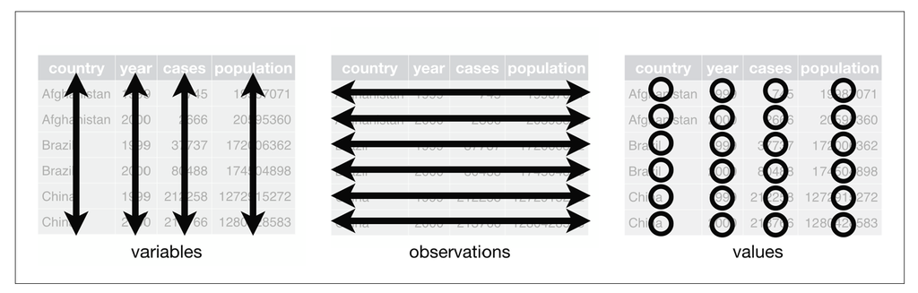

Tidy data set

`pivot_longer()` “lengthens” data, increasing the number of rows and decreasing the number of columns. The inverse transformation is `pivot_wider()`. `pivot_longer()` is an updated approach to `gather()`, designed to be both simpler to use and to handle more use cases. We recommend you use `pivot_longer()` for new code; `gather()` isn’t going away but is no longer under active development.

`pivot_wider()` “widens” data, increasing the number of columns and decreasing the number of rows. The inverse transformation is `pivot_longer()`. `pivot_wider()` is an updated approach to `spread()`, designed to be both simpler to use and to handle more use cases. We recommend you use `pivot_wider()` for new code; `spread()` isn’t going away but is no longer under active development.

```r
# wide to long
# where column names are character data
head(relig_income)
```

```
## # A tibble: 6 × 11
##   religion       `<$10k` $10-2…¹ $20-3…² $30-4…³ $40-5…⁴ $50-7…⁵ $75-1…⁶ $100-…⁷
##   <chr>            <dbl>   <dbl>   <dbl>   <dbl>   <dbl>   <dbl>   <dbl>   <dbl>
## 1 Agnostic            27      34      60      81      76     137     122     109
## 2 Atheist             12      27      37      52      35      70      73      59
## 3 Buddhist            27      21      30      34      33      58      62      39
## 4 Catholic           418     617     732     670     638    1116     949     792
## 5 Don’t know/re…      15      14      15      11      10      35      21      17
## 6 Evangelical P…     575     869    1064     982     881    1486     949     723
## # … with 2 more variables: `>150k` <dbl>, `Don't know/refused` <dbl>, and
## #   abbreviated variable names ¹`$10-20k`, ²`$20-30k`, ³`$30-40k`, ⁴`$40-50k`,
## #   ⁵`$50-75k`, ⁶`$75-100k`, ⁷`$100-150k`
## # ℹ Use `colnames()` to see all variable names
```

```r
relig_income %>%
  pivot_longer(!religion, names_to = "income", values_to = "count")
```

```
## # A tibble: 180 × 3
##    religion income             count
##    <chr>    <chr>              <dbl>
##  1 Agnostic <$10k                 27
##  2 Agnostic $10-20k               34
##  3 Agnostic $20-30k               60
##  4 Agnostic $30-40k               81
##  5 Agnostic $40-50k               76
##  6 Agnostic $50-75k              137
##  7 Agnostic $75-100k             122
##  8 Agnostic $100-150k            109
##  9 Agnostic >150k                 84
## 10 Agnostic Don't know/refused    96
## # … with 170 more rows
## # ℹ Use `print(n = ...)` to see more rows
```

```r
# columns have common prefix and missing missings are structural so should be dropped
head(billboard)
```

```
## # A tibble: 6 × 79
##   artist  track date.ent…¹   wk1   wk2   wk3   wk4   wk5   wk6   wk7   wk8   wk9
##   <chr>   <chr> <date>     <dbl> <dbl> <dbl> <dbl> <dbl> <dbl> <dbl> <dbl> <dbl>
## 1 2 Pac   Baby… 2000-02-26    87    82    72    77    87    94    99    NA    NA
## 2 2Ge+her The … 2000-09-02    91    87    92    NA    NA    NA    NA    NA    NA
## 3 3 Door… Kryp… 2000-04-08    81    70    68    67    66    57    54    53    51
## 4 3 Door… Loser 2000-10-21    76    76    72    69    67    65    55    59    62
## 5 504 Bo… Wobb… 2000-04-15    57    34    25    17    17    31    36    49    53
## 6 98^0    Give… 2000-08-19    51    39    34    26    26    19     2     2     3
## # … with 67 more variables: wk10 <dbl>, wk11 <dbl>, wk12 <dbl>, wk13 <dbl>,
## #   wk14 <dbl>, wk15 <dbl>, wk16 <dbl>, wk17 <dbl>, wk18 <dbl>, wk19 <dbl>,
## #   wk20 <dbl>, wk21 <dbl>, wk22 <dbl>, wk23 <dbl>, wk24 <dbl>, wk25 <dbl>,
## #   wk26 <dbl>, wk27 <dbl>, wk28 <dbl>, wk29 <dbl>, wk30 <dbl>, wk31 <dbl>,
## #   wk32 <dbl>, wk33 <dbl>, wk34 <dbl>, wk35 <dbl>, wk36 <dbl>, wk37 <dbl>,
## #   wk38 <dbl>, wk39 <dbl>, wk40 <dbl>, wk41 <dbl>, wk42 <dbl>, wk43 <dbl>,
## #   wk44 <dbl>, wk45 <dbl>, wk46 <dbl>, wk47 <dbl>, wk48 <dbl>, wk49 <dbl>, …
## # ℹ Use `colnames()` to see all variable names
```

```r
billboard %>%
  pivot_longer(
    cols = starts_with("wk"),
    names_to = "week",
    names_prefix = "wk",
    values_to = "rank",
    values_drop_na = TRUE
  )
```

```
## # A tibble: 5,307 × 5
##    artist  track                   date.entered week   rank
##    <chr>   <chr>                   <date>       <chr> <dbl>
##  1 2 Pac   Baby Don't Cry (Keep... 2000-02-26   1        87
##  2 2 Pac   Baby Don't Cry (Keep... 2000-02-26   2        82
##  3 2 Pac   Baby Don't Cry (Keep... 2000-02-26   3        72
##  4 2 Pac   Baby Don't Cry (Keep... 2000-02-26   4        77
##  5 2 Pac   Baby Don't Cry (Keep... 2000-02-26   5        87
##  6 2 Pac   Baby Don't Cry (Keep... 2000-02-26   6        94
##  7 2 Pac   Baby Don't Cry (Keep... 2000-02-26   7        99
##  8 2Ge+her The Hardest Part Of ... 2000-09-02   1        91
##  9 2Ge+her The Hardest Part Of ... 2000-09-02   2        87
## 10 2Ge+her The Hardest Part Of ... 2000-09-02   3        92
## # … with 5,297 more rows
## # ℹ Use `print(n = ...)` to see more rows
```

```r
# multiple variables stored in column names
head(tidyr::who)
```

```
## # A tibble: 6 × 60
##   country     iso2  iso3   year new_sp…¹ new_s…² new_s…³ new_s…⁴ new_s…⁵ new_s…⁶
##   <chr>       <chr> <chr> <int>    <int>   <int>   <int>   <int>   <int>   <int>
## 1 Afghanistan AF    AFG    1980       NA      NA      NA      NA      NA      NA
## 2 Afghanistan AF    AFG    1981       NA      NA      NA      NA      NA      NA
## 3 Afghanistan AF    AFG    1982       NA      NA      NA      NA      NA      NA
## 4 Afghanistan AF    AFG    1983       NA      NA      NA      NA      NA      NA
## 5 Afghanistan AF    AFG    1984       NA      NA      NA      NA      NA      NA
## 6 Afghanistan AF    AFG    1985       NA      NA      NA      NA      NA      NA
## # … with 50 more variables: new_sp_m65 <int>, new_sp_f014 <int>,
## #   new_sp_f1524 <int>, new_sp_f2534 <int>, new_sp_f3544 <int>,
## #   new_sp_f4554 <int>, new_sp_f5564 <int>, new_sp_f65 <int>,
## #   new_sn_m014 <int>, new_sn_m1524 <int>, new_sn_m2534 <int>,
## #   new_sn_m3544 <int>, new_sn_m4554 <int>, new_sn_m5564 <int>,
## #   new_sn_m65 <int>, new_sn_f014 <int>, new_sn_f1524 <int>,
## #   new_sn_f2534 <int>, new_sn_f3544 <int>, new_sn_f4554 <int>, …
## # ℹ Use `colnames()` to see all variable names
```

```r
tidyr::who %>%
  pivot_longer(
cols = new_sp_m014:newrel_f65,
names_to = c("diagnosis", "gender", "age"),
names_pattern = "new_?(.*)_(.)(.*)",
values_to = "count"
)
```

```
## # A tibble: 405,440 × 8
##    country     iso2  iso3   year diagnosis gender age   count
##    <chr>       <chr> <chr> <int> <chr>     <chr>  <chr> <int>
##  1 Afghanistan AF    AFG    1980 sp        m      014      NA
##  2 Afghanistan AF    AFG    1980 sp        m      1524     NA
##  3 Afghanistan AF    AFG    1980 sp        m      2534     NA
##  4 Afghanistan AF    AFG    1980 sp        m      3544     NA
##  5 Afghanistan AF    AFG    1980 sp        m      4554     NA
##  6 Afghanistan AF    AFG    1980 sp        m      5564     NA
##  7 Afghanistan AF    AFG    1980 sp        m      65       NA
##  8 Afghanistan AF    AFG    1980 sp        f      014      NA
##  9 Afghanistan AF    AFG    1980 sp        f      1524     NA
## 10 Afghanistan AF    AFG    1980 sp        f      2534     NA
## # … with 405,430 more rows
## # ℹ Use `print(n = ...)` to see more rows
```

```r
# multiple observations per row
head(anscombe)
```

```
##   x1 x2 x3 x4   y1   y2    y3   y4
## 1 10 10 10  8 8.04 9.14  7.46 6.58
## 2  8  8  8  8 6.95 8.14  6.77 5.76
## 3 13 13 13  8 7.58 8.74 12.74 7.71
## 4  9  9  9  8 8.81 8.77  7.11 8.84
## 5 11 11 11  8 8.33 9.26  7.81 8.47
## 6 14 14 14  8 9.96 8.10  8.84 7.04
```

```r
anscombe %>%
  pivot_longer(everything(),
 names_to = c(".value", "set"),
 names_pattern = "(.)(.)"
)
```

```
## # A tibble: 44 × 3
##    set       x     y
##    <chr> <dbl> <dbl>
##  1 1        10  8.04
##  2 2        10  9.14
##  3 3        10  7.46
##  4 4         8  6.58
##  5 1         8  6.95
##  6 2         8  8.14
##  7 3         8  6.77
##  8 4         8  5.76
##  9 1        13  7.58
## 10 2        13  8.74
## # … with 34 more rows
## # ℹ Use `print(n = ...)` to see more rows
```

```r
# long to wide
head(fish_encounters)
```

```
## # A tibble: 6 × 3
##   fish  station  seen
##   <fct> <fct>   <int>
## 1 4842  Release     1
## 2 4842  I80_1       1
## 3 4842  Lisbon      1
## 4 4842  Rstr        1
## 5 4842  Base_TD     1
## 6 4842  BCE         1
```

```r
fish_encounters %>%
  pivot_wider(names_from = station, values_from = seen)
```

```
## # A tibble: 19 × 12
##    fish  Release I80_1 Lisbon  Rstr Base_TD   BCE   BCW  BCE2  BCW2   MAE   MAW
##    <fct>   <int> <int>  <int> <int>   <int> <int> <int> <int> <int> <int> <int>
##  1 4842        1     1      1     1       1     1     1     1     1     1     1
##  2 4843        1     1      1     1       1     1     1     1     1     1     1
##  3 4844        1     1      1     1       1     1     1     1     1     1     1
##  4 4845        1     1      1     1       1    NA    NA    NA    NA    NA    NA
##  5 4847        1     1      1    NA      NA    NA    NA    NA    NA    NA    NA
##  6 4848        1     1      1     1      NA    NA    NA    NA    NA    NA    NA
##  7 4849        1     1     NA    NA      NA    NA    NA    NA    NA    NA    NA
##  8 4850        1     1     NA     1       1     1     1    NA    NA    NA    NA
##  9 4851        1     1     NA    NA      NA    NA    NA    NA    NA    NA    NA
## 10 4854        1     1     NA    NA      NA    NA    NA    NA    NA    NA    NA
## 11 4855        1     1      1     1       1    NA    NA    NA    NA    NA    NA
## 12 4857        1     1      1     1       1     1     1     1     1    NA    NA
## 13 4858        1     1      1     1       1     1     1     1     1     1     1
## 14 4859        1     1      1     1       1    NA    NA    NA    NA    NA    NA
## 15 4861        1     1      1     1       1     1     1     1     1     1     1
## 16 4862        1     1      1     1       1     1     1     1     1    NA    NA
## 17 4863        1     1     NA    NA      NA    NA    NA    NA    NA    NA    NA
## 18 4864        1     1     NA    NA      NA    NA    NA    NA    NA    NA    NA
## 19 4865        1     1      1    NA      NA    NA    NA    NA    NA    NA    NA
```

```r
# filling in missing values
fish_encounters %>%
  pivot_wider(names_from = station, values_from = seen, values_fill = 0)
```

```
## # A tibble: 19 × 12
##    fish  Release I80_1 Lisbon  Rstr Base_TD   BCE   BCW  BCE2  BCW2   MAE   MAW
##    <fct>   <int> <int>  <int> <int>   <int> <int> <int> <int> <int> <int> <int>
##  1 4842        1     1      1     1       1     1     1     1     1     1     1
##  2 4843        1     1      1     1       1     1     1     1     1     1     1
##  3 4844        1     1      1     1       1     1     1     1     1     1     1
##  4 4845        1     1      1     1       1     0     0     0     0     0     0
##  5 4847        1     1      1     0       0     0     0     0     0     0     0
##  6 4848        1     1      1     1       0     0     0     0     0     0     0
##  7 4849        1     1      0     0       0     0     0     0     0     0     0
##  8 4850        1     1      0     1       1     1     1     0     0     0     0
##  9 4851        1     1      0     0       0     0     0     0     0     0     0
## 10 4854        1     1      0     0       0     0     0     0     0     0     0
## 11 4855        1     1      1     1       1     0     0     0     0     0     0
## 12 4857        1     1      1     1       1     1     1     1     1     0     0
## 13 4858        1     1      1     1       1     1     1     1     1     1     1
## 14 4859        1     1      1     1       1     0     0     0     0     0     0
## 15 4861        1     1      1     1       1     1     1     1     1     1     1
## 16 4862        1     1      1     1       1     1     1     1     1     0     0
## 17 4863        1     1      0     0       0     0     0     0     0     0     0
## 18 4864        1     1      0     0       0     0     0     0     0     0     0
## 19 4865        1     1      1     0       0     0     0     0     0     0     0
```

```r
# generating column names from multiple variables
head(us_rent_income)
```

```
## # A tibble: 6 × 5
##   GEOID NAME    variable estimate   moe
##   <chr> <chr>   <chr>       <dbl> <dbl>
## 1 01    Alabama income      24476   136
## 2 01    Alabama rent          747     3
## 3 02    Alaska  income      32940   508
## 4 02    Alaska  rent         1200    13
## 5 04    Arizona income      27517   148
## 6 04    Arizona rent          972     4
```

```r
us_rent_income %>%
  pivot_wider(names_from = variable, values_from = c(estimate, moe))
```

```
## # A tibble: 52 × 6
##    GEOID NAME                 estimate_income estimate_rent moe_income moe_rent
##    <chr> <chr>                          <dbl>         <dbl>      <dbl>    <dbl>
##  1 01    Alabama                        24476           747        136        3
##  2 02    Alaska                         32940          1200        508       13
##  3 04    Arizona                        27517           972        148        4
##  4 05    Arkansas                       23789           709        165        5
##  5 06    California                     29454          1358        109        3
##  6 08    Colorado                       32401          1125        109        5
##  7 09    Connecticut                    35326          1123        195        5
##  8 10    Delaware                       31560          1076        247       10
##  9 11    District of Columbia           43198          1424        681       17
## 10 12    Florida                        25952          1077         70        3
## # … with 42 more rows
## # ℹ Use `print(n = ...)` to see more rows
```

```r
# when there are multiple `names_from` or `values_from`, you can use use `names_sep` or `names_glue` to control the output variable names
us_rent_income %>%
  pivot_wider(
    names_from = variable,
    names_sep = ".",
    values_from = c(estimate, moe)
  )
```

```
## # A tibble: 52 × 6
##    GEOID NAME                 estimate.income estimate.rent moe.income moe.rent
##    <chr> <chr>                          <dbl>         <dbl>      <dbl>    <dbl>
##  1 01    Alabama                        24476           747        136        3
##  2 02    Alaska                         32940          1200        508       13
##  3 04    Arizona                        27517           972        148        4
##  4 05    Arkansas                       23789           709        165        5
##  5 06    California                     29454          1358        109        3
##  6 08    Colorado                       32401          1125        109        5
##  7 09    Connecticut                    35326          1123        195        5
##  8 10    Delaware                       31560          1076        247       10
##  9 11    District of Columbia           43198          1424        681       17
## 10 12    Florida                        25952          1077         70        3
## # … with 42 more rows
## # ℹ Use `print(n = ...)` to see more rows
```

```r
us_rent_income %>%
 pivot_wider(
    names_from = variable,
    names_glue = "{variable}_{.value}",
    values_from = c(estimate, moe)
  )
```

```
## # A tibble: 52 × 6
##    GEOID NAME                 income_estimate rent_estimate income_moe rent_moe
##    <chr> <chr>                          <dbl>         <dbl>      <dbl>    <dbl>
##  1 01    Alabama                        24476           747        136        3
##  2 02    Alaska                         32940          1200        508       13
##  3 04    Arizona                        27517           972        148        4
##  4 05    Arkansas                       23789           709        165        5
##  5 06    California                     29454          1358        109        3
##  6 08    Colorado                       32401          1125        109        5
##  7 09    Connecticut                    35326          1123        195        5
##  8 10    Delaware                       31560          1076        247       10
##  9 11    District of Columbia           43198          1424        681       17
## 10 12    Florida                        25952          1077         70        3
## # … with 42 more rows
## # ℹ Use `print(n = ...)` to see more rows
```

```r
warpbreaks <- as_tibble(warpbreaks[c("wool", "tension", "breaks")])
head(warpbreaks)
```

```
## # A tibble: 6 × 3
##   wool  tension breaks
##   <fct> <fct>    <dbl>
## 1 A     L           26
## 2 A     L           30
## 3 A     L           54
## 4 A     L           25
## 5 A     L           70
## 6 A     L           52
```

```r
warpbreaks %>%
  pivot_wider(
    names_from = wool,
    values_from = breaks,
    values_fn = mean
  )
```

```
## # A tibble: 3 × 3
##   tension     A     B
##   <fct>   <dbl> <dbl>
## 1 L        44.6  28.2
## 2 M        24    28.8
## 3 H        24.6  18.8
```

Existen otras tres funciones que son muy útiles para la manipulación de datos: `separate()`, que sirve para asegurar una columna en varias nuevas; `case_when()`, que sirve para establecer condionales y es similar a `ifelse()` y `complete()` que sirve para completar una variable o una combinación de variables.

Para mostrar la primera función convertimos la fecha en tres columnas: año (yr), mes (mo) y día (dy), cuyos elementos están separados por “-“. Por ello, es necesario indicar la columna afectada, los nombres de las nuevas columnas y el símbolo separador. La función `mutate_all()` aplica a todas las columnas otra función, en este caso, `as.numeric()` para convertir todas en numéricas.

En lugar de encapsular y encadenar `ifelse()`, podemos usar la función `case_when()`, en la que empleamos fórmulas en dos tiempos: por un lado la condición; por otro, la acción cuando se cumpla esa condición.

Nuestro conjunto de datos contiene datos diarios desde el 1 de enero de 1980 hasta el 31 de diciembre de 2015. Así que únicamente debemos crear un vector con fechas de este periodo. En la función `complete()` indicamos la columna que queremos completar y le asignamos el vector entero de fechas. El resultado es un nuevo `data.frame` con todas las fechas, rellenando el resto de columnas con NA.

```r
ta_vigo <- read_csv( "input/TG_STAID001395.txt", skip = 20)
head(ta_vigo)
```

```
## # A tibble: 6 × 5
##   STAID SOUID     DATE    TG  Q_TG
##   <dbl> <dbl>    <dbl> <dbl> <dbl>
## 1  1395 20408 19560501 -9999     9
## 2  1395 20408 19560502 -9999     9
## 3  1395 20408 19560503 -9999     9
## 4  1395 20408 19560504 -9999     9
## 5  1395 20408 19560505 -9999     9
## 6  1395 20408 19560506 -9999     9
```

```r
ta_vigo <- mutate(ta_vigo, DATE = lubridate::ymd(DATE), TG = ifelse(TG == -9999, NA, TG / 10)) %>%
  filter(DATE >= "1980-01-01", DATE <= "2015-12-31") %>%
  select(-STAID:-SOUID, -Q_TG) %>%
  rename(date = DATE)
head(ta_vigo)
```

```
## # A tibble: 6 × 2
##   date          TG
##   <date>     <dbl>
## 1 1980-01-01  11.2
## 2 1980-01-02   9.5
## 3 1980-01-03   7.5
## 4 1980-01-04  10.3
## 5 1980-01-05   7.8
## 6 1980-01-06   7.3
```

```r
horas_sol <- read_csv("input/SS_STAID001395.txt", skip = 19)
horas_sol <- mutate(horas_sol, DATE = lubridate::ymd(DATE), SS = ifelse(SS == -9999, NA, SS / 10), month = month(DATE), year = year(DATE))
horas_sol <- rename(horas_sol, date = DATE, sunhours = SS)
horas_sol
```

```
## # A tibble: 22,494 × 6
##     SOUID date       sunhours  Q_SS month  year
##     <dbl> <date>        <dbl> <dbl> <int> <int>
##  1 120414 1956-05-01       NA     9     5  1956
##  2 120414 1956-05-02       NA     9     5  1956
##  3 120414 1956-05-03       NA     9     5  1956
##  4 120414 1956-05-04       NA     9     5  1956
##  5 120414 1956-05-05       NA     9     5  1956
##  6 120414 1956-05-06       NA     9     5  1956
##  7 120414 1956-05-07       NA     9     5  1956
##  8 120414 1956-05-08       NA     9     5  1956
##  9 120414 1956-05-09       NA     9     5  1956
## 10 120414 1956-05-10       NA     9     5  1956
## # … with 22,484 more rows
## # ℹ Use `print(n = ...)` to see more rows
```

```r
data_vigo <- left_join (ta_vigo, horas_sol, by = "date" )
data_vigo
```

```
## # A tibble: 13,149 × 7
##    date          TG  SOUID sunhours  Q_SS month  year
##    <date>     <dbl>  <dbl>    <dbl> <dbl> <int> <int>
##  1 1980-01-01  11.2 120414      0.3     0     1  1980
##  2 1980-01-02   9.5 120414      0.2     0     1  1980
##  3 1980-01-03   7.5 120414      1.2     0     1  1980
##  4 1980-01-04  10.3 120414      0.5     0     1  1980
##  5 1980-01-05   7.8 120414      3       0     1  1980
##  6 1980-01-06   7.3 120414      1.8     0     1  1980
##  7 1980-01-07   9.3 120414      0       0     1  1980
##  8 1980-01-08   9.8 120414      3.3     0     1  1980
##  9 1980-01-09   8.3 120414      0       0     1  1980
## 10 1980-01-10   6.5 120414      4.1     0     1  1980
## # … with 13,139 more rows
## # ℹ Use `print(n = ...)` to see more rows
```

```r
rio::export(data_vigo, file = "input/data_vigo.csv")

# using separate()
# data_vigo <- rio::import("input/data_vigo.csv")
time_df <- select(data_vigo, date) %>%
  separate(date, c("yr", "mo", "dy"), sep = "-") %>%
  mutate_all(as.numeric)
head(time_df)
```

```
## # A tibble: 6 × 3
##      yr    mo    dy
##   <dbl> <dbl> <dbl>
## 1  1980     1     1
## 2  1980     1     2
## 3  1980     1     3
## 4  1980     1     4
## 5  1980     1     5
## 6  1980     1     6
```

```r
# using case_when()
time_df <- mutate(time_df, season = case_when(
  mo %in% c(12, 1:2) ~ "invierno",
  mo %in% 3:5 ~ "primavera",
  mo %in% 6:8 ~ "verano",
  mo %in% 9:11 ~ "otoño"
))

# preparing the data
data_vigo <- gather(data_vigo, Variable, Valor, TG:sunhours)
data_vigo_subset <- filter(data_vigo, Variable == "TG") %>%
  slice(sample(nrow(data_vigo), 10000)) %>%
  arrange(date)
head(data_vigo_subset)
```

```
## # A tibble: 6 × 6
##   date        Q_SS month  year Variable Valor
##   <date>     <dbl> <int> <int> <chr>    <dbl>
## 1 1980-01-07     0     1  1980 TG         9.3
## 2 1980-01-11     0     1  1980 TG         7.1
## 3 1980-01-13     0     1  1980 TG         3.4
## 4 1980-01-17     0     1  1980 TG         4.5
## 5 1980-01-23     0     1  1980 TG        10.4
## 6 1980-01-27     0     1  1980 TG        12.7
```

```r
date_ts <- seq(lubridate::ymd("1980-01-01"), lubridate::ymd("2015-12-31"), "day")

# using complete()
data_vigo_subset <- complete(data_vigo_subset, date = date_ts)
head(data_vigo_subset)
```

```
## # A tibble: 6 × 6
##   date        Q_SS month  year Variable Valor
##   <date>     <dbl> <int> <int> <chr>    <dbl>
## 1 1980-01-01    NA    NA    NA <NA>        NA
## 2 1980-01-02    NA    NA    NA <NA>        NA
## 3 1980-01-03    NA    NA    NA <NA>        NA
## 4 1980-01-04    NA    NA    NA <NA>        NA
## 5 1980-01-05    NA    NA    NA <NA>        NA
## 6 1980-01-06    NA    NA    NA <NA>        NA
```

## 4.3 Packages

Sometimes it makes sense to spread an observation over multiple rows (long format), and sometimes it makes more sense to spread a variable across multiple columns (wide format). Some analyses require long data, whereas others require wide data.

When going from a **long format to a wide format**, you choose columns to group the observations by (in the *gapminder* case: `country` and maybe also `continent`), columns to take values names from (`lifeExp`, `pop` and `gdpPercap`), and columns to create variable names from (year). In *data.table*, the transformation from long to wide is done using the `dcast` function.

In *data.table*, **wide-to-long** formatting is done using `melt`.

```r
gm <- as.data.table(gapminder)
head(gm)
```

```
##        country continent year lifeExp      pop gdpPercap
## 1: Afghanistan      Asia 1952  28.801  8425333  779.4453
## 2: Afghanistan      Asia 1957  30.332  9240934  820.8530
## 3: Afghanistan      Asia 1962  31.997 10267083  853.1007
## 4: Afghanistan      Asia 1967  34.020 11537966  836.1971
## 5: Afghanistan      Asia 1972  36.088 13079460  739.9811
## 6: Afghanistan      Asia 1977  38.438 14880372  786.1134
```

```r
# from long to wide
gmw <- dcast(gm, country + continent ~ year, value.var = c("pop", "lifeExp", "gdpPercap"))
head(gmw)
```

```
##        country continent pop_1952 pop_1957 pop_1962 pop_1967 pop_1972 pop_1977
## 1: Afghanistan      Asia  8425333  9240934 10267083 11537966 13079460 14880372
## 2:     Albania    Europe  1282697  1476505  1728137  1984060  2263554  2509048
## 3:     Algeria    Africa  9279525 10270856 11000948 12760499 14760787 17152804
## 4:      Angola    Africa  4232095  4561361  4826015  5247469  5894858  6162675
## 5:   Argentina  Americas 17876956 19610538 21283783 22934225 24779799 26983828
## 6:   Australia   Oceania  8691212  9712569 10794968 11872264 13177000 14074100
##    pop_1982 pop_1987 pop_1992 pop_1997 pop_2002 pop_2007 lifeExp_1952
## 1: 12881816 13867957 16317921 22227415 25268405 31889923       28.801
## 2:  2780097  3075321  3326498  3428038  3508512  3600523       55.230
## 3: 20033753 23254956 26298373 29072015 31287142 33333216       43.077
## 4:  7016384  7874230  8735988  9875024 10866106 12420476       30.015
## 5: 29341374 31620918 33958947 36203463 38331121 40301927       62.485
## 6: 15184200 16257249 17481977 18565243 19546792 20434176       69.120
##    lifeExp_1957 lifeExp_1962 lifeExp_1967 lifeExp_1972 lifeExp_1977
```

[output cut: 34 more lines]

```r
# wide-to-long (not the best approach!)
gm <- melt(gmw, id.vars = c("country", "continent"), measure.vars = 2:37)
head(gm)
```

```
##        country continent  variable    value
## 1: Afghanistan      Asia continent     Asia
## 2:     Albania    Europe continent   Europe
## 3:     Algeria    Africa continent   Africa
## 4:      Angola    Africa continent   Africa
## 5:   Argentina  Americas continent Americas
## 6:   Australia   Oceania continent  Oceania
```

```r
# splitting columns and casting
gm[, c("variable", "year") := tstrsplit(variable, "_", fixed = TRUE)]
gm <- dcast(gm, country + year ~ variable, value.var = c("value"))
head(gm)
```

```
##        country year continent   gdpPercap lifeExp      pop
## 1: Afghanistan <NA>      Asia        <NA>    <NA>     <NA>
## 2: Afghanistan 1952      <NA> 779.4453145  28.801  8425333
## 3: Afghanistan 1957      <NA> 820.8530296  30.332  9240934
## 4: Afghanistan 1962      <NA>   853.10071  31.997 10267083
## 5: Afghanistan 1967      <NA> 836.1971382   34.02 11537966
## 6: Afghanistan 1972      <NA> 739.9811058  36.088 13079460
```

```r
# merging columns
aq <- as.data.table(airquality)
head(aq)
```

```
##    Ozone Solar.R Wind Temp Month Day
## 1:    41     190  7.4   67     5   1
## 2:    36     118  8.0   72     5   2
## 3:    12     149 12.6   74     5   3
## 4:    18     313 11.5   62     5   4
## 5:    NA      NA 14.3   56     5   5
## 6:    28      NA 14.9   66     5   6
```

```r
# creating a new column Date and mergin Month and Day into it (date format)
aq[, Date := as.Date(paste(1973, aq$Month, aq$Day, sep = "-"))]
head(aq)
```

```
##    Ozone Solar.R Wind Temp Month Day       Date
## 1:    41     190  7.4   67     5   1 1973-05-01
## 2:    36     118  8.0   72     5   2 1973-05-02
## 3:    12     149 12.6   74     5   3 1973-05-03
## 4:    18     313 11.5   62     5   4 1973-05-04
## 5:    NA      NA 14.3   56     5   5 1973-05-05
## 6:    28      NA 14.9   66     5   6 1973-05-06
```

It is common that data is spread over multiple tables. Consequently, it is important to be able to merge data from different tables. The simplest types of merges are binds, which can be used when you have two tables where either the rows or the columns match each other exactly.

An operation that combines columns from two tables is called a **join**. There are two main types of joins: **inner joins** and **outer joins**.

- **Inner joins**: create a table containing all observations for which the key appeared in both tables. So if we perform an inner join on the `rev_data` and `weather_data` tables using `DATE` as the key, it won”t contain data for the days that are missing from either the revenue table or the weather table.

In contrast, outer joins create a table retaining rows, even if there is no match in the other table. There are three types of outer joins:

- **Left join**: retains all rows from the first table. In the revenue example, this means all dates present in rev_data.
- **Right join**: retains all rows from the second table. In the revenue example, this means all dates present in weather_data.
- **Full join**: retains all rows present in at least one of the tables. In the revenue example, this means all dates present in at least one of `rev_data` and `weather_data`.

**Semijoins** and **antijoins** are similar to joins, but work on observations rather than variables. That is, they are used for filtering one table using data from another table:

- **Semijoin**: retains all observations in the first table that have a match in the second table.
- **Antijoin**: retains all observations in the first table that do not have a match in the second table.

The same thing can be achieved using the filtering techniques, but semijoins and antijoins are simpler to use when the filtering relies on conditions from another table.

```r
# preparing the data
rev_data <- read.csv("input/sales-rev.csv", sep = ";")
weather_data <- read.csv("input/sales-weather.csv", sep = ";")

rev_data <- as.data.table(rev_data)
rev_data$DATE <- as.Date(rev_data$DATE)
weather_data <- as.data.table(weather_data)
weather_data$DATE <- as.Date(weather_data$DATE)

rev_jan <- rev_data[DATE %between% c("2020-01-01", "2020-01-31"), ]
rev_feb <- rev_data[DATE %between% c("2020-02-01", "2020-02-29"), ]
weather_jan <- weather_data[DATE %between% c("2020-01-01", "2020-01-31"), ]

str(rev_jan)
```

```
## Classes 'data.table' and 'data.frame':   31 obs. of  2 variables:
##  $ DATE   : Date, format: "2020-01-01" "2020-01-02" ...
##  $ REVENUE: int  7637 9276 11170 11863 10880 6702 8652 8346 6543 8115 ...
##  - attr(*, ".internal.selfref")=<externalptr>
```

```r
str(rev_feb)
```

```
## Classes 'data.table' and 'data.frame':   29 obs. of  2 variables:
##  $ DATE   : Date, format: "2020-02-01" "2020-02-02" ...
##  $ REVENUE: int  10192 13904 11208 8578 6638 7093 8187 10099 8160 3797 ...
##  - attr(*, ".internal.selfref")=<externalptr>
```

```r
str(weather_jan)
```

```
## Classes 'data.table' and 'data.frame':   31 obs. of  5 variables:
##  $ DATE         : Date, format: "2020-01-01" "2020-01-02" ...
##  $ SUN_HOURS    : num  0 0.372 0.264 3.549 2.513 ...
##  $ PRECIPITATION: num  0 0 0 0 2.4 0.2 0 0 0.6 0 ...
##  $ SNOW_DEPTH   : num  0 0 0 0 0 0 0 0 0 0 ...
##  $ TEMPERATURE  : num  0 5.8 5.4 2.4 0.1 4.8 5.5 6.5 3.9 1 ...
##  - attr(*, ".internal.selfref")=<externalptr>
```

```r
# with Base-R
# Join columns of datasets that # have the same rows:
cbind(rev_jan, weather_jan)
```

```
##           DATE REVENUE       DATE  SUN_HOURS PRECIPITATION SNOW_DEPTH
##  1: 2020-01-01    7637 2020-01-01 0.00000000           0.0          0
##  2: 2020-01-02    9276 2020-01-02 0.37250000           0.0          0
##  3: 2020-01-03   11170 2020-01-03 0.26361111           0.0          0
##  4: 2020-01-04   11863 2020-01-04 3.54861111           0.0          0
##  5: 2020-01-05   10880 2020-01-05 2.51250000           2.4          0
##  6: 2020-01-06    6702 2020-01-06 0.09333333           0.2          0
##  7: 2020-01-07    8652 2020-01-07 0.00000000           0.0          0
##  8: 2020-01-08    8346 2020-01-08 0.16166667           0.0          0
##  9: 2020-01-09    6543 2020-01-09 0.31944444           0.6          0
## 10: 2020-01-10    8115 2020-01-10 1.58694444           0.0          0
## 11: 2020-01-11    7728 2020-01-11 0.00000000           0.2          0
## 12: 2020-01-12   10649 2020-01-12 0.44194444           0.0          0
## 13: 2020-01-13    6787 2020-01-13 2.42083333           0.0          0
## 14: 2020-01-14    4555 2020-01-14 0.00000000           7.4          0
```

[output cut: 51 more lines]

```r
# Join rows of datasets that have # the same columns:
rbind(rev_jan, rev_feb)
```

```
##           DATE REVENUE
##  1: 2020-01-01    7637
##  2: 2020-01-02    9276
##  3: 2020-01-03   11170
##  4: 2020-01-04   11863
##  5: 2020-01-05   10880
##  6: 2020-01-06    6702
##  7: 2020-01-07    8652
##  8: 2020-01-08    8346
##  9: 2020-01-09    6543
## 10: 2020-01-10    8115
## 11: 2020-01-11    7728
## 12: 2020-01-12   10649
## 13: 2020-01-13    6787
## 14: 2020-01-14    4555
```

[output cut: 47 more lines]

```r
# with dplyr
# Join columns of datasets that # have the same rows:
# bind_cols(rev_jan, weather_jan)

# Join rows of datasets that have # the same columns:
# bind_rows(rev_jan, rev_feb)

# merging tables using keys
# data.table
# inner join
merge(rev_data, weather_data, by = "DATE")
```

```
##           DATE REVENUE   SUN_HOURS PRECIPITATION SNOW_DEPTH TEMPERATURE
##  1: 2020-01-01    7637  0.00000000           0.0       0.00         0.0
##  2: 2020-01-02    9276  0.37250000           0.0       0.00         5.8
##  3: 2020-01-03   11170  0.26361111           0.0       0.00         5.4
##  4: 2020-01-04   11863  3.54861111           0.0       0.00         2.4
##  5: 2020-01-05   10880  2.51250000           2.4       0.00         0.1
##  6: 2020-01-06    6702  0.09333333           0.2       0.00         4.8
##  7: 2020-01-07    8652  0.00000000           0.0       0.00         5.5
##  8: 2020-01-08    8346  0.16166667           0.0       0.00         6.5
##  9: 2020-01-09    6543  0.31944444           0.6       0.00         3.9
## 10: 2020-01-10    8115  1.58694444           0.0       0.00         1.0
## 11: 2020-01-11    7728  0.00000000           0.2       0.00         1.2
## 12: 2020-01-12   10649  0.44194444           0.0       0.00         5.9
## 13: 2020-01-13    6787  2.42083333           0.0       0.00         2.6
## 14: 2020-01-14    4555  0.00000000           7.4       0.00         3.8
```

[output cut: 73 more lines]

```r
# Or:
# setkey(rev_data, DATE)
# rev_data[weather_data, nomatch = 0]

# # dplyr
# rev_data %>%
#   inner_join( weather_data, by = "DATE")

# outer join (left)
# data.table
merge(rev_data, weather_data, all.x = TRUE, by = "DATE")
```

```
##           DATE REVENUE   SUN_HOURS PRECIPITATION SNOW_DEPTH TEMPERATURE
##  1: 2020-01-01    7637  0.00000000           0.0       0.00         0.0
##  2: 2020-01-02    9276  0.37250000           0.0       0.00         5.8
##  3: 2020-01-03   11170  0.26361111           0.0       0.00         5.4
##  4: 2020-01-04   11863  3.54861111           0.0       0.00         2.4
##  5: 2020-01-05   10880  2.51250000           2.4       0.00         0.1
##  6: 2020-01-06    6702  0.09333333           0.2       0.00         4.8
##  7: 2020-01-07    8652  0.00000000           0.0       0.00         5.5
##  8: 2020-01-08    8346  0.16166667           0.0       0.00         6.5
##  9: 2020-01-09    6543  0.31944444           0.6       0.00         3.9
## 10: 2020-01-10    8115  1.58694444           0.0       0.00         1.0
## 11: 2020-01-11    7728  0.00000000           0.2       0.00         1.2
## 12: 2020-01-12   10649  0.44194444           0.0       0.00         5.9
## 13: 2020-01-13    6787  2.42083333           0.0       0.00         2.6
## 14: 2020-01-14    4555  0.00000000           7.4       0.00         3.8
```

[output cut: 77 more lines]

```r
# Or:
# setkey(weather_data, DATE)
# weather_data[rev_data]

# dplyr
# rev_data %>%
#   left_join( weather_data, by = "DATE")

# outer join (right)
# data.table
merge(rev_data, weather_data, all.y = TRUE, by = "DATE")
```

```
##           DATE REVENUE   SUN_HOURS PRECIPITATION SNOW_DEPTH TEMPERATURE
##  1: 2020-01-01    7637  0.00000000           0.0       0.00         0.0
##  2: 2020-01-02    9276  0.37250000           0.0       0.00         5.8
##  3: 2020-01-03   11170  0.26361111           0.0       0.00         5.4
##  4: 2020-01-04   11863  3.54861111           0.0       0.00         2.4
##  5: 2020-01-05   10880  2.51250000           2.4       0.00         0.1
##  6: 2020-01-06    6702  0.09333333           0.2       0.00         4.8
##  7: 2020-01-07    8652  0.00000000           0.0       0.00         5.5
##  8: 2020-01-08    8346  0.16166667           0.0       0.00         6.5
##  9: 2020-01-09    6543  0.31944444           0.6       0.00         3.9
## 10: 2020-01-10    8115  1.58694444           0.0       0.00         1.0
## 11: 2020-01-11    7728  0.00000000           0.2       0.00         1.2
## 12: 2020-01-12   10649  0.44194444           0.0       0.00         5.9
## 13: 2020-01-13    6787  2.42083333           0.0       0.00         2.6
## 14: 2020-01-14    4555  0.00000000           7.4       0.00         3.8
```

[output cut: 74 more lines]

```r
# Or:
# setkey(rev_data, DATE)
# rev_data[weather_data]

# dplyr
# rev_data %>%
#   right_join(weather_data, by = "DATE")

# full join
# data.table
merge(rev_data, weather_data, all = TRUE, by = "DATE")
```

```
##           DATE REVENUE   SUN_HOURS PRECIPITATION SNOW_DEPTH TEMPERATURE
##  1: 2020-01-01    7637  0.00000000           0.0       0.00         0.0
##  2: 2020-01-02    9276  0.37250000           0.0       0.00         5.8
##  3: 2020-01-03   11170  0.26361111           0.0       0.00         5.4
##  4: 2020-01-04   11863  3.54861111           0.0       0.00         2.4
##  5: 2020-01-05   10880  2.51250000           2.4       0.00         0.1
##  6: 2020-01-06    6702  0.09333333           0.2       0.00         4.8
##  7: 2020-01-07    8652  0.00000000           0.0       0.00         5.5
##  8: 2020-01-08    8346  0.16166667           0.0       0.00         6.5
##  9: 2020-01-09    6543  0.31944444           0.6       0.00         3.9
## 10: 2020-01-10    8115  1.58694444           0.0       0.00         1.0
## 11: 2020-01-11    7728  0.00000000           0.2       0.00         1.2
## 12: 2020-01-12   10649  0.44194444           0.0       0.00         5.9
## 13: 2020-01-13    6787  2.42083333           0.0       0.00         2.6
## 14: 2020-01-14    4555  0.00000000           7.4       0.00         3.8
```

[output cut: 78 more lines]

```r
# dplyr
# rev_data %>%
#   full_join( weather_data, by = "DATE")

# preparing the data
filter_data <- weather_data[TEMPERATURE < 0 & DATE %between% c("2020-02-01", "2020-02-29"), ]
head(filter_data)
```

```
##          DATE  SUN_HOURS PRECIPITATION SNOW_DEPTH TEMPERATURE
## 1: 2020-02-04 0.09138889           0.2       0.00        -1.3
## 2: 2020-02-27 0.00000000           0.8       0.01        -1.3
## 3: 2020-02-28 6.55861111           0.2       0.05        -1.3
```

```r
# using a semijoin
# data.table
setkey(rev_data, DATE)
rev_data[rev_data[filter_data, which = TRUE]]
```

```
##          DATE REVENUE
## 1: 2020-02-04    8578
## 2: 2020-02-27    3789
## 3: 2020-02-28    7480
```

```r
# dplyr
# rev_data %>%
#   semi_join(filter_data, by = "DATE")

# antijoin
# data.table
setkey(rev_data, DATE)
rev_data[!filter_data]
```

```
##           DATE REVENUE
##  1: 2020-01-01    7637
##  2: 2020-01-02    9276
##  3: 2020-01-03   11170
##  4: 2020-01-04   11863
##  5: 2020-01-05   10880
##  6: 2020-01-06    6702
##  7: 2020-01-07    8652
##  8: 2020-01-08    8346
##  9: 2020-01-09    6543
## 10: 2020-01-10    8115
## 11: 2020-01-11    7728
## 12: 2020-01-12   10649
## 13: 2020-01-13    6787
## 14: 2020-01-14    4555
```

[output cut: 74 more lines]

```r
# dplyr
# rev_data %>%
#   anti_join(filter_data, by = "DATE")
```

# 5 Summarizing data sets

## 5.1 Base-R

```r
# returns column index names in table format
data.frame(colnames(snowdata))
```

```
##   colnames.snowdata.
## 1             Winter
## 2         SnowInches
## 3         SnowMeters
```

```r
# returns row index numbers in table format
data.frame(as.integer(rownames(snowdata)))
```

```
##    as.integer.rownames.snowdata..
## 1                               1
## 2                               2
## 3                               3
## 4                               4
## 5                               5
## 6                               6
## 7                               7
## 8                               8
## 9                               9
## 10                             10
## 11                             11
## 12                             12
## 13                             13
## 14                             14
```

[output cut: 62 more lines]

```r
# getting a sense of the data set
str(snowdata)
```

```
## 'data.frame':    76 obs. of  3 variables:
##  $ Winter    : chr  "1940-1941" "1941-1942" "1942-1943" "1943-1944" ...
##  $ SnowInches: num  47.8 23.9 45.7 27.7 59.2 50.8 19.4 89.2 37.1 32 ...
##  $ SnowMeters: num  1.214 0.607 1.161 0.704 1.504 ...
```

```r
# showing the number of rows and columns...
dim(snowdata)
```

```
## [1] 76  3
```

```r
nrow(snowdata)
```

```
## [1] 76
```

```r
ncol(snowdata)
```

```
## [1] 3
```

```r
# ...and names
dimnames(snowdata)
```

```
## [[1]]
##  [1] "1"  "2"  "3"  "4"  "5"  "6"  "7"  "8"  "9"  "10" "11" "12" "13" "14" "15"
## [16] "16" "17" "18" "19" "20" "21" "22" "23" "24" "25" "26" "27" "28" "29" "30"
## [31] "31" "32" "33" "34" "35" "36" "37" "38" "39" "40" "41" "42" "43" "44" "45"
## [46] "46" "47" "48" "49" "50" "51" "52" "53" "54" "55" "56" "57" "58" "59" "60"
## [61] "61" "62" "63" "64" "65" "66" "67" "68" "69" "70" "71" "72" "73" "74" "75"
## [76] "76"
##
## [[2]]
## [1] "Winter"     "SnowInches" "SnowMeters"
```

```r
rownames(snowdata)
```

```
##  [1] "1"  "2"  "3"  "4"  "5"  "6"  "7"  "8"  "9"  "10" "11" "12" "13" "14" "15"
## [16] "16" "17" "18" "19" "20" "21" "22" "23" "24" "25" "26" "27" "28" "29" "30"
## [31] "31" "32" "33" "34" "35" "36" "37" "38" "39" "40" "41" "42" "43" "44" "45"
## [46] "46" "47" "48" "49" "50" "51" "52" "53" "54" "55" "56" "57" "58" "59" "60"
## [61] "61" "62" "63" "64" "65" "66" "67" "68" "69" "70" "71" "72" "73" "74" "75"
## [76] "76"
```

```r
colnames(snowdata)
```

```
## [1] "Winter"     "SnowInches" "SnowMeters"
```

```r
# a brief statistical summary of a data set, run the summary() function
summary(snowdata)
```

```
##     Winter            SnowInches       SnowMeters
##  Length:76          Min.   :  9.30   Min.   :0.2362
##  Class :character   1st Qu.: 27.57   1st Qu.:0.7004
##  Mode  :character   Median : 42.75   Median :1.0858
##                     Mean   : 44.49   Mean   :1.1299
##                     3rd Qu.: 57.60   3rd Qu.:1.4630
##                     Max.   :110.60   Max.   :2.8092
```

## 5.2 Tidyverse

```r
glimpse(snowdata)
```

```
## Rows: 76
## Columns: 3
## $ Winter     <chr> "1940-1941", "1941-1942", "1942-1943", "1943-1944", "1944-1…
## $ SnowInches <dbl> 47.8, 23.9, 45.7, 27.7, 59.2, 50.8, 19.4, 89.2, 37.1, 32.0,…
## $ SnowMeters <dbl> 1.21412, 0.60706, 1.16078, 0.70358, 1.50368, 1.29032, 0.492…
```

## 5.3 Packages

Find and concisely describe the difference between a pair of R objects with *waldo* package. One of the first things worth doing after importing a data set is looking at the first few rows, the last few rows, and a summary of some basic stats. This can be easily achieved thanks to the `headTail()` function of the *psych* package. To get a brief statistical summary you can use the `describe()` function of the *Hmisc* package or the *psych* package (only works for numeric data). The *skimr* package’s `skim()` function will show information on each column, including a little histogram for each numeric one.

```r
df1 <- data.frame(X = c(1, 2, 3), Y = c("a", "b", "c"), A = c(3, 4, 5))
df2 <- data.frame(X = c(1, 2, 3, 4), Y = c("A", "b", "c", "d"), Z = c("k", "l", "m", "n"), A = c("3", "4", "5", "6"))
waldo::compare(df1, df2)
```

```
## `old` is length 3
## `new` is length 4
##
## `names(old)`: "X" "Y" "A"
## `names(new)`: "X" "Y" "Z" "A"
##
## `attr(old, 'row.names')`: 1 2 3
## `attr(new, 'row.names')`: 1 2 3 4
##
## `old$X`: 1 2 3
## `new$X`: 1 2 3 4
##
## `old$Y[2:3]`:         "b" "c"
## `new$Y`:      "A" "b" "c" "d"
##
## `old$A` is a double vector (3, 4, 5)
## `new$A` is a character vector ('3', '4', '5', '6')
##
## `old$Z` is absent
## `new$Z` is a character vector ('k', 'l', 'm', 'n')
```

```r
# getting the first and last rows
headTail(snowdata)
```

```
##        Winter SnowInches SnowMeters
## 1   1940-1941       47.8       1.21
## 2   1941-1942       23.9       0.61
## 3   1942-1943       45.7       1.16
## 4   1943-1944       27.7        0.7
## ...      <NA>        ...        ...
## 73  2012-2013       63.4       1.61
## 74  2013-2014       58.9        1.5
## 75  2014-2015      110.6       2.81
## 76  2015-2016       36.2       0.92
```

```r
# getting statistical info
Hmisc::describe(snowdata)
```

```
## snowdata
##
##  3  Variables      76  Observations
## --------------------------------------------------------------------------------
## Winter
##        n  missing distinct
##       76        0       76
##
## lowest : 1940-1941 1941-1942 1942-1943 1943-1944 1944-1945
## highest: 2011-2012 2012-2013 2013-2014 2014-2015 2015-2016
## --------------------------------------------------------------------------------
## SnowInches
##        n  missing distinct     Info     Mean      Gmd      .05      .10
##       76        0       75        1    44.49    24.92    15.05    18.60
##      .25      .50      .75      .90      .95
##    27.58    42.75    57.60    75.95    87.25
##
## lowest :   9.3  10.3  12.5  14.9  15.1, highest:  86.6  89.2  96.3 107.6 110.6
## --------------------------------------------------------------------------------
## SnowMeters
##        n  missing distinct     Info     Mean      Gmd      .05      .10
##       76        0       75        1     1.13   0.6329   0.3823   0.4724
##      .25      .50      .75      .90      .95
##   0.7004   1.0858   1.4630   1.9291   2.2161
##
## lowest : 0.23622 0.26162 0.31750 0.37846 0.38354
## highest: 2.19964 2.26568 2.44602 2.73304 2.80924
## --------------------------------------------------------------------------------
```

```r
psych::describe(snowdata)
```

```
##            vars  n  mean    sd median trimmed   mad  min    max  range skew
## Winter*       1 76 38.50 22.08  38.50   38.50 28.17 1.00  76.00  75.00 0.00
## SnowInches    2 76 44.49 22.51  42.75   42.37 22.54 9.30 110.60 101.30 0.84
## SnowMeters    3 76  1.13  0.57   1.09    1.08  0.57 0.24   2.81   2.57 0.84
##            kurtosis   se
## Winter*       -1.25 2.53
## SnowInches     0.46 2.58
## SnowMeters     0.46 0.07
```

```r
skim(snowdata)
```

Data summary

| Name | snowdata |
| --- | --- |
| Number of rows | 76 |
| Number of columns | 3 |
| _______________________ |  |
| Column type frequency: |  |
| character | 1 |
| numeric | 2 |
| ________________________ |  |
| Group variables | None |

**Variable type: character**

| skim_variable | n_missing | complete_rate | min | max | empty | n_unique | whitespace |
| --- | --- | --- | --- | --- | --- | --- | --- |
| Winter | 0 | 1 | 9 | 9 | 0 | 76 | 0 |

**Variable type: numeric**

| skim_variable | n_missing | complete_rate | mean | sd | p0 | p25 | p50 | p75 | p100 | hist |
| --- | --- | --- | --- | --- | --- | --- | --- | --- | --- | --- |
| SnowInches | 0 | 1 | 44.49 | 22.51 | 9.30 | 27.58 | 42.75 | 57.60 | 110.60 | ▆▇▅▂▁ |
| SnowMeters | 0 | 1 | 1.13 | 0.57 | 0.24 | 0.70 | 1.09 | 1.46 | 2.81 | ▆▇▅▂▁ |

# 6 Subsetting and modifying data frames

## 6.1 Base-R

For objects that contain more than one element (vectors, matrices, arrays, data frames, and lists), subscripting is used to access some or all of those elements. Besides the usual numeric subscripts, R allows the use of character or logical values for subscripting. Subscripting operations are very fast and efficient, and are often the most powerful tool for accessing and manipulating data in R.

Like most computer languages, numeric subscripts can be used to access the elements of a vector, array, or list. The first element of an object has subscript 1; subscripts of 0 are silently ignored. In addition to a single number, a vector of subscripts (or, for example, a function call that returns a vector of subscripts) can be used to access multiple elements. The colon operator and the `seq` function are especially useful here. Negative subscripts in R extract all of the elements of an object except the ones specified in the negative subscript; thus, when using numeric subscripts, subscripts must be either all positive (or zero) or all negative (or zero).

If a subscriptable object is named, a character string or vector of character strings can be used as a subscript. Negative character subscripts are not permitted; if you need to exclude elements based on their names, the `grep` function can be used.

Lists are the most general way to store a collection of objects in R, because there is no limitation on the mode of the objects that a list may hold. Although it hasn”t been explicitly stated, one rule of subscripting in R is that subscripting will always return an object of the same mode as the object being subscripted. For matrices and vectors, this is completely natural, and should never cause confusion. But for lists, there is a subtle distinction between part of a list, and the object which that part of the list represents.

If the elements of the list are named, the actual contents of the elements can be accessed by separating the name of the list from the name of the element with a dollar sign ($). For interactive sessions, using the dollar sign notation is the natural way to perform operations on the elements of a list. For those situations where the dollar sign notation would be inappropriate (for example, accessing elements through their index or through a name stored in a character variable), R provides the double bracket subscript operator. Double brackets are not restricted to respect the mode of the object they are subscripting, and will extract the actual list element from the list.

**The key thing to notice is that in this case, single brackets will always return a list containing the selected element(s), while double brackets will return the actual contents of selected list element.**

Since data frames are a cross between a list and a matrix, it”s not surprising that both matrix and list subscripting techniques apply to data frames. When using logical subscripts with data frames containing missing values, it may be necessary to remove the missing values before the logical comparison is made, or unexpected results may occur. This situation is so common that R provides the `subset` function which accepts a data frame, matrix or vector, and a logical expression as its first two arguments, and which returns a similar object containing only those elements that meet the condition of the logical expression. It insures that missing values don”t get included, and, if its first argument is a data frame or matrix with named columns, it also resolves variable names inside the logical expression from the object passed as the first argument. A further convenience is offered by the `select=` argument which will extract only the specified columns from the data frame passed as the first argument. The argument to `select=` is a vector of integers or variable names which correspond to the columns that are to be extracted. Unlike most other functions in R, names passed through the `select=` argument can be either quoted or unquoted. To ignore columns, their name or index number can be preceded by a negative sign (-). Since the `select=` argument works by replacing variable names with their corresponding column indices, ranges of columns can be specified using variable names. The `subset` function will always return a new data frame, matrix or vector, so it is **not suited for modifying selected parts of a data frame**.

To sort the elements of an object, use the `sort` function. Add the `decreasing=TRUE` option to sort in reverse order. You can control the treatment of NA values by setting the `na.last` argument. To sort a data frame, you need to create a permutation of the indices from the data frame and use these to fetch the rows of the data frame in the correct order. You can generate an appropriate permutation of the indices using the `order` function. The `order` function takes a set of vectors as arguments. It sorts recursively by each vector, breaking ties by looking at successive vectors in the argument list. At the end, it returns a permutation of the indices of the vector corresponding to the sorted order.

```r
# subsetting a list
simple <- list(a = c("fred", "sam", "harry"), b = c(24, 17, 19, 22))
mode(simple)
```

```
## [1] "list"
```

```r
simple[2]
```

```
## $b
## [1] 24 17 19 22
```

```r
mode(simple[2])
```

```
## [1] "list"
```

```r
simple$b
```

```
## [1] 24 17 19 22
```

```r
mean(simple$b)
```

```
## [1] 20.5
```

```r
mean(simple[[2]])
```

```
## [1] 20.5
```

```r
# single brackets return a list
simple[1]
```

```
## $a
## [1] "fred"  "sam"   "harry"
```

```r
# double brackets return the actual contents of selected list element
simple[[1]]
```

```
## [1] "fred"  "sam"   "harry"
```

```r
# subsetting a data frame
# First, we check the order of the columns:
data.frame(names(airquality))
```

```
##   names.airquality.
## 1             Ozone
## 2           Solar.R
## 3              Wind
## 4              Temp
## 5             Month
## 6               Day
```

```r
airquality[5, 4]    # The 5th element from the 4th column,
```

```
## [1] 56
```

```r
                    # i.e. the same as airquality$Temp[5]
airquality[5,]      # The 5th row of the data
```

```
##   Ozone Solar.R Wind Temp Month Day
## 5    NA      NA 14.3   56     5   5
```

```r
airquality[, 4]     # The 4th column of the data, like airquality$Temp
```

```
##   [1] 67 72 74 62 56 66 65 59 61 69 74 69 66 68 58 64 66 57 68 62 59 73 61 61 57
##  [26] 58 57 67 81 79 76 78 74 67 84 85 79 82 87 90 87 93 92 82 80 79 77 72 65 73
##  [51] 76 77 76 76 76 75 78 73 80 77 83 84 85 81 84 83 83 88 92 92 89 82 73 81 91
##  [76] 80 81 82 84 87 85 74 81 82 86 85 82 86 88 86 83 81 81 81 82 86 85 87 89 90
## [101] 90 92 86 86 82 80 79 77 79 76 78 78 77 72 75 79 81 86 88 97 94 96 94 91 92
## [126] 93 93 87 84 80 78 75 73 81 76 77 71 71 78 67 76 68 82 64 71 81 69 63 70 77
## [151] 75 76 68
```

```r
airquality[[4]]     # The 4th column of the data, like airquality$Temp
```

```
##   [1] 67 72 74 62 56 66 65 59 61 69 74 69 66 68 58 64 66 57 68 62 59 73 61 61 57
##  [26] 58 57 67 81 79 76 78 74 67 84 85 79 82 87 90 87 93 92 82 80 79 77 72 65 73
##  [51] 76 77 76 76 76 75 78 73 80 77 83 84 85 81 84 83 83 88 92 92 89 82 73 81 91
##  [76] 80 81 82 84 87 85 74 81 82 86 85 82 86 88 86 83 81 81 81 82 86 85 87 89 90
## [101] 90 92 86 86 82 80 79 77 79 76 78 78 77 72 75 79 81 86 88 97 94 96 94 91 92
## [126] 93 93 87 84 80 78 75 73 81 76 77 71 71 78 67 76 68 82 64 71 81 69 63 70 77
## [151] 75 76 68
```

```r
airquality[, c(2, 4, 6)] # The 2nd, 4th and 6th columns of the data
```

```
##     Solar.R Temp Day
## 1       190   67   1
## 2       118   72   2
## 3       149   74   3
## 4       313   62   4
## 5        NA   56   5
## 6        NA   66   6
## 7       299   65   7
## 8        99   59   8
## 9        19   61   9
## 10      194   69  10
## 11       NA   74  11
## 12      256   69  12
## 13      290   66  13
## 14      274   68  14
```

[output cut: 139 more lines]

```r
airquality[, -2]    # All columns except the 2nd one
```

```
##     Ozone Wind Temp Month Day
## 1      41  7.4   67     5   1
## 2      36  8.0   72     5   2
## 3      12 12.6   74     5   3
## 4      18 11.5   62     5   4
## 5      NA 14.3   56     5   5
## 6      28 14.9   66     5   6
## 7      23  8.6   65     5   7
## 8      19 13.8   59     5   8
## 9       8 20.1   61     5   9
## 10     NA  8.6   69     5  10
## 11      7  6.9   74     5  11
## 12     16  9.7   69     5  12
## 13     11  9.2   66     5  13
## 14     14 10.9   68     5  14
```

[output cut: 139 more lines]

```r
airquality[, c("Temp", "Wind")] # The Temp and Wind columns
```

```
##     Temp Wind
## 1     67  7.4
## 2     72  8.0
## 3     74 12.6
## 4     62 11.5
## 5     56 14.3
## 6     66 14.9
## 7     65  8.6
## 8     59 13.8
## 9     61 20.1
## 10    69  8.6
## 11    74  6.9
## 12    69  9.7
## 13    66  9.2
## 14    68 10.9
```

[output cut: 139 more lines]

```r
age <- c(28, 48, 47, 71, 22, 80, 48, 30, 31)
purchase <- c(20, 59, 2, 12, 22, 160, 34, 34, 29)
bookstore <- data.frame(age, purchase)

bookstore$age[2] <- 18
# or
bookstore[2, 1] <- 18

# subsetting with logical values
nums = c(12,9,8,14,7,16,3,2,9)
nums > 10
```

```
## [1]  TRUE FALSE FALSE  TRUE FALSE  TRUE FALSE FALSE FALSE
```

```r
nums[nums > 10]
```

```
## [1] 12 14 16
```

```r
which(nums > 10)
```

```
## [1] 1 4 6
```

```r
# equal to
seq(along = nums)[nums > 10]
```

```
## [1] 1 4 6
```

```r
which.max(airquality$Temp)
```

```
## [1] 120
```

```r
airquality[which.max(airquality$Temp),]
```

```
##     Ozone Solar.R Wind Temp Month Day
## 120    76     203  9.7   97     8  28
```

```r
airquality[airquality$Temp > 90, ]
```

```
##     Ozone Solar.R Wind Temp Month Day
## 42     NA     259 10.9   93     6  11
## 43     NA     250  9.2   92     6  12
## 69     97     267  6.3   92     7   8
## 70     97     272  5.7   92     7   9
## 75     NA     291 14.9   91     7  14
## 102    NA     222  8.6   92     8  10
## 120    76     203  9.7   97     8  28
## 121   118     225  2.3   94     8  29
## 122    84     237  6.3   96     8  30
## 123    85     188  6.3   94     8  31
## 124    96     167  6.9   91     9   1
## 125    78     197  5.1   92     9   2
## 126    73     183  2.8   93     9   3
## 127    91     189  4.6   93     9   4
```

```r
# knowing if all elements in a vector fulfill the condition
all(airquality$Temp > 90)
```

```
## [1] FALSE
```

```r
# knowing whether at least one element in a vector fulfill the condition
any(airquality$Temp > 90)
```

```
## [1] TRUE
```

```r
# finding how many elements that fulfill a condition
sum(airquality$Temp > 90)
```

```
## [1] 14
```

```r
# modifying elements through logical subscriptions
nums[nums > 10] <- 0
nums
```

```
## [1] 0 9 8 0 7 0 3 2 9
```

```r
dd <- data.frame(a = c(5, 9, 12, 15, 17, 11), b = c(8, NA, 12, 10, NA, 15))

dd[dd$b > 10, ]
```

```
##       a  b
## NA   NA NA
## 3    12 12
## NA.1 NA NA
## 6    11 15
```

```r
bookstore$visit_length <- c(5, 2, 20, 22, 12, 31, 9, 10, 11)
bookstore
```

```
##   age purchase visit_length
## 1  28       20            5
## 2  18       59            2
## 3  47        2           20
## 4  71       12           22
## 5  22       22           12
## 6  80      160           31
## 7  48       34            9
## 8  30       34           10
## 9  31       29           11
```

```r
# storing the TRUE or FALSE values in a new variable
airquality$Hot <- airquality$Temp > 90
airquality$Hot
```

```
##   [1] FALSE FALSE FALSE FALSE FALSE FALSE FALSE FALSE FALSE FALSE FALSE FALSE
##  [13] FALSE FALSE FALSE FALSE FALSE FALSE FALSE FALSE FALSE FALSE FALSE FALSE
##  [25] FALSE FALSE FALSE FALSE FALSE FALSE FALSE FALSE FALSE FALSE FALSE FALSE
##  [37] FALSE FALSE FALSE FALSE FALSE  TRUE  TRUE FALSE FALSE FALSE FALSE FALSE
##  [49] FALSE FALSE FALSE FALSE FALSE FALSE FALSE FALSE FALSE FALSE FALSE FALSE
##  [61] FALSE FALSE FALSE FALSE FALSE FALSE FALSE FALSE  TRUE  TRUE FALSE FALSE
##  [73] FALSE FALSE  TRUE FALSE FALSE FALSE FALSE FALSE FALSE FALSE FALSE FALSE
##  [85] FALSE FALSE FALSE FALSE FALSE FALSE FALSE FALSE FALSE FALSE FALSE FALSE
##  [97] FALSE FALSE FALSE FALSE FALSE  TRUE FALSE FALSE FALSE FALSE FALSE FALSE
## [109] FALSE FALSE FALSE FALSE FALSE FALSE FALSE FALSE FALSE FALSE FALSE  TRUE
## [121]  TRUE  TRUE  TRUE  TRUE  TRUE  TRUE  TRUE FALSE FALSE FALSE FALSE FALSE
## [133] FALSE FALSE FALSE FALSE FALSE FALSE FALSE FALSE FALSE FALSE FALSE FALSE
## [145] FALSE FALSE FALSE FALSE FALSE FALSE FALSE FALSE FALSE
```

```r
# filtering and creating a new variable
temp_may <- airquality$Temp[airquality$Month == 5]
temp_june <- airquality$Temp[airquality$Month == 6]

# splitting vectors into lists
temps <- split(airquality$Temp, airquality$Month)
names(temps) <- c("May", "June", "July", "August", "September")
temps
```

```
## $May
##  [1] 67 72 74 62 56 66 65 59 61 69 74 69 66 68 58 64 66 57 68 62 59 73 61 61 57
## [26] 58 57 67 81 79 76
##
## $June
##  [1] 78 74 67 84 85 79 82 87 90 87 93 92 82 80 79 77 72 65 73 76 77 76 76 76 75
## [26] 78 73 80 77 83
##
## $July
##  [1] 84 85 81 84 83 83 88 92 92 89 82 73 81 91 80 81 82 84 87 85 74 81 82 86 85
## [26] 82 86 88 86 83 81
##
## $August
##  [1] 81 81 82 86 85 87 89 90 90 92 86 86 82 80 79 77 79 76 78 78 77 72 75 79 81
## [26] 86 88 97 94 96 94
##
## $September
##  [1] 91 92 93 93 87 84 80 78 75 73 81 76 77 71 71 78 67 76 68 82 64 71 81 69 63
## [26] 70 77 75 76 68
```

```r
temps$June
```

```
##  [1] 78 74 67 84 85 79 82 87 90 87 93 92 82 80 79 77 72 65 73 76 77 76 76 76 75
## [26] 78 73 80 77 83
```

```r
# collapsing lists into vectors
unlist(temps)
```

```
##        May1        May2        May3        May4        May5        May6
##          67          72          74          62          56          66
##        May7        May8        May9       May10       May11       May12
##          65          59          61          69          74          69
##       May13       May14       May15       May16       May17       May18
##          66          68          58          64          66          57
##       May19       May20       May21       May22       May23       May24
##          68          62          59          73          61          61
##       May25       May26       May27       May28       May29       May30
##          57          58          57          67          81          79
##       May31       June1       June2       June3       June4       June5
##          76          78          74          67          84          85
##       June6       June7       June8       June9      June10      June11
##          79          82          87          90          87          93
##      June12      June13      June14      June15      June16      June17
##          92          82          80          79          77          72
##      June18      June19      June20      June21      June22      June23
##          65          73          76          77          76          76
##      June24      June25      June26      June27      June28      June29
##          76          75          78          73          80          77
##      June30       July1       July2       July3       July4       July5
##          83          84          85          81          84          83
##       July6       July7       July8       July9      July10      July11
##          83          88          92          92          89          82
##      July12      July13      July14      July15      July16      July17
##          73          81          91          80          81          82
##      July18      July19      July20      July21      July22      July23
##          84          87          85          74          81          82
##      July24      July25      July26      July27      July28      July29
##          86          85          82          86          88          86
##      July30      July31     August1     August2     August3     August4
##          83          81          81          81          82          86
##     August5     August6     August7     August8     August9    August10
##          85          87          89          90          90          92
##    August11    August12    August13    August14    August15    August16
##          86          86          82          80          79          77
##    August17    August18    August19    August20    August21    August22
##          79          76          78          78          77          72
##    August23    August24    August25    August26    August27    August28
##          75          79          81          86          88          97
##    August29    August30    August31  September1  September2  September3
##          94          96          94          91          92          93
##  September4  September5  September6  September7  September8  September9
##          93          87          84          80          78          75
## September10 September11 September12 September13 September14 September15
##          73          81          76          77          71          71
## September16 September17 September18 September19 September20 September21
##          78          67          76          68          82          64
## September22 September23 September24 September25 September26 September27
##          71          81          69          63          70          77
## September28 September29 September30
##          75          76          68
```

```r
# using subset
subset(dd, b > 10)
```

```
##    a  b
## 3 12 12
## 6 11 15
```

```r
some <- subset(LifeCycleSavings, sr > 10, select = c(pop15, pop75))
head(some)
```

```
##            pop15 pop75
## Australia  29.35  2.87
## Austria    23.32  4.41
## Belgium    23.80  4.43
## Brazil     42.19  0.83
## China      44.75  0.67
## Costa Rica 47.64  1.14
```

```r
life1 <- subset(LifeCycleSavings, select = pop15:dpi)
# or
life1 <- subset(LifeCycleSavings, select = 1:3)
head(life1)
```

```
##              sr pop15 pop75
## Australia 11.43 29.35  2.87
## Austria   12.07 23.32  4.41
## Belgium   13.17 23.80  4.43
## Bolivia    5.75 41.89  1.67
## Brazil    12.88 42.19  0.83
## Canada     8.79 31.72  2.85
```

```r
life2 <- subset(LifeCycleSavings, select = c(-pop15, -pop75))
# or
life2 <- subset(LifeCycleSavings, select = -c(2, 3))
head(life2)
```

```
##              sr     dpi ddpi
## Australia 11.43 2329.68 2.87
## Austria   12.07 1507.99 3.93
## Belgium   13.17 2108.47 3.82
## Bolivia    5.75  189.13 0.22
## Brazil    12.88  728.47 4.56
## Canada     8.79 2982.88 2.43
```

```r
# sorting with sort()
w <- c(5, 4, 7, 2, 7, 1)
sort(w)
```

```
## [1] 1 2 4 5 7 7
```

```r
sort(w, decreasing = TRUE)
```

```
## [1] 7 7 5 4 2 1
```

```r
length(w) <- 7
sort(w, na.last = TRUE)
```

```
## [1]  1  2  4  5  7  7 NA
```

```r
sort(w, na.last = FALSE)
```

```
## [1] NA  1  2  4  5  7  7
```

```r
# using order() to sort a data frame
v <- c(11, 12, 13, 15, 14)
order(v)
```

```
## [1] 1 2 3 5 4
```

```r
v[order(v)]
```

```
## [1] 11 12 13 14 15
```

```r
u <- c("pig", "cow", "duck", "horse", "rat")
w <- data.frame(v, u)
w
```

```
##    v     u
## 1 11   pig
## 2 12   cow
## 3 13  duck
## 4 15 horse
## 5 14   rat
```

```r
w[order(w$v), ]
```

```
##    v     u
## 1 11   pig
## 2 12   cow
## 3 13  duck
## 5 14   rat
## 4 15 horse
```

```r
snowdata[order(snowdata$SnowInches), ]
```

```
##       Winter SnowInches SnowMeters
## 72 2011-2012        9.3    0.23622
## 33 1972-1973       10.3    0.26162
## 40 1979-1980       12.5    0.31750
## 55 1994-1995       14.9    0.37846
## 62 2001-2002       15.1    0.38354
## 49 1988-1989       15.5    0.39370
## 67 2006-2007       17.1    0.43434
## 46 1985-1986       18.1    0.45974
## 51 1990-1991       19.1    0.48514
## 7  1946-1947       19.4    0.49276
## 52 1991-1992       22.0    0.55880
## 41 1980-1981       22.3    0.56642
## 14 1953-1954       23.6    0.59944
## 2  1941-1942       23.9    0.60706
```

[output cut: 62 more lines]

```r
snowdata[order(snowdata$SnowInches, snowdata$SnowMeters), ]
```

```
##       Winter SnowInches SnowMeters
## 72 2011-2012        9.3    0.23622
## 33 1972-1973       10.3    0.26162
## 40 1979-1980       12.5    0.31750
## 55 1994-1995       14.9    0.37846
## 62 2001-2002       15.1    0.38354
## 49 1988-1989       15.5    0.39370
## 67 2006-2007       17.1    0.43434
## 46 1985-1986       18.1    0.45974
## 51 1990-1991       19.1    0.48514
## 7  1946-1947       19.4    0.49276
## 52 1991-1992       22.0    0.55880
## 41 1980-1981       22.3    0.56642
## 14 1953-1954       23.6    0.59944
## 2  1941-1942       23.9    0.60706
```

[output cut: 62 more lines]

```r
# getting the location of the maximum and minimum values
which.max(snowdata$Boston)
```

```
## integer(0)
```

```r
which.min(snowdata$Boston)
```

```
## integer(0)
```

```r
# using indexes on the rows and/or columns
rows <- Arthritis$Sex == "Female" & Arthritis$Age > 68
cols <- c("Treatment", "Improved")
Arthritis[rows, cols]
```

```
##    Treatment Improved
## 39   Treated     None
## 40   Treated     Some
## 41   Treated     Some
## 84   Placebo   Marked
```

```r
# using names of values of a column to subset and create a new variable (no data)
# btw9s[c("BB", "BE", "MV","SN","ST","TH"), "EW"] <- "East"

# creating new variables based on others and reordering (no data)
# Fleiss93 <- within(Fleiss93, {
#   total <- n.e + n.c # create new var based on the sum of two
#   st1 <- as.character(study) # change type
#   st <- reorder(study, -(total)) # reorder var
# })

# fixing the naming (no data)
# exp1_long$condition <- ifelse(exp1_long$condition == "no", "No_communication",
#   ifelse(exp1_long$condition == "go", "High_confidence",
#     ifelse(exp1_long$condition == "me", "Medium_confidence",
#       ifelse(exp1_long$condition == "ba", "Low_confidence",
#         exp1_long$condition
#       )
#     )
#   )
# )

# renaming variables and convert to numeric (no data)
# exp1_long$temperature <- as.numeric(ifelse(exp1_long$temperature == "315", "31.5",
#   ifelse(exp1_long$temperature == "325", "32.5",
#     ifelse(exp1_long$temperature == "335", "33.5",
#       ifelse(exp1_long$temperature == "345", "34.5",
#         ifelse(exp1_long$temperature == "355", "35.5",
#           ifelse(exp1_long$temperature == "365", "36.5",
#             exp1_long$temperature
#           )
#         )
#       )
#     )
#   )
# ))

# recoding Yes/No responses as numeric (Yes=1, No=0) (no data)
# exp1_long$response_code <- ifelse(exp1_long$response == "Yes", 1, 0)

# adding values by row and getting rid of all NAs (no data)
# df.a$expertise_sum <- rowSums(df.a[, 12:19], na.rm = TRUE)

# cutting numeric variables into categories
age <- c(60, 58, 24, 26, 34, 42, 31, 30, 33, 2, 9)
age.breaks <- seq(from = 0, to = 60, by = 20)
age.labels <- c("young", "adult", "older")
age.group <- cut(x = age, breaks = age.breaks, labels = age.labels)
age.df <- data.frame(age, age.group)
age.df
```

```
##    age age.group
## 1   60     older
## 2   58     older
## 3   24     adult
## 4   26     adult
## 5   34     adult
## 6   42     older
## 7   31     adult
## 8   30     adult
## 9   33     adult
## 10   2     young
## 11   9     young
```

```r
# creating a temporal seq of years and calculate mean (no data)
# yrs <- c(seq(1972, 1988, 4), 1993, seq(1996, 2016, 4)) # seq every 4 years
# Calculating mean for every year
# mean_age <- gss_lon %>%
#   filter(age %nin% NA && year %in% yrs) %>%
#   group_by(year) %>%
#   summarize(xbar = round(mean(age, na.rm = TRUE), 0))

# splitting a vector by group (no data)
# using split function: x = the variable that needs to be split into groups; y = the grouping variable
# speech.by.char <- split(x = utterance, y = speaker)
# speech.by.char

# pull variables from a list or data frame out and into the workspace
# importList(speech.by.char)

# locating NAs in a data frame
# pos_country <- which(is.na(df$Region))

# replacing NAs in a data frame for the last value with na.locf() (no data)
# replacing NAs for the last value
# df <- mutate(df, Region = zoo::na.locf(Region))
```

## 6.2 Tidyverse

`filter()` picks rows based on data values, but `select()` chooses columns based on the column names (not values of data within the columns).

Select certain rows based on a logical condition - *dplyr”s* `filter()`. To check for one condition OR another condition, use the `|` symbol, which means or. You can get the number of rows in a data frame with `nrow()`. To filter by one condition AND a second condition, you can use the `&` sign. Select certain rows based on row number - dplyr”s `slice()`.

Use `arrange(dataframe, colname)` to sort in ascending order and `arrange(dataframe, desc(colname))` to sort in descending order. To sort by a second column in case there are ties in the first column, the syntax is `arrange(dataframe, col1, col2)`.

You can select by specific column name, no quotes or `c()` needed: `select(snowdata, Winter, Boston)`. Select a contiguous group of columns, such as starting with Boston and ending with New York City, with the syntax `select(snowdata, Boston:NYC)`. You can select based on column names containing certain characters; for example, if you had a data frame with column names in the format city_state such as Boston_MA, Chicago_IL, NYC_NY, Fargo_ND and Syracuse_NY, you could select all the New York State entries using `select(dataframe, contains("_NY"))` or `select(dataframe, ends_with("_NY")`. You can delete columns by putting a minus sign before your selection, such as `select(snowdata, -(Boston:Chicago))` or `select(dataframe, -contains("_NY"))`. `select_if()` lets you use `is. functions` such as `is.numeric()` or `is.character()` to choose columns by data type.

The **tidyselect** functions give you many options to select columns in R. The first function is `everything`. As the name suggests, it lets you select all columns of a data frame. Then we have `last_col`. With this function you can select the last column in a data frame. We have the two functions `starts_with` and `ends_with`. You use these functions when you want to select columns that start or end with exactly a certain string. `starts_with` and `ends_with` works with any character, but also with a vector of characters.

Next we have the `contains` function. `contains` searches for columns that contain a specific string. Note that it does not work with regular expressions, but searches for exactly the string you specify. By default, however, the function is not case-sensitive. It doesn”t matter if your columns are in uppercase or lowercase. If you are concerned about case sensitivity, set the `ignore.case` argument to `FALSE` (this also works with `starts_with`, `ends_with`, and `matches`). Unlike contains, `matches` works with regular expressions.

The function `num_range` is useful if your column names follow a certain pattern.

Finally, there is the `where` function. `where` is used when you want to select variables of a certain data type. Other predicate functions are:

- `is.double`
- `is.logical`
- `is.factor`
- `is.integer`

You can combine the different selection functions with the `&` and `|` operators.

```r
snowdata <- rio::import("input/BostonChicagoNYCSnowfalls.csv")
# knowing how may rows
snowdata[nrow(snowdata), ]
```

```
##       Winter Boston Chicago  NYC
## 76 2015-2016   36.2    31.2 32.1
```

```r
# using filter from dplyr
filter(snowdata, Boston > 100)
```

```
##      Winter Boston Chicago  NYC
## 1 1995-1996  107.6    23.9 75.6
## 2 2014-2015  110.6    50.7 50.3
```

```r
# OR
filter(snowdata, Boston < 20 | Boston > 100)
```

```
##       Winter Boston Chicago  NYC
## 1  1946-1947   19.4    34.1 30.6
## 2  1972-1973   10.3    32.9  2.8
## 3  1979-1980   12.5    42.4 12.8
## 4  1985-1986   18.1    29.0 13.0
## 5  1988-1989   15.5    24.5  8.1
## 6  1990-1991   19.1    36.7 24.9
## 7  1994-1995   14.9    24.1 11.8
## 8  1995-1996  107.6    23.9 75.6
## 9  2001-2002   15.1    31.1  3.5
## 10 2006-2007   17.1    35.6 12.4
## 11 2011-2012    9.3    19.8  7.4
## 12 2014-2015  110.6    50.7 50.3
```

```r
# AND
filter(snowdata, Boston > 40 & Boston < 50)
```

```
##       Winter Boston Chicago  NYC
## 1  1940-1941   47.8    52.5 39.0
## 2  1942-1943   45.7    45.2 29.5
## 3  1957-1958   44.7    20.0 44.7
## 4  1959-1960   40.9    50.9 39.2
## 5  1961-1962   44.7    58.9 18.1
## 6  1965-1966   44.1    24.9 21.4
## 7  1967-1968   44.8    28.4 19.5
## 8  1969-1970   48.8    77.0 25.6
## 9  1971-1972   47.5    46.8 22.9
## 10 1975-1976   46.6    43.3 17.3
## 11 1983-1984   43.0    49.0 25.4
## 12 1986-1987   42.5    26.2 23.1
## 13 2000-2001   45.9    39.2 35.0
```

```r
filter(snowdata, Boston > 50, Boston < 80)
```

```
##       Winter Boston Chicago  NYC
## 1  1944-1945   59.2    34.9 27.1
## 2  1945-1946   50.8    23.9 31.4
## 3  1955-1956   60.9    26.3 33.5
## 4  1956-1957   52.0    31.3 21.9
## 5  1960-1961   61.5    40.7 54.7
## 6  1963-1964   63.0    35.2 44.7
## 7  1964-1965   50.4    59.5 24.4
## 8  1966-1967   60.1    68.4 51.5
## 9  1968-1969   53.8    29.4 30.2
## 10 1970-1971   57.3    37.9 15.5
## 11 1976-1977   58.5    54.1 24.5
## 12 1981-1982   61.8    59.3 24.6
## 13 1987-1988   52.6    42.6 19.1
## 14 1996-1997   51.9    40.6 10.0
## 15 2002-2003   70.9    28.6 49.3
## 16 2007-2008   51.2    60.3 11.9
## 17 2008-2009   65.9    52.7 27.6
## 18 2012-2013   63.4    30.1 26.1
## 19 2013-2014   58.9    82.0 57.4
```

```r
# using slice()
myresults <- slice(snowdata, 60:76)

# arranging data frames
# ascending order
arrange(snowdata, Boston)
```

```
##       Winter Boston Chicago  NYC
## 1  2011-2012    9.3    19.8  7.4
## 2  1972-1973   10.3    32.9  2.8
## 3  1979-1980   12.5    42.4 12.8
## 4  1994-1995   14.9    24.1 11.8
## 5  2001-2002   15.1    31.1  3.5
## 6  1988-1989   15.5    24.5  8.1
## 7  2006-2007   17.1    35.6 12.4
## 8  1985-1986   18.1    29.0 13.0
## 9  1990-1991   19.1    36.7 24.9
## 10 1946-1947   19.4    34.1 30.6
## 11 1991-1992   22.0    28.4 12.6
## 12 1980-1981   22.3    35.0 19.4
## 13 1953-1954   23.6    43.2 15.8
## 14 1941-1942   23.9    29.8 11.3
```

[output cut: 62 more lines]

```r
# descencing order
arrange(snowdata, desc(Boston))
```

```
##       Winter Boston Chicago  NYC
## 1  2014-2015  110.6    50.7 50.3
## 2  1995-1996  107.6    23.9 75.6
## 3  1993-1994   96.3    41.8 53.4
## 4  1947-1948   89.2    38.1 63.2
## 5  2004-2005   86.6    39.4 41.0
## 6  1977-1978   85.1    82.3 50.7
## 7  1992-1993   83.9    46.9 24.5
## 8  2010-2011   81.0    57.9 61.9
## 9  2002-2003   70.9    28.6 49.3
## 10 2008-2009   65.9    52.7 27.6
## 11 2012-2013   63.4    30.1 26.1
## 12 1963-1964   63.0    35.2 44.7
## 13 1981-1982   61.8    59.3 24.6
## 14 1960-1961   61.5    40.7 54.7
```

[output cut: 62 more lines]

```r
# by a second column
arrange(snowdata, Boston, NYC)
```

```
##       Winter Boston Chicago  NYC
## 1  2011-2012    9.3    19.8  7.4
## 2  1972-1973   10.3    32.9  2.8
## 3  1979-1980   12.5    42.4 12.8
## 4  1994-1995   14.9    24.1 11.8
## 5  2001-2002   15.1    31.1  3.5
## 6  1988-1989   15.5    24.5  8.1
## 7  2006-2007   17.1    35.6 12.4
## 8  1985-1986   18.1    29.0 13.0
## 9  1990-1991   19.1    36.7 24.9
## 10 1946-1947   19.4    34.1 30.6
## 11 1991-1992   22.0    28.4 12.6
## 12 1980-1981   22.3    35.0 19.4
## 13 1953-1954   23.6    43.2 15.8
## 14 1941-1942   23.9    29.8 11.3
```

[output cut: 62 more lines]

```r
# selecting columns
select(snowdata, Winter, Boston)
```

```
##       Winter Boston
## 1  1940-1941   47.8
## 2  1941-1942   23.9
## 3  1942-1943   45.7
## 4  1943-1944   27.7
## 5  1944-1945   59.2
## 6  1945-1946   50.8
## 7  1946-1947   19.4
## 8  1947-1948   89.2
## 9  1948-1949   37.1
## 10 1949-1950   32.0
## 11 1950-1951   29.7
## 12 1951-1952   31.9
## 13 1952-1953   29.8
## 14 1953-1954   23.6
```

[output cut: 62 more lines]

```r
select(snowdata, Boston:NYC)
```

```
##    Boston Chicago  NYC
## 1    47.8    52.5 39.0
## 2    23.9    29.8 11.3
## 3    45.7    45.2 29.5
## 4    27.7    24.0 23.8
## 5    59.2    34.9 27.1
## 6    50.8    23.9 31.4
## 7    19.4    34.1 30.6
## 8    89.2    38.1 63.2
## 9    37.1    14.3 46.6
## 10   32.0    33.8 13.8
## 11   29.7    54.4 11.6
## 12   31.9    66.4 19.7
## 13   29.8    23.4 15.1
## 14   23.6    43.2 15.8
```

[output cut: 62 more lines]

```r
select(snowdata, contains("C"))
```

```
##    Chicago  NYC
## 1     52.5 39.0
## 2     29.8 11.3
## 3     45.2 29.5
## 4     24.0 23.8
## 5     34.9 27.1
## 6     23.9 31.4
## 7     34.1 30.6
## 8     38.1 63.2
## 9     14.3 46.6
## 10    33.8 13.8
## 11    54.4 11.6
## 12    66.4 19.7
## 13    23.4 15.1
## 14    43.2 15.8
```

[output cut: 62 more lines]

```r
select(snowdata, ends_with("C"))
```

```
##     NYC
## 1  39.0
## 2  11.3
## 3  29.5
## 4  23.8
## 5  27.1
## 6  31.4
## 7  30.6
## 8  63.2
## 9  46.6
## 10 13.8
## 11 11.6
## 12 19.7
## 13 15.1
## 14 15.8
```

[output cut: 62 more lines]

```r
select(snowdata, -ends_with("C"))
```

```
##       Winter Boston Chicago
## 1  1940-1941   47.8    52.5
## 2  1941-1942   23.9    29.8
## 3  1942-1943   45.7    45.2
## 4  1943-1944   27.7    24.0
## 5  1944-1945   59.2    34.9
## 6  1945-1946   50.8    23.9
## 7  1946-1947   19.4    34.1
## 8  1947-1948   89.2    38.1
## 9  1948-1949   37.1    14.3
## 10 1949-1950   32.0    33.8
## 11 1950-1951   29.7    54.4
## 12 1951-1952   31.9    66.4
## 13 1952-1953   29.8    23.4
## 14 1953-1954   23.6    43.2
```

[output cut: 62 more lines]

```r
snowdata_numeric <- select_if(snowdata, is.numeric)
psych::describe(snowdata_numeric)
```

```
##         vars  n  mean    sd median trimmed   mad  min   max range skew kurtosis
## Boston     1 76 44.49 22.51  42.75   42.37 22.54  9.3 110.6 101.3 0.84     0.46
## Chicago    2 76 40.88 15.71  38.00   39.21 14.23 14.3  89.7  75.4 0.97     0.66
## NYC        3 76 27.05 15.89  24.25   25.64 16.01  2.8  75.6  72.8 0.84     0.03
##           se
## Boston  2.58
## Chicago 1.80
## NYC     1.82
```

```r
# subsetting by row and column numbers
lastrow <- nrow(snowdata)
snowdata[lastrow, ]
```

```
##       Winter Boston Chicago  NYC
## 76 2015-2016   36.2    31.2 32.1
```

```r
# one line of code gives you the same exact result as another
identical(snowdata[76,], snowdata[lastrow,])
```

```
## [1] TRUE
```

```r
# getting the lowest and the highest value
range(snowdata$Boston)
```

```
## [1]   9.3 110.6
```

```r
# pulling the row from snowdata that has the lowest Boston winter snow total
slice(snowdata, which.min(Boston))
```

```
##      Winter Boston Chicago NYC
## 1 2011-2012    9.3    19.8 7.4
```

```r
# tidyselect
# relocating columns with everything()
mpg %>%
  select(manufacturer, cyl, everything()) %>%
  glimpse()
```

```
## Rows: 234
## Columns: 11
## $ manufacturer <chr> "audi", "audi", "audi", "audi", "audi", "audi", "audi", "…
## $ cyl          <int> 4, 4, 4, 4, 6, 6, 6, 4, 4, 4, 4, 6, 6, 6, 6, 6, 6, 8, 8, …
## $ model        <chr> "a4", "a4", "a4", "a4", "a4", "a4", "a4", "a4 quattro", "…
## $ displ        <dbl> 1.8, 1.8, 2.0, 2.0, 2.8, 2.8, 3.1, 1.8, 1.8, 2.0, 2.0, 2.…
## $ year         <int> 1999, 1999, 2008, 2008, 1999, 1999, 2008, 1999, 1999, 200…
## $ trans        <chr> "auto(l5)", "manual(m5)", "manual(m6)", "auto(av)", "auto…
## $ drv          <chr> "f", "f", "f", "f", "f", "f", "f", "4", "4", "4", "4", "4…
## $ cty          <int> 18, 21, 20, 21, 16, 18, 18, 18, 16, 20, 19, 15, 17, 17, 1…
## $ hwy          <int> 29, 29, 31, 30, 26, 26, 27, 26, 25, 28, 27, 25, 25, 25, 2…
## $ fl           <chr> "p", "p", "p", "p", "p", "p", "p", "p", "p", "p", "p", "p…
## $ class        <chr> "compact", "compact", "compact", "compact", "compact", "c…
```

```r
# selecting the last column
mpg %>%
  select(last_col()) %>%
  glimpse()
```

```
## Rows: 234
## Columns: 1
## $ class <chr> "compact", "compact", "compact", "compact", "compact", "compact"…
```

```r
# selecting all columns except the last one
mpg %>%
  select(!last_col()) %>%
  glimpse()
```

```
## Rows: 234
## Columns: 10
## $ manufacturer <chr> "audi", "audi", "audi", "audi", "audi", "audi", "audi", "…
## $ model        <chr> "a4", "a4", "a4", "a4", "a4", "a4", "a4", "a4 quattro", "…
## $ displ        <dbl> 1.8, 1.8, 2.0, 2.0, 2.8, 2.8, 3.1, 1.8, 1.8, 2.0, 2.0, 2.…
## $ year         <int> 1999, 1999, 2008, 2008, 1999, 1999, 2008, 1999, 1999, 200…
## $ cyl          <int> 4, 4, 4, 4, 6, 6, 6, 4, 4, 4, 4, 6, 6, 6, 6, 6, 6, 8, 8, …
## $ trans        <chr> "auto(l5)", "manual(m5)", "manual(m6)", "auto(av)", "auto…
## $ drv          <chr> "f", "f", "f", "f", "f", "f", "f", "4", "4", "4", "4", "4…
## $ cty          <int> 18, 21, 20, 21, 16, 18, 18, 18, 16, 20, 19, 15, 17, 17, 1…
## $ hwy          <int> 29, 29, 31, 30, 26, 26, 27, 26, 25, 28, 27, 25, 25, 25, 2…
## $ fl           <chr> "p", "p", "p", "p", "p", "p", "p", "p", "p", "p", "p", "p…
```

```r
# you can use last_col to select the n-to-last column
mpg %>%
  select(last_col(1)) %>%
  glimpse()
```

```
## Rows: 234
## Columns: 1
## $ fl <chr> "p", "p", "p", "p", "p", "p", "p", "p", "p", "p", "p", "p", "p", "p…
```

```r
# select all columns that start with the letter “m”
mpg %>%
  select(starts_with("m")) %>%
  glimpse()
```

```
## Rows: 234
## Columns: 2
## $ manufacturer <chr> "audi", "audi", "audi", "audi", "audi", "audi", "audi", "…
## $ model        <chr> "a4", "a4", "a4", "a4", "a4", "a4", "a4", "a4 quattro", "…
```

```r
mpg %>%
  select(ends_with(c("l", "r"))) %>%
  glimpse()
```

```
## Rows: 234
## Columns: 6
## $ model        <chr> "a4", "a4", "a4", "a4", "a4", "a4", "a4", "a4 quattro", "…
## $ displ        <dbl> 1.8, 1.8, 2.0, 2.0, 2.8, 2.8, 3.1, 1.8, 1.8, 2.0, 2.0, 2.…
## $ cyl          <int> 4, 4, 4, 4, 6, 6, 6, 4, 4, 4, 4, 6, 6, 6, 6, 6, 6, 8, 8, …
## $ fl           <chr> "p", "p", "p", "p", "p", "p", "p", "p", "p", "p", "p", "p…
## $ manufacturer <chr> "audi", "audi", "audi", "audi", "audi", "audi", "audi", "…
## $ year         <int> 1999, 1999, 2008, 2008, 1999, 1999, 2008, 1999, 1999, 200…
```

```r
# selecting columns that contain certain strings
mpg %>%
  select(contains("m")) %>%
  glimpse()
```

```
## Rows: 234
## Columns: 2
## $ manufacturer <chr> "audi", "audi", "audi", "audi", "audi", "audi", "audi", "…
## $ model        <chr> "a4", "a4", "a4", "a4", "a4", "a4", "a4", "a4 quattro", "…
```

```r
mpg %>%
  rename(Manufacturer = manufacturer) %>%
  select(contains("m", ignore.case = FALSE)) %>%
  glimpse()
```

```
## Rows: 234
## Columns: 1
## $ model <chr> "a4", "a4", "a4", "a4", "a4", "a4", "a4", "a4 quattro", "a4 quat…
```

```r
# selecting all columns that contain a number
billboard %>%
  select(matches("\\d")) %>%
  colnames()
```

```
##  [1] "wk1"  "wk2"  "wk3"  "wk4"  "wk5"  "wk6"  "wk7"  "wk8"  "wk9"  "wk10"
## [11] "wk11" "wk12" "wk13" "wk14" "wk15" "wk16" "wk17" "wk18" "wk19" "wk20"
## [21] "wk21" "wk22" "wk23" "wk24" "wk25" "wk26" "wk27" "wk28" "wk29" "wk30"
## [31] "wk31" "wk32" "wk33" "wk34" "wk35" "wk36" "wk37" "wk38" "wk39" "wk40"
## [41] "wk41" "wk42" "wk43" "wk44" "wk45" "wk46" "wk47" "wk48" "wk49" "wk50"
## [51] "wk51" "wk52" "wk53" "wk54" "wk55" "wk56" "wk57" "wk58" "wk59" "wk60"
## [61] "wk61" "wk62" "wk63" "wk64" "wk65" "wk66" "wk67" "wk68" "wk69" "wk70"
## [71] "wk71" "wk72" "wk73" "wk74" "wk75" "wk76"
```

```r
billboard %>%
  select(matches("wk\\d{1}$")) %>%
  colnames()
```

```
## [1] "wk1" "wk2" "wk3" "wk4" "wk5" "wk6" "wk7" "wk8" "wk9"
```

```r
anscombe %>%
  select(matches("[xy][1-2]")) %>%
  glimpse()
```

```
## Rows: 11
## Columns: 4
## $ x1 <dbl> 10, 8, 13, 9, 11, 14, 6, 4, 12, 7, 5
## $ x2 <dbl> 10, 8, 13, 9, 11, 14, 6, 4, 12, 7, 5
## $ y1 <dbl> 8.04, 6.95, 7.58, 8.81, 8.33, 9.96, 7.24, 4.26, 10.84, 4.82, 5.68
## $ y2 <dbl> 9.14, 8.14, 8.74, 8.77, 9.26, 8.10, 6.13, 3.10, 9.13, 7.26, 4.74
```

```r
# selecting columns with number ranges
anscombe %>%
  select(num_range("x", 1:2)) %>%
  glimpse()
```

```
## Rows: 11
## Columns: 2
## $ x1 <dbl> 10, 8, 13, 9, 11, 14, 6, 4, 12, 7, 5
## $ x2 <dbl> 10, 8, 13, 9, 11, 14, 6, 4, 12, 7, 5
```

```r
billboard %>%
  select(num_range("wk", 1:15)) %>%
  glimpse()
```

```
## Rows: 317
## Columns: 15
## $ wk1  <dbl> 87, 91, 81, 76, 57, 51, 97, 84, 59, 76, 84, 57, 50, 71, 79, 80, 9…
## $ wk2  <dbl> 82, 87, 70, 76, 34, 39, 97, 62, 53, 76, 84, 47, 39, 51, 65, 78, 9…
## $ wk3  <dbl> 72, 92, 68, 72, 25, 34, 96, 51, 38, 74, 75, 45, 30, 28, 53, 76, 9…
## $ wk4  <dbl> 77, NA, 67, 69, 17, 26, 95, 41, 28, 69, 73, 29, 28, 18, 48, 77, 9…
## $ wk5  <dbl> 87, NA, 66, 67, 17, 26, 100, 38, 21, 68, 73, 23, 21, 13, 45, 92, …
## $ wk6  <dbl> 94, NA, 57, 65, 31, 19, NA, 35, 18, 67, 69, 18, 19, 13, 36, NA, 9…
## $ wk7  <dbl> 99, NA, 54, 55, 36, 2, NA, 35, 16, 61, 68, 11, 20, 11, 34, NA, 93…
## $ wk8  <dbl> NA, NA, 53, 59, 49, 2, NA, 38, 14, 58, 65, 9, 17, 1, 29, NA, 96, …
## $ wk9  <dbl> NA, NA, 51, 62, 53, 3, NA, 38, 12, 57, 73, 9, 17, 1, 27, NA, NA, …
## $ wk10 <dbl> NA, NA, 51, 61, 57, 6, NA, 36, 10, 59, 83, 11, 17, 2, 30, NA, NA,…
## $ wk11 <dbl> NA, NA, 51, 61, 64, 7, NA, 37, 9, 66, 92, 1, 17, 2, 36, NA, 99, N…
## $ wk12 <dbl> NA, NA, 51, 59, 70, 22, NA, 37, 8, 68, NA, 1, 3, 3, 37, NA, NA, 9…
## $ wk13 <dbl> NA, NA, 47, 61, 75, 29, NA, 38, 6, 61, NA, 1, 3, 3, 39, NA, 96, N…
## $ wk14 <dbl> NA, NA, 44, 66, 76, 36, NA, 49, 1, 67, NA, 1, 7, 4, 49, NA, 96, N…
## $ wk15 <dbl> NA, NA, 38, 72, 78, 47, NA, 61, 2, 59, NA, 4, 10, 12, 57, NA, 99,…
```

```r
# selecting columns of a specific type
billboard %>%
  select(where(is.character)) %>%
  glimpse()
```

```
## Rows: 317
## Columns: 2
## $ artist <chr> "2 Pac", "2Ge+her", "3 Doors Down", "3 Doors Down", "504 Boyz",…
## $ track  <chr> "Baby Don't Cry (Keep...", "The Hardest Part Of ...", "Kryptoni…
```

```r
# combining selections
mpg %>%
  select(where(is.character) & contains("l")) %>%
  glimpse()
```

```
## Rows: 234
## Columns: 3
## $ model <chr> "a4", "a4", "a4", "a4", "a4", "a4", "a4", "a4 quattro", "a4 quat…
## $ fl    <chr> "p", "p", "p", "p", "p", "p", "p", "p", "p", "p", "p", "p", "p",…
## $ class <chr> "compact", "compact", "compact", "compact", "compact", "compact"…
```

```r
mpg %>%
  select(where(is.character) | contains("l")) %>%
  glimpse()
```

```
## Rows: 234
## Columns: 8
## $ manufacturer <chr> "audi", "audi", "audi", "audi", "audi", "audi", "audi", "…
## $ model        <chr> "a4", "a4", "a4", "a4", "a4", "a4", "a4", "a4 quattro", "…
## $ trans        <chr> "auto(l5)", "manual(m5)", "manual(m6)", "auto(av)", "auto…
## $ drv          <chr> "f", "f", "f", "f", "f", "f", "f", "4", "4", "4", "4", "4…
## $ fl           <chr> "p", "p", "p", "p", "p", "p", "p", "p", "p", "p", "p", "p…
## $ class        <chr> "compact", "compact", "compact", "compact", "compact", "c…
## $ displ        <dbl> 1.8, 1.8, 2.0, 2.0, 2.8, 2.8, 3.1, 1.8, 1.8, 2.0, 2.0, 2.…
## $ cyl          <int> 4, 4, 4, 4, 6, 6, 6, 4, 4, 4, 4, 6, 6, 6, 6, 6, 6, 8, 8, …
```

## 6.3 Packages

**data.table** and the **tidyverse** packages offer simpler solutions and speed up the workflow for the types of problems we are dealing with. Both can be used for the same tasks. You can learn one of them or both. The syntax used for data.table is often more concise and arguably more consistent than that in dplyr (it is in essence an extension of the `[i, j]` notation that we have already used for data frames). Second, it is fast and memory-efficient, which makes a huge difference if you are working with big data. On the other hand, many people prefer the syntax in dplyr and **tidyr**, which lends itself exceptionally well for usage with pipes. If you work with small or medium-sized datasets, the difference in performance between the two packages is negligible. **dplyr** is also much better suited for working directly with databases, which is a huge selling point if your data already is in a database.

**data.table** relies heavily on the `[i, j]` notation that is used for data frames in R. It also adds a third element: `[i, j, by]`. Using this, R selects the rows indicated by i, the columns indicated by j and groups them by by. This makes it easy e.g. to compute grouped summaries. With the **tidyverse** packages you will instead use new functions with names like `filter` and `summarise` to perform operations on your data. These are typically combined using the pipe operator, `%>%`, which makes the code flow nicely from left to right.

When working with **tidyverse** packages, commands are usually chained together using `%>%` pipes. When using **data.table**, commands are chained by repeated use of `[]` brackets on the same line.

To change the name of a variable, we can use `setnames` from **data.table** or `rename` from **dplyr**.

You”ll frequently want to filter away some rows from your data. Perhaps you only want to select rows where a variable exceeds some value, or want to exclude rows with NA values. This can be done in several different ways: using row numbers, using conditions, at random, or using regular expressions.

In some situations you may wish to draw a random sample from your data. This is done using the `sample` (data.table) and `sample_n` (dplyr) functions.

In some cases, particularly when working with text data, you”ll want to filter using regular expressions. **data.table** has a convenience function called `%like%` that can be used to call `grepl` in an alternative (less opaque?) way. With **dplyr** we use `grepl` in the usual fashion.

Another common situation is that you want to remove some variables from your data. Perhaps the variables aren”t of interest in a particular analysis that you”re going to perform, or perhaps you”ve simply imported more variables than you need. As with rows, this can be done using numbers, names or regular expressions. When selecting a single column from a data frame, you sometimes want to extract the column as a vector and sometimes as a single-column data frame (for instance if you are going to pass it to a function that takes a data frame as input). You should be a little bit careful when doing this, to make sure that you get the column in the correct format.

In **data.table**, using regular expressions to select columns is done using `grep`. **dplyr** differs in that it has several convenience functions for selecting columns, like `starts_with`, `ends_with`, `contains`.

Sometimes you don”t want to filter rows, but rearrange their order according to their values for some variable. Similarly, you may want to change the order of the columns in your data. This is often useful for presentation purposes, but can at times also aid in analyses.

In some cases, you may want to fill missing values of a variable with the previous non-missing entry. To fill the missing values with the last non-missing entry, we can now use `nafill` or `fill`.

```r
aq <- as.data.table(airquality)

# modifying a variable
# data.table
aq[, Wind := Wind * 0.44704]
# dplyr
aq %>% mutate(Wind = Wind * 0.44704) -> aq

# computing a new variable based on existing variables
# data.table
aq[, Hot := Temp > 90]
# dplyr
aq %>% mutate(Hot = Temp > 90) -> aq

# renaming a variable
# data.table
setnames(aq, "Hot", "HotDay")
# dplyr
# aq %>% rename(HotDay = Hot) -> aq

# removing a variable
# data.table
aq[, HotDay := NULL]
aq[, c("Month", "Day") := NULL] # multiple cols
# dplyr
# aq %>% select(-HotDay) -> aq
# aq %>% select(-Month, -Day) -> aq # multiple cols

# chaining commands
# data.table
aq <- as.data.table(airquality)
aq[, Month := nafill(Month, "locf")][, .N, Month]
```

```
##    Month  N
## 1:     5 31
## 2:     6 30
## 3:     7 31
## 4:     8 31
## 5:     9 30
```

```r
# dplyr
aq %>%
  fill(Month) %>%
  group_by(Month, across(days = n()))
```

```
## # A tibble: 153 × 7
## # Groups:   Month, Ozone, Solar.R, Wind, Temp, Day, Hot [153]
##    Ozone Solar.R  Wind  Temp Month   Day Hot
##    <int>   <int> <dbl> <int> <int> <int> <lgl>
##  1    41     190   7.4    67     5     1 FALSE
##  2    36     118   8      72     5     2 FALSE
##  3    12     149  12.6    74     5     3 FALSE
##  4    18     313  11.5    62     5     4 FALSE
##  5    NA      NA  14.3    56     5     5 FALSE
##  6    28      NA  14.9    66     5     6 FALSE
##  7    23     299   8.6    65     5     7 FALSE
##  8    19      99  13.8    59     5     8 FALSE
##  9     8      19  20.1    61     5     9 FALSE
## 10    NA     194   8.6    69     5    10 FALSE
## # … with 143 more rows
## # ℹ Use `print(n = ...)` to see more rows
```

```r
# realoading the data
aq <- as.data.table(airquality)

# filtering using row numbers
# data.table
aq[3, ]
```

```
##    Ozone Solar.R Wind Temp Month Day   Hot
## 1:    12     149 12.6   74     5   3 FALSE
```

```r
aq[3:5, ]
```

```
##    Ozone Solar.R Wind Temp Month Day   Hot
## 1:    12     149 12.6   74     5   3 FALSE
## 2:    18     313 11.5   62     5   4 FALSE
## 3:    NA      NA 14.3   56     5   5 FALSE
```

```r
aq[c(3, 7, 15), ]
```

```
##    Ozone Solar.R Wind Temp Month Day   Hot
## 1:    12     149 12.6   74     5   3 FALSE
## 2:    23     299  8.6   65     5   7 FALSE
## 3:    18      65 13.2   58     5  15 FALSE
```

```r
aq[-c(3, 7, 15), ]
```

```
##      Ozone Solar.R Wind Temp Month Day   Hot
##   1:    41     190  7.4   67     5   1 FALSE
##   2:    36     118  8.0   72     5   2 FALSE
##   3:    18     313 11.5   62     5   4 FALSE
##   4:    NA      NA 14.3   56     5   5 FALSE
##   5:    28      NA 14.9   66     5   6 FALSE
##  ---
## 146:    30     193  6.9   70     9  26 FALSE
## 147:    NA     145 13.2   77     9  27 FALSE
## 148:    14     191 14.3   75     9  28 FALSE
## 149:    18     131  8.0   76     9  29 FALSE
## 150:    20     223 11.5   68     9  30 FALSE
```

```r
# dplyr
aq %>% slice(3)
```

```
##    Ozone Solar.R Wind Temp Month Day   Hot
## 1:    12     149 12.6   74     5   3 FALSE
```

```r
aq %>% slice(3:5)
```

```
##    Ozone Solar.R Wind Temp Month Day   Hot
## 1:    12     149 12.6   74     5   3 FALSE
## 2:    18     313 11.5   62     5   4 FALSE
## 3:    NA      NA 14.3   56     5   5 FALSE
```

```r
aq %>% slice(c(3, 7, 15))
```

```
##    Ozone Solar.R Wind Temp Month Day   Hot
## 1:    12     149 12.6   74     5   3 FALSE
## 2:    23     299  8.6   65     5   7 FALSE
## 3:    18      65 13.2   58     5  15 FALSE
```

```r
aq %>% slice(-c(3, 7, 15))
```

```
##      Ozone Solar.R Wind Temp Month Day   Hot
##   1:    41     190  7.4   67     5   1 FALSE
##   2:    36     118  8.0   72     5   2 FALSE
##   3:    18     313 11.5   62     5   4 FALSE
##   4:    NA      NA 14.3   56     5   5 FALSE
##   5:    28      NA 14.9   66     5   6 FALSE
##  ---
## 146:    30     193  6.9   70     9  26 FALSE
## 147:    NA     145 13.2   77     9  27 FALSE
## 148:    14     191 14.3   75     9  28 FALSE
## 149:    18     131  8.0   76     9  29 FALSE
## 150:    20     223 11.5   68     9  30 FALSE
```

```r
# filtering using conditions
# data.table
aq[Temp > 90, ]
```

```
##     Ozone Solar.R Wind Temp Month Day  Hot
##  1:    NA     259 10.9   93     6  11 TRUE
##  2:    NA     250  9.2   92     6  12 TRUE
##  3:    97     267  6.3   92     7   8 TRUE
##  4:    97     272  5.7   92     7   9 TRUE
##  5:    NA     291 14.9   91     7  14 TRUE
##  6:    NA     222  8.6   92     8  10 TRUE
##  7:    76     203  9.7   97     8  28 TRUE
##  8:   118     225  2.3   94     8  29 TRUE
##  9:    84     237  6.3   96     8  30 TRUE
## 10:    85     188  6.3   94     8  31 TRUE
## 11:    96     167  6.9   91     9   1 TRUE
## 12:    78     197  5.1   92     9   2 TRUE
## 13:    73     183  2.8   93     9   3 TRUE
## 14:    91     189  4.6   93     9   4 TRUE
```

```r
aq[Month == 6, ]
```

```
##     Ozone Solar.R Wind Temp Month Day   Hot
##  1:    NA     286  8.6   78     6   1 FALSE
##  2:    NA     287  9.7   74     6   2 FALSE
##  3:    NA     242 16.1   67     6   3 FALSE
##  4:    NA     186  9.2   84     6   4 FALSE
##  5:    NA     220  8.6   85     6   5 FALSE
##  6:    NA     264 14.3   79     6   6 FALSE
##  7:    29     127  9.7   82     6   7 FALSE
##  8:    NA     273  6.9   87     6   8 FALSE
##  9:    71     291 13.8   90     6   9 FALSE
## 10:    39     323 11.5   87     6  10 FALSE
## 11:    NA     259 10.9   93     6  11  TRUE
## 12:    NA     250  9.2   92     6  12  TRUE
## 13:    23     148  8.0   82     6  13 FALSE
## 14:    NA     332 13.8   80     6  14 FALSE
```

[output cut: 17 more lines]

```r
aq[Temp > 90 & Month == 6, ]
```

```
##    Ozone Solar.R Wind Temp Month Day  Hot
## 1:    NA     259 10.9   93     6  11 TRUE
## 2:    NA     250  9.2   92     6  12 TRUE
```

```r
aq[Temp %between% c(80, 90), ]
```

```
##     Ozone Solar.R Wind Temp Month Day   Hot
##  1:    45     252 14.9   81     5  29 FALSE
##  2:    NA     186  9.2   84     6   4 FALSE
##  3:    NA     220  8.6   85     6   5 FALSE
##  4:    29     127  9.7   82     6   7 FALSE
##  5:    NA     273  6.9   87     6   8 FALSE
##  6:    71     291 13.8   90     6   9 FALSE
##  7:    39     323 11.5   87     6  10 FALSE
##  8:    23     148  8.0   82     6  13 FALSE
##  9:    NA     332 13.8   80     6  14 FALSE
## 10:    NA      98 11.5   80     6  28 FALSE
## 11:    NA     138  8.0   83     6  30 FALSE
## 12:   135     269  4.1   84     7   1 FALSE
## 13:    49     248  9.2   85     7   2 FALSE
## 14:    32     236  9.2   81     7   3 FALSE
```

[output cut: 46 more lines]

```r
aq[frankv(-Temp,
  ties.method = "min"
) <= 5, ]
```

```
##    Ozone Solar.R Wind Temp Month Day  Hot
## 1:    NA     259 10.9   93     6  11 TRUE
## 2:    76     203  9.7   97     8  28 TRUE
## 3:   118     225  2.3   94     8  29 TRUE
## 4:    84     237  6.3   96     8  30 TRUE
## 5:    85     188  6.3   94     8  31 TRUE
## 6:    73     183  2.8   93     9   3 TRUE
## 7:    91     189  4.6   93     9   4 TRUE
```

```r
unique(aq) # removing duplicate rows
```

```
##      Ozone Solar.R Wind Temp Month Day   Hot
##   1:    41     190  7.4   67     5   1 FALSE
##   2:    36     118  8.0   72     5   2 FALSE
##   3:    12     149 12.6   74     5   3 FALSE
##   4:    18     313 11.5   62     5   4 FALSE
##   5:    NA      NA 14.3   56     5   5 FALSE
##  ---
## 149:    30     193  6.9   70     9  26 FALSE
## 150:    NA     145 13.2   77     9  27 FALSE
## 151:    14     191 14.3   75     9  28 FALSE
## 152:    18     131  8.0   76     9  29 FALSE
## 153:    20     223 11.5   68     9  30 FALSE
```

```r
na.omit(aq) # removing rows with missing data
```

```
##      Ozone Solar.R Wind Temp Month Day   Hot
##   1:    41     190  7.4   67     5   1 FALSE
##   2:    36     118  8.0   72     5   2 FALSE
##   3:    12     149 12.6   74     5   3 FALSE
##   4:    18     313 11.5   62     5   4 FALSE
##   5:    23     299  8.6   65     5   7 FALSE
##  ---
## 107:    14      20 16.6   63     9  25 FALSE
## 108:    30     193  6.9   70     9  26 FALSE
## 109:    14     191 14.3   75     9  28 FALSE
## 110:    18     131  8.0   76     9  29 FALSE
## 111:    20     223 11.5   68     9  30 FALSE
```

```r
na.omit(aq, "Ozone") # removing rows with missing Ozone values
```

```
##      Ozone Solar.R Wind Temp Month Day   Hot
##   1:    41     190  7.4   67     5   1 FALSE
##   2:    36     118  8.0   72     5   2 FALSE
##   3:    12     149 12.6   74     5   3 FALSE
##   4:    18     313 11.5   62     5   4 FALSE
##   5:    28      NA 14.9   66     5   6 FALSE
##  ---
## 112:    14      20 16.6   63     9  25 FALSE
## 113:    30     193  6.9   70     9  26 FALSE
## 114:    14     191 14.3   75     9  28 FALSE
## 115:    18     131  8.0   76     9  29 FALSE
## 116:    20     223 11.5   68     9  30 FALSE
```

```r
# dplyr
aq %>% filter(Temp > 90)
```

```
##     Ozone Solar.R Wind Temp Month Day  Hot
##  1:    NA     259 10.9   93     6  11 TRUE
##  2:    NA     250  9.2   92     6  12 TRUE
##  3:    97     267  6.3   92     7   8 TRUE
##  4:    97     272  5.7   92     7   9 TRUE
##  5:    NA     291 14.9   91     7  14 TRUE
##  6:    NA     222  8.6   92     8  10 TRUE
##  7:    76     203  9.7   97     8  28 TRUE
##  8:   118     225  2.3   94     8  29 TRUE
##  9:    84     237  6.3   96     8  30 TRUE
## 10:    85     188  6.3   94     8  31 TRUE
## 11:    96     167  6.9   91     9   1 TRUE
## 12:    78     197  5.1   92     9   2 TRUE
## 13:    73     183  2.8   93     9   3 TRUE
## 14:    91     189  4.6   93     9   4 TRUE
```

```r
aq %>% filter(Month == 6)
```

```
##     Ozone Solar.R Wind Temp Month Day   Hot
##  1:    NA     286  8.6   78     6   1 FALSE
##  2:    NA     287  9.7   74     6   2 FALSE
##  3:    NA     242 16.1   67     6   3 FALSE
##  4:    NA     186  9.2   84     6   4 FALSE
##  5:    NA     220  8.6   85     6   5 FALSE
##  6:    NA     264 14.3   79     6   6 FALSE
##  7:    29     127  9.7   82     6   7 FALSE
##  8:    NA     273  6.9   87     6   8 FALSE
##  9:    71     291 13.8   90     6   9 FALSE
## 10:    39     323 11.5   87     6  10 FALSE
## 11:    NA     259 10.9   93     6  11  TRUE
## 12:    NA     250  9.2   92     6  12  TRUE
## 13:    23     148  8.0   82     6  13 FALSE
## 14:    NA     332 13.8   80     6  14 FALSE
```

[output cut: 17 more lines]

```r
aq %>% filter(
  Temp > 90,
  Month == 6
)
```

```
##    Ozone Solar.R Wind Temp Month Day  Hot
## 1:    NA     259 10.9   93     6  11 TRUE
## 2:    NA     250  9.2   92     6  12 TRUE
```

```r
aq %>% filter(between(
  Temp,
  80, 90
))
```

```
##     Ozone Solar.R Wind Temp Month Day   Hot
##  1:    45     252 14.9   81     5  29 FALSE
##  2:    NA     186  9.2   84     6   4 FALSE
##  3:    NA     220  8.6   85     6   5 FALSE
##  4:    29     127  9.7   82     6   7 FALSE
##  5:    NA     273  6.9   87     6   8 FALSE
##  6:    71     291 13.8   90     6   9 FALSE
##  7:    39     323 11.5   87     6  10 FALSE
##  8:    23     148  8.0   82     6  13 FALSE
##  9:    NA     332 13.8   80     6  14 FALSE
## 10:    NA      98 11.5   80     6  28 FALSE
## 11:    NA     138  8.0   83     6  30 FALSE
## 12:   135     269  4.1   84     7   1 FALSE
## 13:    49     248  9.2   85     7   2 FALSE
## 14:    32     236  9.2   81     7   3 FALSE
```

[output cut: 46 more lines]

```r
aq %>% top_n(5, Temp)
```

```
##    Ozone Solar.R Wind Temp Month Day  Hot
## 1:    NA     259 10.9   93     6  11 TRUE
## 2:    76     203  9.7   97     8  28 TRUE
## 3:   118     225  2.3   94     8  29 TRUE
## 4:    84     237  6.3   96     8  30 TRUE
## 5:    85     188  6.3   94     8  31 TRUE
## 6:    73     183  2.8   93     9   3 TRUE
## 7:    91     189  4.6   93     9   4 TRUE
```

```r
aq %>% distinct # removing duplicate rows
```

```
##      Ozone Solar.R Wind Temp Month Day   Hot
##   1:    41     190  7.4   67     5   1 FALSE
##   2:    36     118  8.0   72     5   2 FALSE
##   3:    12     149 12.6   74     5   3 FALSE
##   4:    18     313 11.5   62     5   4 FALSE
##   5:    NA      NA 14.3   56     5   5 FALSE
##  ---
## 149:    30     193  6.9   70     9  26 FALSE
## 150:    NA     145 13.2   77     9  27 FALSE
## 151:    14     191 14.3   75     9  28 FALSE
## 152:    18     131  8.0   76     9  29 FALSE
## 153:    20     223 11.5   68     9  30 FALSE
```

```r
aq %>% drop_na # removing rows with missing data
```

```
##      Ozone Solar.R Wind Temp Month Day   Hot
##   1:    41     190  7.4   67     5   1 FALSE
##   2:    36     118  8.0   72     5   2 FALSE
##   3:    12     149 12.6   74     5   3 FALSE
##   4:    18     313 11.5   62     5   4 FALSE
##   5:    23     299  8.6   65     5   7 FALSE
##  ---
## 107:    14      20 16.6   63     9  25 FALSE
## 108:    30     193  6.9   70     9  26 FALSE
## 109:    14     191 14.3   75     9  28 FALSE
## 110:    18     131  8.0   76     9  29 FALSE
## 111:    20     223 11.5   68     9  30 FALSE
```

```r
aq %>% drop_na("Ozone") # removing rows with missing Ozone values
```

```
##      Ozone Solar.R Wind Temp Month Day   Hot
##   1:    41     190  7.4   67     5   1 FALSE
##   2:    36     118  8.0   72     5   2 FALSE
##   3:    12     149 12.6   74     5   3 FALSE
##   4:    18     313 11.5   62     5   4 FALSE
##   5:    28      NA 14.9   66     5   6 FALSE
##  ---
## 112:    14      20 16.6   63     9  25 FALSE
## 113:    30     193  6.9   70     9  26 FALSE
## 114:    14     191 14.3   75     9  28 FALSE
## 115:    18     131  8.0   76     9  29 FALSE
## 116:    20     223 11.5   68     9  30 FALSE
```

```r
# selecting rows at random
# data.table
aq[sample(.N, 5), ]
```

```
##    Ozone Solar.R Wind Temp Month Day   Hot
## 1:    NA     250  9.2   92     6  12  TRUE
## 2:    NA      66 16.6   57     5  25 FALSE
## 3:    NA     264 14.3   79     6   6 FALSE
## 4:    12     149 12.6   74     5   3 FALSE
## 5:    20     223 11.5   68     9  30 FALSE
```

```r
# dplyr
aq %>% sample_n(5)
```

```
##    Ozone Solar.R Wind Temp Month Day   Hot
## 1:    NA     291 14.9   91     7  14  TRUE
## 2:    59     254  9.2   81     7  31 FALSE
## 3:    40     314 10.9   83     7   6 FALSE
## 4:    47      95  7.4   87     9   5 FALSE
## 5:    NA      98 11.5   80     6  28 FALSE
```

```r
# using regular expressions to select rows
dogs <- data.table(
  Name = c(
    "Bianca", "Bella", "Mimmi", "Daisy",
    "Ernst", "Smulan"
  ),
  Breed = c(
    "Greyhound", "Greyhound", "Pug", "Poodle",
    "Bedlington Terrier", "Boxer"
  ),
  Desc = c(
    "Fast, playful", "Fast, easily worried",
    "Intense, small, loud",
    "Majestic, protective, playful",
    "Playful, relaxed",
    "Loving, cuddly, playful"
  )
)

# data.table
dogs[Name %like% "^B", ]
```

```
##      Name     Breed                 Desc
## 1: Bianca Greyhound        Fast, playful
## 2:  Bella Greyhound Fast, easily worried
```

```r
# or:
dogs[grepl("^B", Name), ]
```

```
##      Name     Breed                 Desc
## 1: Bianca Greyhound        Fast, playful
## 2:  Bella Greyhound Fast, easily worried
```

```r
dogs[Desc %like% "[pP]layful", ]
```

```
##      Name              Breed                          Desc
## 1: Bianca          Greyhound                 Fast, playful
## 2:  Daisy             Poodle Majestic, protective, playful
## 3:  Ernst Bedlington Terrier              Playful, relaxed
## 4: Smulan              Boxer       Loving, cuddly, playful
```

```r
# dplyr
dogs %>% filter(grepl("B[a-z]", Name))
```

```
##      Name     Breed                 Desc
## 1: Bianca Greyhound        Fast, playful
## 2:  Bella Greyhound Fast, easily worried
```

```r
dogs %>% filter(grepl("[pP]layful", Desc))
```

```
##      Name              Breed                          Desc
## 1: Bianca          Greyhound                 Fast, playful
## 2:  Daisy             Poodle Majestic, protective, playful
## 3:  Ernst Bedlington Terrier              Playful, relaxed
## 4: Smulan              Boxer       Loving, cuddly, playful
```

```r
# selecting a single column
# data.table
# Return a vector:
aq$Temp
```

```
##   [1] 67 72 74 62 56 66 65 59 61 69 74 69 66 68 58 64 66 57 68 62 59 73 61 61 57
##  [26] 58 57 67 81 79 76 78 74 67 84 85 79 82 87 90 87 93 92 82 80 79 77 72 65 73
##  [51] 76 77 76 76 76 75 78 73 80 77 83 84 85 81 84 83 83 88 92 92 89 82 73 81 91
##  [76] 80 81 82 84 87 85 74 81 82 86 85 82 86 88 86 83 81 81 81 82 86 85 87 89 90
## [101] 90 92 86 86 82 80 79 77 79 76 78 78 77 72 75 79 81 86 88 97 94 96 94 91 92
## [126] 93 93 87 84 80 78 75 73 81 76 77 71 71 78 67 76 68 82 64 71 81 69 63 70 77
## [151] 75 76 68
```

```r
# or
aq[, Temp]
```

```
##   [1] 67 72 74 62 56 66 65 59 61 69 74 69 66 68 58 64 66 57 68 62 59 73 61 61 57
##  [26] 58 57 67 81 79 76 78 74 67 84 85 79 82 87 90 87 93 92 82 80 79 77 72 65 73
##  [51] 76 77 76 76 76 75 78 73 80 77 83 84 85 81 84 83 83 88 92 92 89 82 73 81 91
##  [76] 80 81 82 84 87 85 74 81 82 86 85 82 86 88 86 83 81 81 81 82 86 85 87 89 90
## [101] 90 92 86 86 82 80 79 77 79 76 78 78 77 72 75 79 81 86 88 97 94 96 94 91 92
## [126] 93 93 87 84 80 78 75 73 81 76 77 71 71 78 67 76 68 82 64 71 81 69 63 70 77
## [151] 75 76 68
```

```r
# Return a data.table:
aq[, "Temp"]
```

```
##      Temp
##   1:   67
##   2:   72
##   3:   74
##   4:   62
##   5:   56
##  ---
## 149:   70
## 150:   77
## 151:   75
## 152:   76
## 153:   68
```

```r
aq[, .(Temp, Month, Day)]
```

```
##      Temp Month Day
##   1:   67     5   1
##   2:   72     5   2
##   3:   74     5   3
##   4:   62     5   4
##   5:   56     5   5
##  ---
## 149:   70     9  26
## 150:   77     9  27
## 151:   75     9  28
## 152:   76     9  29
## 153:   68     9  30
```

```r
aq[, Wind:Month]
```

```
##      Wind Temp Month
##   1:  7.4   67     5
##   2:  8.0   72     5
##   3: 12.6   74     5
##   4: 11.5   62     5
##   5: 14.3   56     5
##  ---
## 149:  6.9   70     9
## 150: 13.2   77     9
## 151: 14.3   75     9
## 152:  8.0   76     9
## 153: 11.5   68     9
```

```r
aq[, -c("Month", "Day")]
```

```
##      Ozone Solar.R Wind Temp   Hot
##   1:    41     190  7.4   67 FALSE
##   2:    36     118  8.0   72 FALSE
##   3:    12     149 12.6   74 FALSE
##   4:    18     313 11.5   62 FALSE
##   5:    NA      NA 14.3   56 FALSE
##  ---
## 149:    30     193  6.9   70 FALSE
## 150:    NA     145 13.2   77 FALSE
## 151:    14     191 14.3   75 FALSE
## 152:    18     131  8.0   76 FALSE
## 153:    20     223 11.5   68 FALSE
```

```r
aq[, sapply(msleep, class) == "numeric"] # selecting all numeric variables
```

```
##         name        genus         vore        order conservation  sleep_total
##        FALSE        FALSE        FALSE        FALSE        FALSE         TRUE
##    sleep_rem  sleep_cycle        awake      brainwt       bodywt
##         TRUE         TRUE         TRUE         TRUE         TRUE
```

```r
aq[, .SD, .SDcols = colSums(is.na(aq)) == 0] # removing cols with missing values
```

```
##      Wind Temp Month Day   Hot
##   1:  7.4   67     5   1 FALSE
##   2:  8.0   72     5   2 FALSE
##   3: 12.6   74     5   3 FALSE
##   4: 11.5   62     5   4 FALSE
##   5: 14.3   56     5   5 FALSE
##  ---
## 149:  6.9   70     9  26 FALSE
## 150: 13.2   77     9  27 FALSE
## 151: 14.3   75     9  28 FALSE
## 152:  8.0   76     9  29 FALSE
## 153: 11.5   68     9  30 FALSE
```

```r
# dplyr
# Return a vector:
aq$Temp
```

```
##   [1] 67 72 74 62 56 66 65 59 61 69 74 69 66 68 58 64 66 57 68 62 59 73 61 61 57
##  [26] 58 57 67 81 79 76 78 74 67 84 85 79 82 87 90 87 93 92 82 80 79 77 72 65 73
##  [51] 76 77 76 76 76 75 78 73 80 77 83 84 85 81 84 83 83 88 92 92 89 82 73 81 91
##  [76] 80 81 82 84 87 85 74 81 82 86 85 82 86 88 86 83 81 81 81 82 86 85 87 89 90
## [101] 90 92 86 86 82 80 79 77 79 76 78 78 77 72 75 79 81 86 88 97 94 96 94 91 92
## [126] 93 93 87 84 80 78 75 73 81 76 77 71 71 78 67 76 68 82 64 71 81 69 63 70 77
## [151] 75 76 68
```

```r
# or
aq %>% pull(Temp)
```

```
##   [1] 67 72 74 62 56 66 65 59 61 69 74 69 66 68 58 64 66 57 68 62 59 73 61 61 57
##  [26] 58 57 67 81 79 76 78 74 67 84 85 79 82 87 90 87 93 92 82 80 79 77 72 65 73
##  [51] 76 77 76 76 76 75 78 73 80 77 83 84 85 81 84 83 83 88 92 92 89 82 73 81 91
##  [76] 80 81 82 84 87 85 74 81 82 86 85 82 86 88 86 83 81 81 81 82 86 85 87 89 90
## [101] 90 92 86 86 82 80 79 77 79 76 78 78 77 72 75 79 81 86 88 97 94 96 94 91 92
## [126] 93 93 87 84 80 78 75 73 81 76 77 71 71 78 67 76 68 82 64 71 81 69 63 70 77
## [151] 75 76 68
```

```r
# Return a tibble:
aq %>% select(Temp)
```

```
##      Temp
##   1:   67
##   2:   72
##   3:   74
##   4:   62
##   5:   56
##  ---
## 149:   70
## 150:   77
## 151:   75
## 152:   76
## 153:   68
```

```r
aq %>% select(Temp, Month, Day)
```

```
##      Temp Month Day
##   1:   67     5   1
##   2:   72     5   2
##   3:   74     5   3
##   4:   62     5   4
##   5:   56     5   5
##  ---
## 149:   70     9  26
## 150:   77     9  27
## 151:   75     9  28
## 152:   76     9  29
## 153:   68     9  30
```

```r
aq %>% select(Wind:Month)
```

```
##      Wind Temp Month
##   1:  7.4   67     5
##   2:  8.0   72     5
##   3: 12.6   74     5
##   4: 11.5   62     5
##   5: 14.3   56     5
##  ---
## 149:  6.9   70     9
## 150: 13.2   77     9
## 151: 14.3   75     9
## 152:  8.0   76     9
## 153: 11.5   68     9
```

```r
aq %>% select(-Month, -Day)
```

```
##      Ozone Solar.R Wind Temp   Hot
##   1:    41     190  7.4   67 FALSE
##   2:    36     118  8.0   72 FALSE
##   3:    12     149 12.6   74 FALSE
##   4:    18     313 11.5   62 FALSE
##   5:    NA      NA 14.3   56 FALSE
##  ---
## 149:    30     193  6.9   70 FALSE
## 150:    NA     145 13.2   77 FALSE
## 151:    14     191 14.3   75 FALSE
## 152:    18     131  8.0   76 FALSE
## 153:    20     223 11.5   68 FALSE
```

```r
aq %>% select_if(is.numeric)
```

```
##      Ozone Solar.R Wind Temp Month Day
##   1:    41     190  7.4   67     5   1
##   2:    36     118  8.0   72     5   2
##   3:    12     149 12.6   74     5   3
##   4:    18     313 11.5   62     5   4
##   5:    NA      NA 14.3   56     5   5
##  ---
## 149:    30     193  6.9   70     9  26
## 150:    NA     145 13.2   77     9  27
## 151:    14     191 14.3   75     9  28
## 152:    18     131  8.0   76     9  29
## 153:    20     223 11.5   68     9  30
```

```r
aq %>% select_if(~all(!is.na(.)))
```

```
##      Wind Temp Month Day   Hot
##   1:  7.4   67     5   1 FALSE
##   2:  8.0   72     5   2 FALSE
##   3: 12.6   74     5   3 FALSE
##   4: 11.5   62     5   4 FALSE
##   5: 14.3   56     5   5 FALSE
##  ---
## 149:  6.9   70     9  26 FALSE
## 150: 13.2   77     9  27 FALSE
## 151: 14.3   75     9  28 FALSE
## 152:  8.0   76     9  29 FALSE
## 153: 11.5   68     9  30 FALSE
```

```r
# using regular expressions to select columns
# data.table
vars <- grepl("n", names(aq))
aq[, ..vars]
```

```
##      Ozone Wind Month
##   1:    41  7.4     5
##   2:    36  8.0     5
##   3:    12 12.6     5
##   4:    18 11.5     5
##   5:    NA 14.3     5
##  ---
## 149:    30  6.9     9
## 150:    NA 13.2     9
## 151:    14 14.3     9
## 152:    18  8.0     9
## 153:    20 11.5     9
```

```r
# dplyr
# contains is a convenience
# function for checking if a name
# contains a string:
aq %>% select(contains("n"))
```

```
##      Ozone Wind Month
##   1:    41  7.4     5
##   2:    36  8.0     5
##   3:    12 12.6     5
##   4:    18 11.5     5
##   5:    NA 14.3     5
##  ---
## 149:    30  6.9     9
## 150:    NA 13.2     9
## 151:    14 14.3     9
## 152:    18  8.0     9
## 153:    20 11.5     9
```

```r
# matches can be used with any
# regular expression:
aq %>% select(matches("n"))
```

```
##      Ozone Wind Month
##   1:    41  7.4     5
##   2:    36  8.0     5
##   3:    12 12.6     5
##   4:    18 11.5     5
##   5:    NA 14.3     5
##  ---
## 149:    30  6.9     9
## 150:    NA 13.2     9
## 151:    14 14.3     9
## 152:    18  8.0     9
## 153:    20 11.5     9
```

```r
# subsetting using columns numbers
# using column numbers can yield different results depending on what type of data table you"re using
aq <- as.data.frame(airquality)
str(aq[,2])
```

```
##  int [1:153] 190 118 149 313 NA NA 299 99 19 194 ...
```

```r
# data.table:
aq <- as.data.table(airquality)
str(aq[,2])
```

```
## Classes 'data.table' and 'data.frame':   153 obs. of  1 variable:
##  $ Solar.R: int  190 118 149 313 NA NA 299 99 19 194 ...
##  - attr(*, ".internal.selfref")=<externalptr>
```

```r
# tibble:
aq <- as_tibble(airquality)
str(aq[,2])
```

```
## tibble [153 × 1] (S3: tbl_df/tbl/data.frame)
##  $ Solar.R: int [1:153] 190 118 149 313 NA NA 299 99 19 194 ...
```

```r
# aq[[2]]  works the same for data frames, data tables and tibbles, returning a vector
aq <- as.data.frame(airquality)
str(aq[[2]])
```

```
##  int [1:153] 190 118 149 313 NA NA 299 99 19 194 ...
```

```r
# data.table:
aq <- as.data.table(airquality)
str(aq[[2]])
```

```
##  int [1:153] 190 118 149 313 NA NA 299 99 19 194 ...
```

```r
# tibble:
aq <- as_tibble(airquality)
str(aq[[2]])
```

```
##  int [1:153] 190 118 149 313 NA NA 299 99 19 194 ...
```

```r
# changing the column order
# data.table
setcolorder(aq, c("Month", "Day"))
# dplyr
aq %>% relocate("Month", "Day")
```

```
## # A tibble: 153 × 7
##    Month   Day Ozone Solar.R  Wind  Temp Hot
##    <int> <int> <int>   <int> <dbl> <int> <lgl>
##  1     5     1    41     190   7.4    67 FALSE
##  2     5     2    36     118   8      72 FALSE
##  3     5     3    12     149  12.6    74 FALSE
##  4     5     4    18     313  11.5    62 FALSE
##  5     5     5    NA      NA  14.3    56 FALSE
##  6     5     6    28      NA  14.9    66 FALSE
##  7     5     7    23     299   8.6    65 FALSE
##  8     5     8    19      99  13.8    59 FALSE
##  9     5     9     8      19  20.1    61 FALSE
## 10     5    10    NA     194   8.6    69 FALSE
## # … with 143 more rows
## # ℹ Use `print(n = ...)` to see more rows
```

```r
# changing row order
# sorting a single vector
aq <- data.table(airquality)
sort(aq$Wind)
```

```
##   [1] 5 5 5 5 5 5 5 5 5 5 5 5 5 5 5 5 5 5 5 5 5 5 5 5 5 5 5 5 5 5 5 6 6 6 6 6 6
##  [38] 6 6 6 6 6 6 6 6 6 6 6 6 6 6 6 6 6 6 6 6 6 6 6 6 7 7 7 7 7 7 7 7 7 7 7 7 7
##  [75] 7 7 7 7 7 7 7 7 7 7 7 7 7 7 7 7 7 7 8 8 8 8 8 8 8 8 8 8 8 8 8 8 8 8 8 8 8
## [112] 8 8 8 8 8 8 8 8 8 8 8 8 9 9 9 9 9 9 9 9 9 9 9 9 9 9 9 9 9 9 9 9 9 9 9 9 9
## [149] 9 9 9 9 9
```

```r
sort(aq$Wind, decreasing = TRUE)
```

```
##   [1] 9 9 9 9 9 9 9 9 9 9 9 9 9 9 9 9 9 9 9 9 9 9 9 9 9 9 9 9 9 9 8 8 8 8 8 8 8
##  [38] 8 8 8 8 8 8 8 8 8 8 8 8 8 8 8 8 8 8 8 8 8 8 8 8 7 7 7 7 7 7 7 7 7 7 7 7 7
##  [75] 7 7 7 7 7 7 7 7 7 7 7 7 7 7 7 7 7 7 6 6 6 6 6 6 6 6 6 6 6 6 6 6 6 6 6 6 6
## [112] 6 6 6 6 6 6 6 6 6 6 6 5 5 5 5 5 5 5 5 5 5 5 5 5 5 5 5 5 5 5 5 5 5 5 5 5 5
## [149] 5 5 5 5 5
```

```r
sort(c("C", "B", "A", "D"))
```

```
## [1] "A" "B" "C" "D"
```

```r
# data.table
aq[order(Wind), ] # ascending order
```

```
##      Month Day Ozone Solar.R Wind Temp   Hot
##   1:    41 190   7.4      67    5    1 FALSE
##   2:    36 118   8.0      72    5    2 FALSE
##   3:    12 149  12.6      74    5    3 FALSE
##   4:    18 313  11.5      62    5    4 FALSE
##   5:    NA  NA  14.3      56    5    5 FALSE
##  ---
## 149:    30 193   6.9      70    9   26 FALSE
## 150:    NA 145  13.2      77    9   27 FALSE
## 151:    14 191  14.3      75    9   28 FALSE
## 152:    18 131   8.0      76    9   29 FALSE
## 153:    20 223  11.5      68    9   30 FALSE
```

```r
aq[order(-Wind), ] # descending order
```

```
##      Month Day Ozone Solar.R Wind Temp   Hot
##   1:    96 167   6.9      91    9    1  TRUE
##   2:    78 197   5.1      92    9    2  TRUE
##   3:    73 183   2.8      93    9    3  TRUE
##   4:    91 189   4.6      93    9    4  TRUE
##   5:    47  95   7.4      87    9    5 FALSE
##  ---
## 149:    NA  NA   8.0      57    5   27 FALSE
## 150:    23  13  12.0      67    5   28 FALSE
## 151:    45 252  14.9      81    5   29 FALSE
## 152:   115 223   5.7      79    5   30 FALSE
## 153:    37 279   7.4      76    5   31 FALSE
```

```r
aq[order(Temp, -Wind), ]
```

```
##      Month Day Ozone Solar.R Wind Temp   Hot
##   1:    96 167   6.9      91    9    1  TRUE
##   2:    39  83   6.9      81    8    1 FALSE
##   3:   135 269   4.1      84    7    1 FALSE
##   4:    NA 286   8.6      78    6    1 FALSE
##   5:    41 190   7.4      67    5    1 FALSE
##  ---
## 149:    NA 138   8.0      83    6   30 FALSE
## 150:   115 223   5.7      79    5   30 FALSE
## 151:    85 188   6.3      94    8   31  TRUE
## 152:    59 254   9.2      81    7   31 FALSE
## 153:    37 279   7.4      76    5   31 FALSE
```

```r
# dplyr
aq %>% arrange(Wind) # ascending order
```

```
##      Month Day Ozone Solar.R Wind Temp   Hot
##   1:    41 190   7.4      67    5    1 FALSE
##   2:    36 118   8.0      72    5    2 FALSE
##   3:    12 149  12.6      74    5    3 FALSE
##   4:    18 313  11.5      62    5    4 FALSE
##   5:    NA  NA  14.3      56    5    5 FALSE
##  ---
## 149:    30 193   6.9      70    9   26 FALSE
## 150:    NA 145  13.2      77    9   27 FALSE
## 151:    14 191  14.3      75    9   28 FALSE
## 152:    18 131   8.0      76    9   29 FALSE
## 153:    20 223  11.5      68    9   30 FALSE
```

```r
aq %>% arrange(-Wind) # descending order
```

```
##      Month Day Ozone Solar.R Wind Temp   Hot
##   1:    96 167   6.9      91    9    1  TRUE
##   2:    78 197   5.1      92    9    2  TRUE
##   3:    73 183   2.8      93    9    3  TRUE
##   4:    91 189   4.6      93    9    4  TRUE
##   5:    47  95   7.4      87    9    5 FALSE
##  ---
## 149:    NA  NA   8.0      57    5   27 FALSE
## 150:    23  13  12.0      67    5   28 FALSE
## 151:    45 252  14.9      81    5   29 FALSE
## 152:   115 223   5.7      79    5   30 FALSE
## 153:    37 279   7.4      76    5   31 FALSE
```

```r
# or
aq %>% arrange(desc(Wind))
```

```
##      Month Day Ozone Solar.R Wind Temp   Hot
##   1:    96 167   6.9      91    9    1  TRUE
##   2:    78 197   5.1      92    9    2  TRUE
##   3:    73 183   2.8      93    9    3  TRUE
##   4:    91 189   4.6      93    9    4  TRUE
##   5:    47  95   7.4      87    9    5 FALSE
##  ---
## 149:    NA  NA   8.0      57    5   27 FALSE
## 150:    23  13  12.0      67    5   28 FALSE
## 151:    45 252  14.9      81    5   29 FALSE
## 152:   115 223   5.7      79    5   30 FALSE
## 153:    37 279   7.4      76    5   31 FALSE
```

```r
aq %>% arrange(Temp, desc(Wind))
```

```
##      Month Day Ozone Solar.R Wind Temp   Hot
##   1:    96 167   6.9      91    9    1  TRUE
##   2:    39  83   6.9      81    8    1 FALSE
##   3:   135 269   4.1      84    7    1 FALSE
##   4:    NA 286   8.6      78    6    1 FALSE
##   5:    41 190   7.4      67    5    1 FALSE
##  ---
## 149:    NA 138   8.0      83    6   30 FALSE
## 150:   115 223   5.7      79    5   30 FALSE
## 151:    85 188   6.3      94    8   31  TRUE
## 152:    59 254   9.2      81    7   31 FALSE
## 153:    37 279   7.4      76    5   31 FALSE
```

```r
# filling in missing values
aq$Month[c(2:3, 36:39, 70)] <- NA
# data.table
aq[, Month := data.table::nafill(Month, "locf")] # fill the missing values with the last non-missing entry
aq[, Month := nafill(Month, "nocb")] # fill the missing values with the next non-missing entry
# dplyr
aq %>% fill(Month) -> aq
aq %>% fill(Month, .direction = "up") -> aq
```

# 7 String manipulation

## 7.1 Base-R

Character values in R can be stored as scalars, vectors, or matrices, or they can be columns of a data frame or elements of a list. When applied to objects like this, the `length` function will report the number of character values in the object, not the number of characters in each string. To find the number of characters in a character value, the `nchar` function can be used. Like most functions in R, `nchar` is vectorized.

Like other objects in R, character values will be displayed when their name is typed at the console or when they are passed to the print function. However, it is often more convenient to print or display these objects directly without the subscripts that the print function provides. The `cat` function will combine character values and print them to the screen or a file directly. The `cat` function coerces its arguments to character values, then concatenates and displays them. This makes the function ideal for printing messages and warnings from inside of functions.

`cat` will always print a newline when it encounters a newline character. When there are multiple strings passed to `cat`, or when the argument to `cat` is a vector of character strings, the `fill=` argument can be used to automatically insert newlines into the output string. If `fill=` is set to `TRUE`, the value of the system width option will be used to determine the linesize; if a numeric value is used, the output will be displayed using that width, although cat will not insert newlines into individual elements of its input.

The cat function also accepts a `file=` argument to specify that its output should be directed to a file. When the `file=` argument is used, the `append=TRUE` argument can also be provided to have cat append its output to an already existing file. For more control over the way that character values are concatenated, the `paste` function can be used. In its simplest usage, this function will accept an unlimited number of scalars, and join them together, separating each scalar with a space by default. To use a character string other than a space as a separator, the `sep=` argument can be used. If any object passed to paste is not of mode character, it is converted to character. If a character vector is passed to paste, the `collapse=` argument can be used to specify a character string to place between each element of the vector.

When multiple arguments are passed to `paste`, it will vectorize the operation, recycling shorter elements when necessary. This makes it easy to generate variable names with a common prefix.

Individual characters of character values are not accessible through ordinary subscripting. Instead, the `substring` function can be used either to extract parts of character strings, or to change the values of parts of character strings. In addition to the string being operated on, `substring` accepts a `first=` argument giving the first character of the desired `substring`, and a `last=` argument giving the last character. If not specified, `last=` defaults to a large number, so that specifying just a `start=` value will operate from that character to the end of the string. Like most functions in R, `substring` is vectorized, operating on multiple strings at once. In the case of strings that have fewer characters than specified in the `last=` argument, `substring` returns as many characters as it finds with no padding provided.

For finding locations of particular characters within a character string, the string first needs to be converted to a character vector containing individual characters. This can be done by passing a vector consisting of all the characters to be processed as both the `first=` and `last=` arguments, and then applying `which` to the result.

Regular expressions are supported in the R functions `strsplit`, `grep`, `sub`, and `gsub`, as well as in the `regexpr` and `gregexpr` functions which are the main tools for working with regular expressions in R. Regular expression syntax varies depending on the particular implementation a program uses. R tries to provide a great deal of flexibility regarding the regular expressions it understands. By default, R uses a basic set of regular expressions similar to those used by UNIX utilities like grep. The `extended=TRUE` argument to R functions that support regular expressions extend the set of regular expressions to include those supported by the POSIX 1003.2 standard. To use regular expressions like those supported by scripting languages such as perl and python, the `perl=TRUE` argument can be used.

The backslash character (`\`) is used in regular expressions to signal that certain characters with special meaning in regular expressions should be treated as normal characters. In R, this means that two backslash characters need to be entered into an input string anywhere that special characters need to be escaped. Although the double backslash will display when the string is printed, `nchar` or `cat` can verify that only a single backslash is actually included in the string.

Single backslashes, like those which are part of a newline character (`\n`), will be interpreted correctly inside of regular expressions.

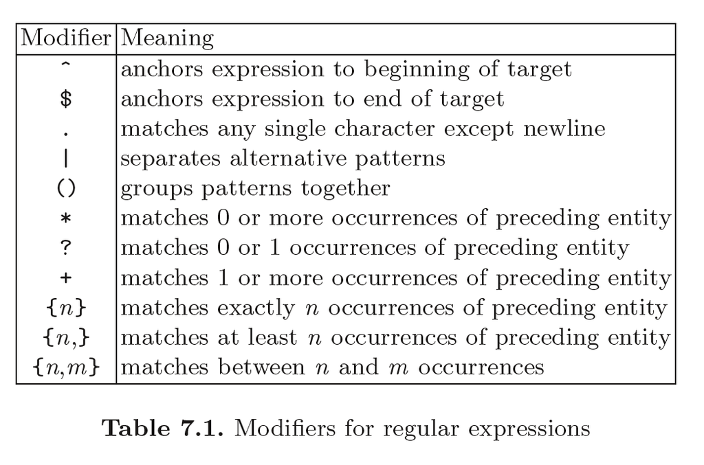

The `strsplit` function can use a character string or regular expression to divide up a character string into smaller pieces. The first argument to `strsplit` is the character string to break up, and the second argument is the character value or regular expression which should be used to break up the string into parts.Like other functions that can return different numbers of elements from their inputs, `strsplit` returns its results as a list, even when its input is a single character string. Because `strsplit` can accept regular expressions to decide where to split a character string, a wide variety of situations can be easily handled.

The `grep` function accepts a regular expression and a character string or vector of character strings, and returns the indices of those elements of the strings which are matched by the regular expression. If the `value=TRUE` argument is passed to grep, it will return the actual strings which matched the expression instead of the indices. If the string to be matched should be interpreted literally (i.e., not as a regular expression), the `fixed=TRUE` argument should be used. One important use of `grep` is to extract a set of variables from a data frame based on their names. To create a data frame with just these variables, we can use the output of `grep` as a subscript. To find regular expressions without regard to the case (upper or lower) of the input, the `ignore.case=TRUE` argument can be used.

Surrounding a string with escaped angle brackets (`\\< and \\>`) restricts matches to the case where the string is surrounded by either white space, punctuation, or a line ending or beginning. If the regular expression passed to grep is not matched in any of its inputs, `grep` returns an empty numeric vector. Thus, the any function can be used to test if a regular expression occurs anywhere in a vector of strings.

While the `grep` function can be used to test for the presence of a regular expression, sometimes more details regarding the matches that are found are needed. In R, the `regexpr` and `gregexpr` functions can be used to pinpoint and possibly extract those parts of a string that were matched by a regular expression. The output from these functions is a vector of starting positions of the regular expressions which were found; if no match occurred, a value of -1 is returned. In addition, an attribute called match.length is associated with the vector of starting positions to provide information about exactly which characters were involved in the match. The `regexpr` function will only provide information about the first match in its input string(s), while the `gregexpr` function returns information about all matches found. The input arguments to `regexpr` and `gregexpr` are similar to those of grep; however, the `ignore.case=TRUE` argument is not available in versions of R earlier than version 2.6.

Since `regexpr` only reports the first match it finds, it will always return a vector, with -1 in those positions where no match was found. To extract the strings that actually matched, `substr` can be used, after calculating the ending position from the `regexpr` output and the `match.length` attribute.

For substituting text based on regular expressions, R provides two functions: `sub` and `gsub.` Each of these functions accepts a regular expression, a string containing what will be substituted for the regular expression, and the string or strings to operate on. The `sub` function changes only the first occurrence of the regular expression, while the `gsub` function performs the substitution on all occurrences within the string. One important use of these functions concerns numeric data which is read from text sources like web pages or financial reports, and which may contain commas or dollar signs.

When using the substitution functions, a powerful feature known as tagging of regular expressions is available. When part of a regular expression is surrounded by (unescaped) parentheses, that part can be used in a substitution pattern by representing it as a backslash followed by a number. The first tagged pattern is represented by `\\1`, the second by `\\2`, and so on. To extract just the tagged pattern from a regular expression, one possibility is to use the regular expression beginning and end anchor characters (`^` and `$`, respectively) to account for all the nontagged characters in the string, and specify just the tagged expression for the substitution string.

If you wish to create a number of similar strings based on information from other variables, you can use `sprintf`, which allows you to write a string using `%s` as a placeholder for the values that should be pulled from other variables.

```r
# finding the lengths of the names of the states of USA
nchar(state.name)
```

```
##  [1]  7  6  7  8 10  8 11  8  7  7  6  5  8  7  4  6  8  9  5  8 13  8  9 11  8
## [26]  7  8  6 13 10 10  8 14 12  4  8  6 12 12 14 12  9  5  4  7  8 10 13  9  7
```

```r
# using cat function
x = 7
y = 10
cat("x should be greater than y, but x=',x,' and y=',y,' x should be greater than y, but x = 7 and y = 10")
```

```
## x should be greater than y, but x=',x,' and y=',y,' x should be greater than y, but x = 7 and y = 10
```

```r
# with fill argument
cat("Long strings can", "be displayed over", "several lines using", "the fill= argument", fill = 40)
```

```
## Long strings can be displayed over
## several lines using the fill= argument
```

```r
# using paste
paste("one", 2, "three", 4, "five")
```

```
## [1] "one 2 three 4 five"
```

```r
paste(c("one", "two", "three", "four"), collapse = " ")
```

```
## [1] "one two three four"
```

```r
paste(c("X", "Y"), 1:5, sep = "")
```

```
## [1] "X1" "Y2" "X3" "Y4" "X5"
```

```r
paste(c("X", "Y"), 1:5, sep = "_", collapse = "|")
```

```
## [1] "X_1|Y_2|X_3|Y_4|X_5"
```

```r
paste(c("X", "Y"), 1:5, sep = "_") # with space -> no collapse argument
```

```
## [1] "X_1" "Y_2" "X_3" "Y_4" "X_5"
```

```r
# working with parts of character values
substring(state.name, 2, 6)
```

```
##  [1] "labam" "laska" "rizon" "rkans" "alifo" "olora" "onnec" "elawa" "lorid"
## [10] "eorgi" "awaii" "daho"  "llino" "ndian" "owa"   "ansas" "entuc" "ouisi"
## [19] "aine"  "aryla" "assac" "ichig" "innes" "issis" "issou" "ontan" "ebras"
## [28] "evada" "ew Ha" "ew Je" "ew Me" "ew Yo" "orth " "orth " "hio"   "klaho"
## [37] "regon" "ennsy" "hode " "outh " "outh " "ennes" "exas"  "tah"   "ermon"
## [46] "irgin" "ashin" "est V" "iscon" "yomin"
```

```r
# finding location of particular characters
state <- "Mississippi"
ll <- nchar(state)
ltrs <- substring(state, 1:ll, 1:ll)
ltrs
```

```
##  [1] "M" "i" "s" "s" "i" "s" "s" "i" "p" "p" "i"
```

```r
which(ltrs == "s")
```

```
## [1] 3 4 6 7
```

```r
# regular expressions
expr <- ".*\\.txt"
nchar(expr)
```

```
## [1] 7
```

```r
cat(expr, "\n")
```

```
## .*\.txt
```

```r
# breaking apart character values
sentence <- "R is a free software environment for statistical computing"
parts <- strsplit(sentence, " ")
parts
```

```
## [[1]]
## [1] "R"           "is"          "a"           "free"        "software"
## [6] "environment" "for"         "statistical" "computing"
```

```r
length(parts)
```

```
## [1] 1
```

```r
length(parts[[1]])
```

```
## [1] 9
```

```r
sapply(parts, length)
```

```
## [1] 9
```

```r
allparts <- unlist(parts)
allparts
```

```
## [1] "R"           "is"          "a"           "free"        "software"
## [6] "environment" "for"         "statistical" "computing"
```

```r
str <- "one two three four"
strsplit(str, " +")
```

```
## [[1]]
## [1] "one"   "two"   "three" "four"
```

```r
# using regex
grep("^pop", names(LifeCycleSavings)) # indices
```

```
## [1] 2 3
```

```r
grep("^pop", names(LifeCycleSavings), value = TRUE) # values
```

```
## [1] "pop15" "pop75"
```

```r
# creating a data frame using grep as a subscript
head(LifeCycleSavings[, grep("^pop", names(LifeCycleSavings))])
```

```
##           pop15 pop75
## Australia 29.35  2.87
## Austria   23.32  4.41
## Belgium   23.80  4.43
## Bolivia   41.89  1.67
## Brazil    42.19  0.83
## Canada    31.72  2.85
```

```r
# ignoring upper or lower case
inp <- c("run dog run", "work doggedly", "CAT AND DOG")
grep("\\<dog\\>", inp, ignore.case = TRUE)
```

```
## [1] 1 3
```

```r
# checking if a regex occurs anywhere in text
str1 <- c("The R Foundation", "is a not for profit organization", "working in the public interest")
str2 <- c(" It was founded by the members", "of the R Core Team in order", "to provide support for the R project")
any(grep("profit", str1))
```

```
## [1] TRUE
```

```r
any(grep("profit", str2))
```

```
## [1] FALSE
```

```r
# using regexpr
tst <- c("one x7 two b1", "three c5 four b9", "five six seven", "a8 eight nine")
wh <- regexpr("[a-z][0-9]", tst)
wh
```

```
## [1]  5  7 -1  1
## attr(,"match.length")
## [1]  2  2 -1  2
## attr(,"index.type")
## [1] "chars"
## attr(,"useBytes")
## [1] TRUE
```

```r
res <- substring(tst, wh, wh + attr(wh, "match.length") - 1)
res
```

```
## [1] "x7" "c5" ""   "a8"
```

```r
# using gregexpr
wh1 <- gregexpr("[a-z][0-9]", tst)
wh1
```

```
## [[1]]
## [1]  5 12
## attr(,"match.length")
## [1] 2 2
## attr(,"index.type")
## [1] "chars"
## attr(,"useBytes")
## [1] TRUE
##
## [[2]]
## [1]  7 15
## attr(,"match.length")
## [1] 2 2
## attr(,"index.type")
## [1] "chars"
## attr(,"useBytes")
## [1] TRUE
##
## [[3]]
## [1] -1
## attr(,"match.length")
## [1] -1
## attr(,"index.type")
## [1] "chars"
## attr(,"useBytes")
## [1] TRUE
##
## [[4]]
## [1] 1
## attr(,"match.length")
## [1] 2
## attr(,"index.type")
## [1] "chars"
## attr(,"useBytes")
## [1] TRUE
```

```r
res1 = list()
for (i in 1:length(wh1)) {
  res1[[i]] <- substring(
    tst[i], wh1[[i]],
    wh1[[i]] +
      attr(wh1[[i]], "match.length") - 1
  )
}
res1
```

```
## [[1]]
## [1] "x7" "b1"
##
## [[2]]
## [1] "c5" "b9"
##
## [[3]]
## [1] ""
##
## [[4]]
## [1] "a8"
```

```r
# substitutions
values <- c("$11,317.35", "$11,234.51", "$11,275.89", "$11,278.93", "$11,294.94")
as.numeric(gsub("[$,]", "", values))
```

```
## [1] 11317.35 11234.51 11275.89 11278.93 11294.94
```

```r
# tagging
values <- c("75.99", "(20.30)", "55.20")
as.numeric(gsub("\\(([0-9.]+)\\)", "-\\1", values))
```

```
## [1]  75.99 -20.30  55.20
```

```r
# extracting the tagged pattern
str <- "report: 17 value=12 time=2:00"
sub("value=([^ ]+)", "\\1", str)
```

```
## [1] "report: 17 12 time=2:00"
```

```r
sub("^.*value=([^ ]+).*$", "\\1", str)
```

```
## [1] "12"
```

```r
# using variables into strings
names <- c("Irma", "Bea", "Lisa")
ages <- c(5, 59, 36)
sprintf("%s is %s years old.", names, ages)
```

```
## [1] "Irma is 5 years old."  "Bea is 59 years old."  "Lisa is 36 years old."
```

## 7.2 Tidyverse

Para trabajar con la manipulación de cadenas de texto usamos el paquete stringr, cuyas funciones siempre empiezan por `str_*`, seguidas por un verbo y el primer argumento, que siempre es un vector de caracteres. La mayoría de las funciones `str_*` usan expresiones regulares.

```r
# data
geo <- pull(emisiones, 1)
# how many characters has every element
head( str_length(geo), 10)
```

```
##  [1] 36 73  7  8 14  7 48  7  7  6
```

```r
# to lower
head (str_to_lower(geo), 10)
```

```
##  [1] "european union (current composition)"
##  [2] "european union (current composition) and iceland under the kyoto protocol"
##  [3] "belgium"
##  [4] "bulgaria"
##  [5] "czech republic"
##  [6] "denmark"
##  [7] "germany (until 1990 former territory of the frg)"
##  [8] "estonia"
##  [9] "ireland"
## [10] "greece"
```

```r
# joining characters
str_c (geo[26 : 35], collapse = ", ")
```

```
## [1] "Slovenia, Slovakia, Finland, Sweden, United Kingdom, Iceland, Liechtenstein, Norway, Switzerland, Turkey"
```

```r
str_c (geo[ 26 : 35], 1:10, sep = "_" )
```

```
##  [1] "Slovenia_1"       "Slovakia_2"       "Finland_3"        "Sweden_4"
##  [5] "United Kingdom_5" "Iceland_6"        "Liechtenstein_7"  "Norway_8"
##  [9] "Switzerland_9"    "Turkey_10"
```

```r
# extracting characters between two indices
str_sub(geo[ 26 : 35], 1, 3)
```

```
##  [1] "Slo" "Slo" "Fin" "Swe" "Uni" "Ice" "Lie" "Nor" "Swi" "Tur"
```

```r
# str_ and regex
str_subset(geo, "[p]")
```

```
## [1] "European Union (current composition)"
## [2] "European Union (current composition) and Iceland under the Kyoto Protocol"
## [3] "Czech Republic"
## [4] "Spain"
## [5] "Cyprus"
```

```r
str_subset(geo, "[pl]")
```

```
##  [1] "European Union (current composition)"
##  [2] "European Union (current composition) and Iceland under the Kyoto Protocol"
##  [3] "Belgium"
##  [4] "Bulgaria"
##  [5] "Czech Republic"
##  [6] "Germany (until 1990 former territory of the FRG)"
##  [7] "Ireland"
##  [8] "Spain"
##  [9] "Italy"
## [10] "Cyprus"
## [11] "Malta"
## [12] "Netherlands"
## [13] "Poland"
## [14] "Portugal"
## [15] "Slovenia"
## [16] "Slovakia"
## [17] "Finland"
## [18] "Iceland"
## [19] "Switzerland"
```

```r
str_subset(geo, "^E")
```

```
## [1] "European Union (current composition)"
## [2] "European Union (current composition) and Iceland under the Kyoto Protocol"
## [3] "Estonia"
```

```r
str_subset(geo, "E$")
```

```
## character(0)
```

```r
# counting
str_count(geo, "[ou]")
```

```
##  [1]  7 13  1  1  1  0  4  1  0  0  0  0  1  0  1  0  1  3  1  0  0  1  1  2  1
## [26]  1  1  0  0  1  0  0  1  0  1
```

```r
# detecting a pattern
str_detect(geo, "^L")
```

```
##  [1] FALSE FALSE FALSE FALSE FALSE FALSE FALSE FALSE FALSE FALSE FALSE FALSE
## [13] FALSE FALSE FALSE  TRUE  TRUE  TRUE FALSE FALSE FALSE FALSE FALSE FALSE
## [25] FALSE FALSE FALSE FALSE FALSE FALSE FALSE  TRUE FALSE FALSE FALSE
```

```r
# extracting a pattern
str_extract(geo, "Euro")
```

```
##  [1] "Euro" "Euro" NA     NA     NA     NA     NA     NA     NA     NA
## [11] NA     NA     NA     NA     NA     NA     NA     NA     NA     NA
## [21] NA     NA     NA     NA     NA     NA     NA     NA     NA     NA
## [31] NA     NA     NA     NA     NA
```

```r
str_extract(geo, "[euro]")
```

```
##  [1] "u" "u" "e" "u" "e" "e" "e" "o" "r" "r" NA  "r" "r" NA  "r" NA  "u" "u" "u"
## [20] NA  "e" "u" "o" "o" "o" "o" "o" NA  "e" "e" "e" "e" "o" "e" "u"
```

```r
# replacing characters
str_replace(geo, "\\(current composition\\)" , "")
```

```
##  [1] "European Union "
##  [2] "European Union  and Iceland under the Kyoto Protocol"
##  [3] "Belgium"
##  [4] "Bulgaria"
##  [5] "Czech Republic"
##  [6] "Denmark"
##  [7] "Germany (until 1990 former territory of the FRG)"
##  [8] "Estonia"
##  [9] "Ireland"
## [10] "Greece"
## [11] "Spain"
## [12] "France"
## [13] "Croatia"
## [14] "Italy"
## [15] "Cyprus"
```

[output cut: 20 more lines]

```r
geo2 <- str_c(geo[26 : 35], 1 :10, sep="_")
geo2
```

```
##  [1] "Slovenia_1"       "Slovakia_2"       "Finland_3"        "Sweden_4"
##  [5] "United Kingdom_5" "Iceland_6"        "Liechtenstein_7"  "Norway_8"
##  [9] "Switzerland_9"    "Turkey_10"
```

```r
str_replace(geo2, "_[0-9]{1,2}", "")
```

```
##  [1] "Slovenia"       "Slovakia"       "Finland"        "Sweden"
##  [5] "United Kingdom" "Iceland"        "Liechtenstein"  "Norway"
##  [9] "Switzerland"    "Turkey"
```

```r
# creating the format "leading zero"
str_pad(1:12, 2, "left", "0")
```

```
##  [1] "01" "02" "03" "04" "05" "06" "07" "08" "09" "10" "11" "12"
```

# 8 Factors and Levels

## 8.1 Base-R

Conceptually, factors are variables in R which take on a limited number of different values; such variables are often referred to as categorical variables. One of the most important uses of factors is in statistical modeling; since categorical variables enter into statistical models differently than continuous variables, storing data as factors insures that the modeling functions will treat such data correctly.

Factors in R are stored as a vector of integer values with a corresponding set of character values to use when the factor is displayed. The factor function is used to create a factor. The only required argument to factor is a vector of values which will be returned as a vector of factor values. Both numeric and character variables can be made into factors, but a factor’s levels will always be character values. You can see the possible levels for a factor by calling the `levels` function; the `nlevels` function will return the number of levels of a factor.

To change the order in which the levels will be displayed from their default sorted order, the `levels=` argument can be given a vector of all the possible values of the variable in the order you desire. If the ordering should also be used when performing comparisons, use the optional `ordered=TRUE` argument.In this case, the factor is known as an **ordered factor**.

The levels of a factor are used when displaying the factor’s values. You can change these levels at the time you create a factor by passing a vector with the new values through the `labels=` argument. Note that this actually changes the internal levels of the factor, and to change the labels of a factor after it has been created, the assignment form of the `levels` function is used.

Factors represent a very efficient way to store character values, because each unique character value is stored only once, and the data itself is stored as a vector of integers. Because of this, `read.table` will automatically convert character variables to factors unless the `as.is=TRUE` or `stringsAsFactors=FALSE` arguments are specified, or the `stringsAsFactors` system option is set to `FALSE`. Comparison operators are not supported for unordered factors. The order in which the levels are displayed is determined by the order in which they appear in the `levels=` argument to factor. Sometimes, a factor needs to be reordered on the basis of some property of that factor. The `reorder` function takes three arguments: a factor, a vector of values on which the reordering is based, and a function to operate on those values for each factor level. When reorder is used, it assigns an attribute called `scores` which contains the value used for the reordering.

For some statistical procedures, the interpretation of results can be simplified by forcing a particular order to a factor; in particular, it may be useful to choose a “reference” level, which should be the first level of the factor. The `relevel` function allows you to choose a reference level, which will then be treated as the first level of the factor.

While it may be necessary to convert a numeric variable to a factor for a particular application, it is often very useful to convert the factor back to its original numeric values, since even simple arithmetic operations will fail when using factors. Since the `as.numeric` function will simply return the internal integer values of the factor, the conversion must be done using the levels attribute of the factor, or by first converting the factor to a character value using `as.character`.

When a factor is first created, all of its levels are stored along with the factor, and if subsets of the factor are extracted, they will retain all of the original levels. This can create problems when constructing model matrices and may or may not be useful when displaying the data using, say, the `table` function. To change this, we can use the `drop=TRUE` argument to the subscripting operator. When used with factors, this argument will remove the unused levels.

To exclude certain levels from appearing in a factor, the `exclude=` argument can be passed to factor. By default, the missing value (`NA`) is excluded from factor levels; to create a factor that includes missing values from a numeric variable, use `exclude=NULL`.

Care must be taken when combining variables which are factors, because the `c` function will interpret the factors as integers. To combine factors, they should first be converted back to their original values (through the `levels` function), then concatenated and converted to a new factor.

The `cut` function is used to convert a numeric variable into a factor. The `breaks=` argument to cut is used to describe how ranges of numbers will be converted to factor values. If a number is provided through the `breaks=` argument, the resulting factor will be created by dividing the range of the variable into that number of equal-length intervals; if a vector of values is provided, the values in the vector are used to determine the breakpoints. Note that if a vector of values is provided, the number of levels of the resultant factor will be one less than the number of values in the vector. Notice that the default label for factors produced by cut contains the actual range of values that were used to divide the variable into factors. The `pretty` function can be used to choose cut points that are round numbers, but it may not return the number of levels that’s actually desired. The `labels=` argument to cut allows you to specify the levels of the factors. To produce factors based on percentiles of your data (for example, quartiles or deciles), the `quantile` function can be used to generate the `breaks=` argument, insuring nearly equal numbers of observations in each of the levels of the factor.

If you wish to create a factor based on one of the components of that date, you can extract it with `strftime` and convert it to a factor directly. Sometimes more flexibility can be achieved by using the cut function, which understands time units of months, days, weeks, and years through the `breaks=` argument. (For date/time values, units of hours, minutes, and seconds can also be used.). By default, cut starts weeks on Mondays; to use Sundays instead, pass the `start.on.monday=FALSE` argument to cut. Multiples of units can also be specified through the `breaks=` argument.

Sometimes it is useful to treat all combinations of several factors as if they were a single factor. In situations like these, the `interaction` function can be used. This function will take two or more factors, and create a new, unordered factor whose levels correspond to the combinations of the levels of the input factors. interaction’s default behavior is to include all possible combinations of its input factors. To retain only those combinations for which there were observations, the `drop=TRUE` argument can be passed to interaction. By default, `interaction` forms levels for the new factor by joining the levels of its component factors with a period (`.`). This can be overridden with the `sep=` argument.

```r
data <- c(1, 2, 2, 3, 1, 2, 3, 3, 1, 2, 3, 3, 1)
fdata <- factor(data)
fdata
```

```
##  [1] 1 2 2 3 1 2 3 3 1 2 3 3 1
## Levels: 1 2 3
```

```r
# modifying levels in factors
rdata <- factor(data, labels = c("I", "II", "III"))
rdata
```

```
##  [1] I   II  II  III I   II  III III I   II  III III I
## Levels: I II III
```

```r
levels(fdata) <- c("I", "II", "III")
fdata
```

```
##  [1] I   II  II  III I   II  III III I   II  III III I
## Levels: I II III
```

```r
# unordered factor
mons <- c("March", "April", "January", "November", "January", "September", "October", "September", "November", "August", "January", "November", "November", "February", "May", "August", "July", "December", "August", "August", "September", "November", "February", "April")
mons <- factor(mons)
table(mons)
```

```
## mons
##     April    August  December  February   January      July     March       May
##         2         4         1         2         3         1         1         1
##  November   October September
##         5         1         3
```

```r
# ordered factor
mons <- factor(mons, levels = c("January", "February", "March", "April", "May", "June", "July", "August", "September", "October", "November", "December"), ordered = TRUE)
mons[1] < mons[2]
```

```
## [1] TRUE
```

```r
table(mons)
```

```
## mons
##   January  February     March     April       May      June      July    August
##         3         2         1         2         1         0         1         4
## September   October  November  December
##         3         1         5         1
```

```r
# reordering levels
levels(InsectSprays$spray)
```

```
## [1] "A" "B" "C" "D" "E" "F"
```

```r
InsectSprays$spray <- with(InsectSprays, reorder(spray, count, mean))
levels(InsectSprays$spray)
```

```
## [1] "C" "E" "D" "A" "B" "F"
```

```r
attr(InsectSprays$spray, "scores")
```

```
##         A         B         C         D         E         F
## 14.500000 15.333333  2.083333  4.916667  3.500000 16.666667
```

```r
# forcing a particular order to a factor with relevel
levels(InsectSprays$spray)
```

```
## [1] "C" "E" "D" "A" "B" "F"
```

```r
InsectSprays$spray <- relevel(InsectSprays$spray, "A")
levels(InsectSprays$spray)
```

```
## [1] "A" "C" "E" "D" "B" "F"
```

```r
# converting factors to numeric
fert <- c(10, 20, 20, 50, 10, 20, 10, 50, 20)
fert <- factor(fert, levels = c(10, 20, 50), ordered = TRUE)
fert
```

```
## [1] 10 20 20 50 10 20 10 50 20
## Levels: 10 < 20 < 50
```

```r
mean(as.numeric(levels(fert)[fert]))
```

```
## [1] 23.33333
```

```r
mean(as.numeric(as.character(fert)))
```

```
## [1] 23.33333
```

```r
# dropping unused levels
lets <- sample(letters, size = 100, replace = TRUE)
lets <- factor(lets)
table(lets[1:5])
```

```
##
## a b c d e f g h i j k l m n o p q r s t u v w x y z
## 0 0 2 0 1 1 0 0 1 0 0 0 0 0 0 0 0 0 0 0 0 0 0 0 0 0
```

```r
table(lets[1:5, drop = TRUE])
```

```
##
## c e f i
## 2 1 1 1
```

```r
# or
table(factor(lets[1:5]))
```

```
##
## c e f i
## 2 1 1 1
```

```r
# combining factors
fact1 <- factor(sample(letters, size = 10, replace = TRUE))
fact2 <- factor(sample(letters, size = 10, replace = TRUE))
fact12 <- factor(c(levels(fact1)[fact1], levels(fact2)[fact2]))
fact12
```

```
##  [1] s w g t r p e d w x i n i e b u l s g g
## Levels: b d e g i l n p r s t u w x
```

```r
# creating factors from continuous variables
wfact <- cut(women$weight, 3)
table(wfact)
```

```
## wfact
## (115,131] (131,148] (148,164]
##         6         5         4
```

```r
wfact <- cut(women$weight, pretty(women$weight, 3))
wfact
```

```
##  [1] (100,120] (100,120] (100,120] (120,140] (120,140] (120,140] (120,140]
##  [8] (120,140] (120,140] (140,160] (140,160] (140,160] (140,160] (140,160]
## [15] (160,180]
## Levels: (100,120] (120,140] (140,160] (160,180]
```

```r
wfact <- cut(women$weight, 3, labels = c("Low", "Medium", "High"))
table(wfact)
```

```
## wfact
##    Low Medium   High
##      6      5      4
```

```r
wfact <- cut(women$weight, quantile(women$weight, (0:4) / 4))
table(wfact)
```

```
## wfact
## (115,124] (124,135] (135,148] (148,164]
##         3         4         3         4
```

```r
# creating factors based on dates and times
everyday <- seq(from = as.Date("2005-1-1"), to = as.Date("2005-12-31"), by = "day")
cmonth <- format(everyday, "%b")
months <- factor(cmonth, levels = unique(cmonth), ordered = TRUE)
table(months)
```

```
## months
## Jan Feb Mar Apr May Jun Jul Aug Sep Oct Nov Dec
##  31  28  31  30  31  30  31  31  30  31  30  31
```

```r
# with cut
wks <- cut(everyday, breaks = "week")
head(wks)
```

```
## [1] 2004-12-27 2004-12-27 2005-01-03 2005-01-03 2005-01-03 2005-01-03
## 53 Levels: 2004-12-27 2005-01-03 2005-01-10 2005-01-17 ... 2005-12-26
```

```r
qtrs <- cut(everyday, "3 months", labels = paste("Q", 1:4, sep = ""))
head(qtrs)
```

```
## [1] Q1 Q1 Q1 Q1 Q1 Q1
## Levels: Q1 Q2 Q3 Q4
```

```r
# interactions
nlevels(CO2$Plant)
```

```
## [1] 12
```

```r
nlevels(CO2$Type)
```

```
## [1] 2
```

```r
newfact <- interaction(CO2$Plant, CO2$Type)
nlevels(newfact)
```

```
## [1] 24
```

```r
newfact1 <- interaction(CO2$Plant, CO2$Type, drop = TRUE, sep = "_")
nlevels(newfact1)
```

```
## [1] 12
```

```r
levels(newfact1)
```

```
##  [1] "Qn1_Quebec"      "Qn2_Quebec"      "Qn3_Quebec"      "Qc1_Quebec"
##  [5] "Qc3_Quebec"      "Qc2_Quebec"      "Mn3_Mississippi" "Mn2_Mississippi"
##  [9] "Mn1_Mississippi" "Mc2_Mississippi" "Mc3_Mississippi" "Mc1_Mississippi"
```

```r
# converting multiple numeric variables to factor (no data)
# cols <- c(35:74)
# df.j[, cols] <- lapply(df.j[, cols], factor)

# assigning levels to factor variables (no data)
# btw2009 <- within (btw2009, levels(stateA) <- c("BW", "BY", "BE","BB", "HB", "HH", "HE", "MV", "NI", "NW","RP", "SL", "SN", "ST", "SH", "TH"))

# re-ordering levels and assigning to a new factor variable
# ls <- with(btw9s, Bundesland[order(EW, -Voters)]) # reorder levels and supress one var
# btw9s <- within(btw9s, State1 <- factor(Bundesland, levels=ls)) # create a new factor var and assign levels

# re-assigning ordered levels to variables in a data frame
levels(Arthritis$Improved)
```

```
## [1] "None"   "Some"   "Marked"
```

```r
Arthritis$Improved <- ordered(Arthritis$Improved, levels = c("None", "Some", "Marked"))
# or
# exp1_long$condition <- factor(exp1_long$condition, levels = c("No_communication", "High_confidence", "Medium_confidence", "Low_confidence"))

# in table form there are occasions when you need numeric values for the levels of ordered factors in a table (no data)
# Simply re-assign the dimnames attribute of the table variables
# dimnames(JobSat)$income <- c(7.5, 20, 32.5, 60)
# dimnames(JobSat)$satisfaction <- 1:4

# You want to preserve the character labels of table dimensions, but also
# allow them to be sorted in some particular order
# dimnames(JobSat)$income <- paste(1:4, dimnames(JobSat)$income, sep = ":")
# dimnames(JobSat)$satisfaction <- paste(1:4, dimnames(JobSat)$satisfaction, sep = ":")
```

## 8.2 Tidyverse

Factor variables are very useful but not very easy to manipulate. **forcats** contains very useful functions that make working on factor variables painless. The four following functions, `fct_recode()`, `fct_relevel()`, `fct_reorder()` and `fct_relabel()`, are the ones you must know. `fct_reorder()` is especially useful for plotting. `fct_lump*()` functions make it possible to lump several levels of a factor into a new other level.

```r
head(gss_cat)
```

```
## # A tibble: 6 × 9
##    year marital         age race  rincome        partyid     relig denom tvhours
##   <int> <fct>         <int> <fct> <fct>          <fct>       <fct> <fct>   <int>
## 1  2000 Never married    26 White $8000 to 9999  Ind,near r… Prot… Sout…      12
## 2  2000 Divorced         48 White $8000 to 9999  Not str re… Prot… Bapt…      NA
## 3  2000 Widowed          67 White Not applicable Independent Prot… No d…       2
## 4  2000 Never married    39 White Not applicable Ind,near r… Orth… Not …       4
## 5  2000 Divorced         25 White Not applicable Not str de… None  Not …       1
## 6  2000 Married          25 White $20000 - 24999 Strong dem… Prot… Sout…      NA
```

```r
str(gss_cat$marital)
```

```
##  Factor w/ 6 levels "No answer","Never married",..: 2 4 5 2 4 6 2 4 6 6 ...
```

```r
str(gss_cat$rincome)
```

```
##  Factor w/ 16 levels "No answer","Don't know",..: 8 8 16 16 16 5 4 9 4 4 ...
```

```r
# recoding levels
gss_cat <- gss_cat %>%
  mutate(marital = fct_recode(marital,
    refuse = "No answer",
    never_married = "Never married",
    divorced = "Separated",
    divorced = "Divorced",
    widowed = "Widowed",
    married = "Married"
  ))

gss_cat %>%
  janitor::tabyl(marital)
```

```
##        marital     n      percent
##         refuse    17 0.0007913234
##  never_married  5416 0.2521063166
##       divorced  4126 0.1920588372
##        widowed  1807 0.0841130196
##        married 10117 0.4709305032
```

```r
# lumping categories
gss_cat <- gss_cat %>%
  mutate(marital = fct_lump(marital, prop = 0.10, other_level = "other"))

gss_cat %>%
  mutate(
    # Description of the different functions taken from help(fct_lump)
    denom_lowfreq = fct_lump_lowfreq(denom), # lumps together the least frequent levels, ensuring that "other" is still the smallest level.
    denom_min = fct_lump_min(denom, min = 10), # lumps levels that appear fewer than min times.
    denom_n = fct_lump_n(denom, n = 3), # lumps all levels except for the n most frequent (or least frequent if n < 0)
    denom_prop = fct_lump_prop(denom, prop = 0.10) # lumps levels that appear in fewer prop * n times.
  )
```

```
## # A tibble: 21,483 × 13
##     year marital   age race  rincome partyid relig denom tvhours denom…¹ denom…²
##    <int> <fct>   <int> <fct> <fct>   <fct>   <fct> <fct>   <int> <fct>   <fct>
##  1  2000 never_…    26 White $8000 … Ind,ne… Prot… Sout…      12 Southe… Southe…
##  2  2000 divorc…    48 White $8000 … Not st… Prot… Bapt…      NA Baptis… Baptis…
##  3  2000 other      67 White Not ap… Indepe… Prot… No d…       2 No den… No den…
##  4  2000 never_…    39 White Not ap… Ind,ne… Orth… Not …       4 Not ap… Not ap…
##  5  2000 divorc…    25 White Not ap… Not st… None  Not …       1 Not ap… Not ap…
##  6  2000 married    25 White $20000… Strong… Prot… Sout…      NA Southe… Southe…
##  7  2000 never_…    36 White $25000… Not st… Chri… Not …       3 Not ap… Not ap…
##  8  2000 divorc…    44 White $7000 … Ind,ne… Prot… Luth…      NA Luther… Luther…
##  9  2000 married    44 White $25000… Not st… Prot… Other       0 Other   Other
## 10  2000 married    47 White $25000… Strong… Prot… Sout…       3 Southe… Southe…
## # … with 21,473 more rows, 2 more variables: denom_n <fct>, denom_prop <fct>,
## #   and abbreviated variable names ¹denom_lowfreq, ²denom_min
## # ℹ Use `print(n = ...)` to see more rows, and `colnames()` to see all variable names
```

```r
gss_cat %>%
  tabyl(marital)
```

```
##        marital     n    percent
##  never_married  5416 0.25210632
##       divorced  4126 0.19205884
##        married 10117 0.47093050
##          other  1824 0.08490434
```

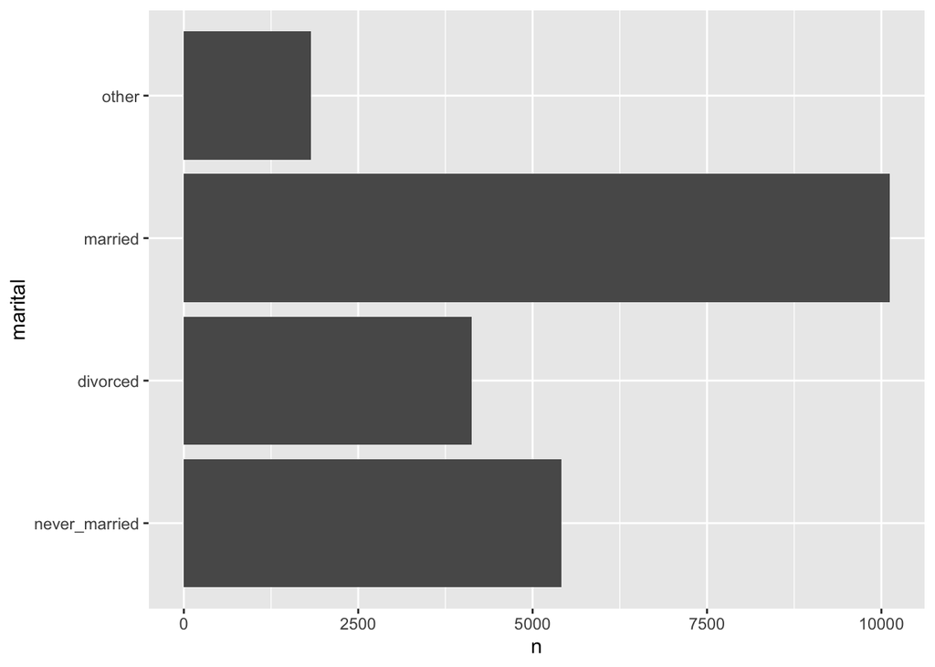

```r
# using fct_reorder()
gss_cat %>%
  tabyl(marital) %>%
  ggplot() +
  geom_col(aes(y = n, x = marital)) +
  coord_flip()
```

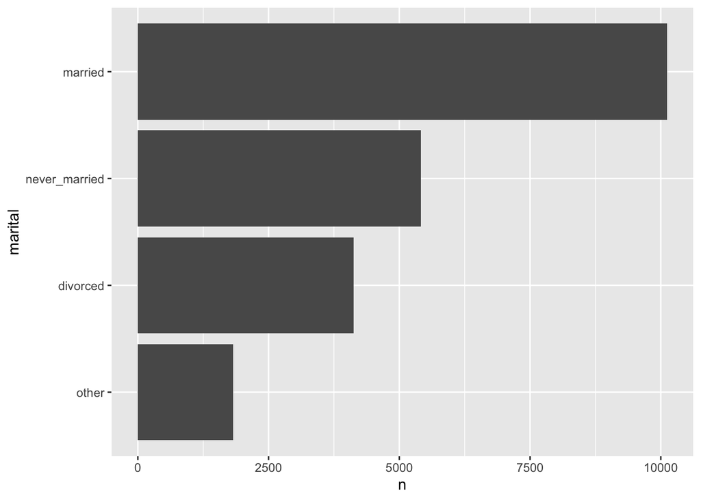

```r
gss_cat %>%
  tabyl(marital) %>%
  mutate(marital = fct_reorder(marital, n, .desc = FALSE)) %>%
  ggplot() +
  geom_col(aes(y = n, x = marital)) +
  coord_flip()
```

# 9 Dates and Times

## 9.1 Base-R

R provides several options for dealing with date and date/time data. The builtin `as.Date` function handles dates (without times); the contributed package `chron` handles dates and times, but does not control for time zones; and the `POSIXct` and `POSIXlt` classes allow for dates and times with control for time zones. The general rule for date/time data in R is to use the simplest technique possible. Thus, for date only data, `as.Date` will usually be the best choice. If you need to handle dates and times, without time-zone information, the `chron` package is a good choice; the `POSIX` classes are especially useful when time-zone manipulation is important. Also, don’t overlook the various “as.” functions (like `as.Date` and `as.POSIXlt`) for converting among the different date types when necessary. Except for the `POSIXlt` class, dates are stored internally as the number of days or seconds from some reference date. Thus, dates in R will generally have a numeric mode, and the class function can be used to find the way they are actually being stored. The `POSIXlt` class stores date/time values as a list of components (hour, min, sec, mon, etc.) making it easy to extract these parts. To get the current date, the `Sys.Date` function will return a Date object which can be converted to a different class if necessary.

The `as.Date` function allows a variety of input formats through the `format=` argument. The default format is a four-digit year, followed by a month, then a day, separated by either dashes or slashes. If your input dates are not in the standard format, a format string can be composed using the elements shown in the following table.

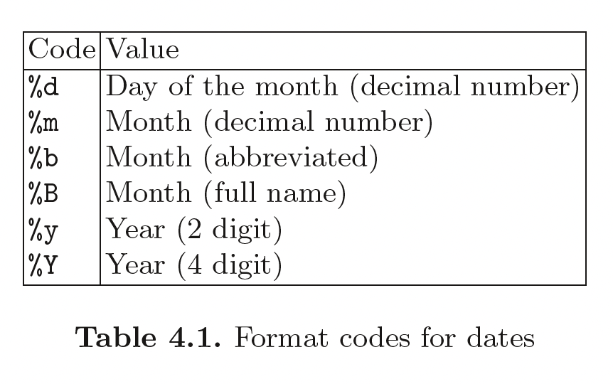

Internally, Date objects are stored as the number of days since **January 1, 1970**, using negative numbers for earlier dates. The `as.numeric` function can be used to convert a Date object to its internal form. To convert this form back to a Date object, it can be assigned a class of Date directly. To extract the components of the `dates`, the `weekdays`, `months`, `days`, or `quarters` functions can be used.

The `chron` function converts dates and times to chron objects. The dates and times are provided to the `chron` function as separate values, so some preprocessing may be necessary to prepare input date/times for the `chron` function. When using character values, the default format for dates is the decimal month value followed by the decimal day value followed by the year, using the slash as a separator. Alternatively, dates can be specified by a numeric value, representing the number of days since January 1, 1970. To input dates stored as the day of the year, the `origin=` argument can be used to interpret numeric dates relative to a different date. The default format for times consists of the hour, minutes, and seconds, separated by colons. Often the first task when using the `chron` package is to break apart the date and times if they are stored together. Chron values are stored internally as the fractional number of days from January 1, 1970. The `as.numeric` function can be used to access the internal values.

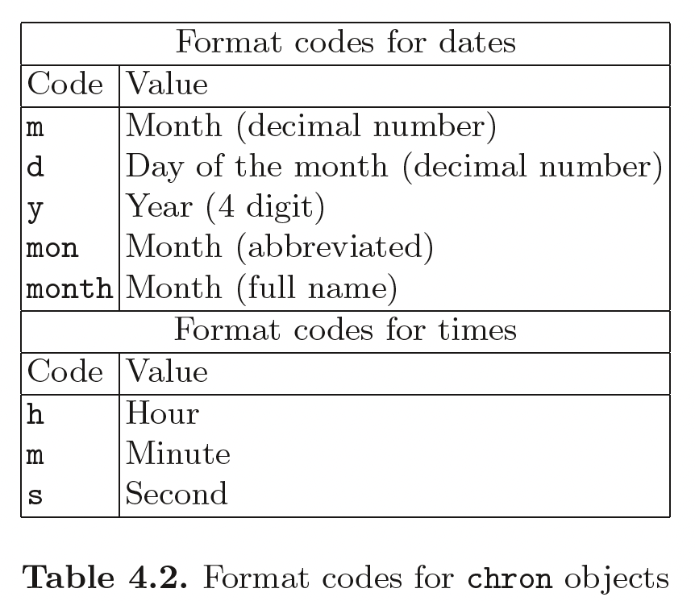

`POSIX` represents a portable operating system interface, primarily for UNIX systems, but available on other operating systems as well. Dates stored in the `POSIX` format are date/time values (like dates with the `chron` package), but also allow modification of time zones. Unlike the `chron` package, which stores times as fractions of days, the `POSIX` date classes store times to the nearest second, so they provide a more accurate representation of times. There are two `POSIX` `date/time` classes, which differ in the way that the values are stored internally. The `POSIXct` class stores date/time values as the number of seconds since January 1, 1970, while the `POSIXlt` class stores them as a list with elements for second, minute, hour, day, month, and year, among others. Unless you need the list nature of the `POSIXlt` class, the `POSIXct` class is the usual choice for storing dates in R. The default input format for `POSIX` dates consists of the year, followed by the month and day, separated by slashes or dashes; for date/time values, the date may be followed by white space and a time in the form hour:minutes:seconds or hour:minutes. Valid POSIX date or date/time inputs:

- 1915/6/16
- 2005-06-24 11:25
- 1990/2/17 12:20:05

If your input date/times are stored as the number of seconds from January 1, 1970, you can create `POSIX` date values by assigning the appropriate class directly to those values. Since many date manipulation functions refer to the `POSIXt` pseudo-class, be sure to include it in the class attribute of the values.